# log_analysis_with_MI_smcfcs

2023-03-29

# Data Import & Cleaning

## Import data

```r
raw_psych_hum_subj <- import("data/raw/raw_psych_hum_subj.csv")
raw_mktg_hum_subj <- import("data/raw/raw_mktg_hum_subj.csv")
raw_gen_uo_pop <- import("data/raw/raw_gen_uo_pop.csv")
pre_fall22 <- import("data/prescreen/dittersdorf_matches_f22.csv")
pre_winter23 <- import("data/prescreen/dittersdorf_matches_w23.csv")
pre_spring23 <- import("data/prescreen/dittersdorf_matches_s23.csv")
participant_list <- import("data/prescreen/dittersdorf_participants.csv")
```

Fix age before converting variable types

```r
table(raw_psych_hum_subj$Age) # 18 years old = 18
```

```
##
##                        18 18 years old           19           20           21
##          117          220            1          297          120           76
##           22           23           24           25           27           28
##           41            4            3            2            1            1
##           29           30           31           32           33           50
##            1            1            1            1            1            1
```

```r
table(raw_mktg_hum_subj$Age) # 1999 = 24
```

```
##
##        18   19 1999   20   21   22   23   24   25   28 test
##   11    4   13    1   50  119   66    7    9    3    1    3
```

```r
table(raw_gen_uo_pop$Age)
```

```
##
## 18 20 21 22 28
##  2  1  2  1  1
```

```r
raw_psych_hum_subj$Age[raw_psych_hum_subj$Age == "18 years old"] <- 18
raw_mktg_hum_subj$Age[raw_mktg_hum_subj$Age == 1999] <- 24

table(raw_psych_hum_subj$Age) # 18 years old = 18
```

```
##
##      18  19  20  21  22  23  24  25  27  28  29  30  31  32  33  50
## 117 221 297 120  76  41   4   3   2   1   1   1   1   1   1   1   1
```

```r
table(raw_mktg_hum_subj$Age) # 1999 = 24
```

```
##
##        18   19   20   21   22   23   24   25   28 test
##   11    4   13   50  119   66    7   10    3    1    3
```

## Combine dataframes

```r
raw_psych_hum_subj <- raw_psych_hum_subj %>%
  mutate(Age = as.integer(Age),
         Gender = as.factor(Gender),
         framing_condition_DO = as.factor(framing_condition_DO),
         norm_condition_DO = as.factor(norm_condition_DO),
         consumer_behaviors = as.factor(consumer_behaviors),
         skepticism = as.factor(skepticism),
         id = as.factor(id),
         source = strrep("psych_hsp", times = 1))

levels(raw_psych_hum_subj$framing_condition_DO)
```

```
## [1] ""                 "control_framing"  "pro_env_framing"  "self_enh_framing"
```

```r
raw_mktg_hum_subj <- raw_mktg_hum_subj %>%
  mutate(Age = as.integer(Age),
         Gender = as.factor(Gender),
         Gender_5_TEXT = as.character(Gender_5_TEXT),
         Class_Lvl_7_TEXT = as.character(Class_Lvl_7_TEXT),
         Pol_Ornt_8_TEXT = as.character(Pol_Ornt_8_TEXT),
         Ethnicity_8_TEXT = as.character(Ethnicity_8_TEXT),
         skept_open = as.character(skept_open),
         skepticism = as.factor(skepticism),
         id = as.factor(id),
         framing_condition_DO = as.factor(framing_condition_DO),
         norm_condition_DO = as.factor(norm_condition_DO),
         consumer_behaviors = as.factor(consumer_behaviors),
         source = strrep("mktg_hsp", times = 1))

raw_gen_uo_pop <- raw_gen_uo_pop %>%
  mutate(Gender = as.factor(Gender),
         Gender_5_TEXT = as.character(Gender_5_TEXT),
         Class_Lvl_7_TEXT = as.character(Class_Lvl_7_TEXT),
         Pol_Ornt_8_TEXT = as.character(Pol_Ornt_8_TEXT),
         skept_open = as.character(skept_open),
         skepticism = as.factor(skepticism),
         id = as.factor(id),
         framing_condition_DO = as.factor(framing_condition_DO),
         norm_condition_DO = as.factor(norm_condition_DO),
         consumer_behaviors = as.factor(consumer_behaviors),
         source = strrep("gen_UO", times = 1))
```

Specify unique variables to combine prescreen data sets

```r
# Create unique full_name variable
pre_fall22$full_name <- paste(pre_fall22$first_name, pre_fall22$last_name, sep="_")

pre_winter23$full_name <- paste(pre_winter23$first_name, pre_winter23$last_name, sep="_")

pre_spring23$full_name <- paste(pre_spring23$first_name, pre_spring23$last_name, sep="_")

participant_list$full_name <- paste(participant_list$first_name, participant_list$last_name, sep="_")

# Create column indicating which data set rows came from

pre_fall22 <- pre_fall22 %>%
  mutate(term = "fall22")

pre_winter23 <- pre_winter23 %>%
  mutate(term = "winter23")

pre_spring23 <- pre_spring23 %>%
  mutate(term = "spring23")
```

Combine prescreen data

```r
combine1 <- smartbind(pre_fall22, pre_winter23)
combined_prescreen <- smartbind(combine1, pre_spring23)

# nrow(pre_fall22) + nrow(pre_winter23) + nrow(pre_spring23) # n = 1167

combined_prescreen_unique <- combined_prescreen[!duplicated(combined_prescreen$full_name), ] # keeps first row (fall22)
```

Subset key variables

```r
combined_prescreen_key <- combined_prescreen_unique %>%
  dplyr::select(full_name, term, respecting:gratification, honest:gossip)

participant_list_key <- participant_list %>%
  dplyr::select(full_name, survey_id)
```

Merge with participant list

```r
merged_prescreen <- merge(combined_prescreen_key, participant_list_key, by = "full_name")
```

Rename SDR items to match

Convert variable types

```r
merged_prescreen <- merged_prescreen %>%
  mutate(respecting = as.integer(respecting),
         unity = as.integer(unity),
         protecting = as.integer(protecting),
         preventing = as.integer(preventing),
         equality = as.integer(equality),
         peace = as.integer(peace),
         justice = as.integer(justice),
         helpful = as.integer(helpful),
         power = as.integer(power),
         wealth = as.integer(wealth),
         authority = as.integer(authority),
         influential = as.integer(influential),
         ambition = as.integer(ambition),
         pleasures = as.integer(pleasures),
         enjoying = as.integer(enjoying),
         gratification = as.integer(gratification),
         honest = as.integer(honest),
         like = as.integer(like),
         disturbing = as.integer(disturbing),
         regret = as.integer(regret),
         lose_out = as.integer(lose_out),
         rational = as.integer(rational),
         confident = as.integer(confident),
         lover = as.integer(lover),
         lies = as.integer(lies),
         cover_up = as.integer(cover_up),
         advantage = as.integer(advantage),
         get_even = as.integer(get_even),
         behind_back = as.integer(behind_back),
         private_talk = as.integer(private_talk),
         take_things = as.integer(take_things),
         gossip = as.integer(gossip),
         id = as.factor(id))
```

Combine all data

- First, combine Psych Hum Subj data with Prescreen data based on `id`
- Second, add Mktg Hum Subj data
- Third, add gen UO Pop data

```r
combine1 <- merge(raw_psych_hum_subj, merged_prescreen, by = "id")
combine2 <- smartbind(combine1, raw_mktg_hum_subj)
combine3 <- smartbind(combine2, raw_gen_uo_pop)
```

## Remove duplicate cases

Identify duplicate cases

```r
# first, add unique row #s
combine3 <- combine3 %>%
  mutate(row = 1:nrow(combine3))

combine3[duplicated(combine3$id),] # Only rows 1 through 858 have unique id #s

# write.csv(combine3, "combined_data.csv")
```

Row IDs to remove:

- 13 (participant’s second time completing study)
- 134 (participant didn’t complete study first time)
- 145 (participant didn’t complete study first time)
- 308 (participant’s second time completing study)
- 672 (participant’s second time completing study)
- 743 (participant didn’t complete study first time)
- 790 (participant didn’t complete study first time)
- 800 (participant didn’t complete study first time)

Remove duplicate rows after resolving:

```r
combine3 <- combine3 %>%
  filter(!row %in% c(13, 134, 145, 308, 672, 743, 790, 800))
```

## Remove rows of all NAs

Identify completely missing rows:

```r
key_vars <- combine3 %>%
  dplyr::select(row, big_2_1:big_2_65, consumer_intentions_1:consumer_intentions_9, consumer_behaviors, clothing_interest_1:clothing_interest_20, ingroup_ident_1:ingroup_ident_14, values_1:values_16, socially_desirable_1:socially_desirable_16, source)

ncol(key_vars) # number of columns - the row # & source column = 141

all_NA_rows <- key_vars[rowSums(is.na(key_vars)) == 141,] # identify rows with 141 NAs (all missing values), row numbers are preserved

all_NA_rows
```

Removing rows of fully missing data

```r
data <- combine3 %>%
  dplyr::filter(!row %in% c(859, 860, 900, 926, 927, 941, 1139, 1141, 1142, 1143, 1144, 1146, 1149, 1150, 1152)) %>% # remove rows containing all NAs
  dplyr::select(-StartDate, -EndDate, -Status, -Progress, -"Duration (in seconds)", -Finished, -RecordedDate, -ResponseId, -DistributionChannel, -UserLanguage, -big_2_DO, -consumer_intentions_DO, -consumer_behaviors_DO, -clothing_interest_DO, -ingroup_ident_DO, -full_name, -code, -socially_desirable_DO, -values_DO, -email_giftcard, -term) # removing variables not in analysis
```

## Number per source

```r
table(data$source)
```

```
##
##    gen_UO  mktg_hsp psych_hsp
##         7       276       850
```

- 850 = psych human subjects pool
- 276 = mktg human subjects pool
- 7 = general UO pop

Rename variables

```r
data <- data %>%
  rename("framing_condition" = "framing_condition_DO",
         "norm_condition" = "norm_condition_DO")
```

Drop unused levels

Re-order levels of norm condition

```r
data$norm_condition <- factor(data$norm_condition, levels = c("control_norm", "descriptive_norm", "convention_norm", "social_norm", "moral_norm"))
```

## Inspect final data

```r
str(data, list.len = ncol(data))

# write.csv(data, "final_data.csv")
```

# Aggregate Variables

## Personality

### Reverse-code

```r
data_R <- data %>%
  mutate(across(c(big_2_11,
                  big_2_16,
                  big_2_26,
                  big_2_31,
                  big_2_36,
                  big_2_51,
                  big_2_12,
                  big_2_17,
                  big_2_22,
                  big_2_37,
                  big_2_42,
                  big_2_47,
                  big_2_3,
                  big_2_8,
                  big_2_23,
                  big_2_28,
                  big_2_48,
                  big_2_58,
                  big_2_4,
                  big_2_9,
                  big_2_24,
                  big_2_29,
                  big_2_44,
                  big_2_49,
                  big_2_5,
                  big_2_25,
                  big_2_30,
                  big_2_45,
                  big_2_50,
                  big_2_55,
                  big_2_63), ~6 - .)) # replace '6' with the max possible value plus 1 for any particular scale
```

### Average items

```r
data_R$extraversion <- data_R %>%
  dplyr::select(big_2_1, big_2_6, big_2_11, big_2_16, big_2_21, big_2_26, big_2_31, big_2_36, big_2_41, big_2_46, big_2_51, big_2_56) %>%
  rowMeans(na.rm = TRUE)


data_R$conscientiousness <- data_R %>%
  dplyr::select(big_2_3, big_2_8, big_2_13, big_2_18, big_2_23, big_2_28, big_2_33, big_2_38, big_2_43, big_2_48, big_2_53, big_2_58) %>%
  rowMeans(na.rm = TRUE)


data_R$agreeableness <- data_R %>%
  dplyr::select(big_2_2, big_2_7, big_2_12, big_2_17, big_2_22, big_2_27, big_2_32, big_2_37, big_2_42, big_2_47, big_2_52, big_2_57) %>%
  rowMeans(na.rm = TRUE)


data_R$neuroticism <- data_R %>%
  dplyr::select(big_2_4, big_2_9, big_2_14, big_2_19, big_2_24, big_2_29, big_2_34, big_2_39, big_2_44, big_2_49, big_2_54, big_2_59) %>%
  rowMeans(na.rm = TRUE)


data_R$openness <- data_R %>%
  dplyr::select(big_2_5, big_2_10, big_2_15, big_2_20, big_2_25, big_2_30, big_2_35, big_2_40, big_2_45, big_2_50, big_2_55, big_2_60) %>%
  rowMeans(na.rm = TRUE)


data_R$honesty <- data_R %>%
  dplyr::select(big_2_61, big_2_62, big_2_63, big_2_64, big_2_65) %>%
  rowMeans(na.rm = TRUE)
```

### Visually inspect

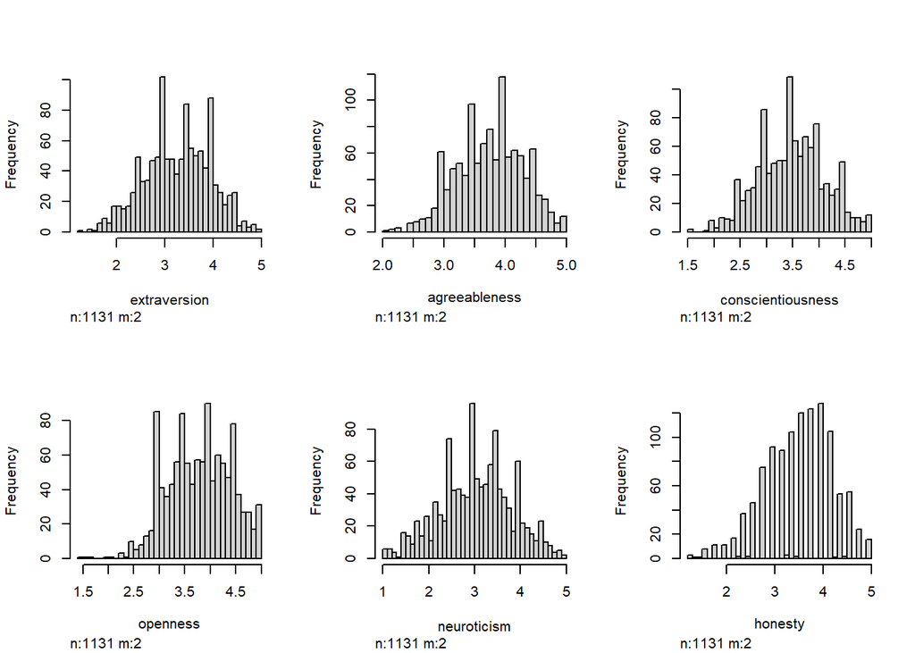

```r
data_R %>%
  dplyr::select(extraversion, agreeableness, conscientiousness, openness, neuroticism, honesty) %>%
  hist()
```

## Clothing Interest

### Reverse-code

```r
data_R <- data_R %>%
  mutate(across(c(clothing_interest_3,
                  clothing_interest_5,
                  clothing_interest_7,
                  clothing_interest_9,
                  clothing_interest_12,
                  clothing_interest_14,
                  clothing_interest_15,
                  clothing_interest_16,
                  clothing_interest_18,
                  clothing_interest_20), ~6 - .)) # replace '#' with the max possible value plus 1 for any particular scale
```

### Average items

```r
data_R$clothing_interest <- data_R %>%
  dplyr::select(clothing_interest_1:clothing_interest_20) %>%
  rowMeans(na.rm = TRUE)
```

### Visually Inspect

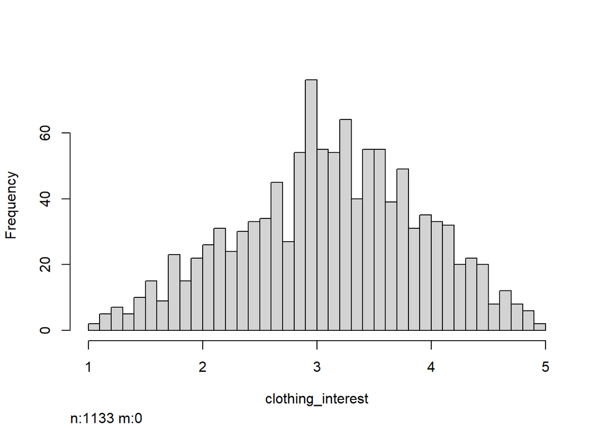

```r
data_R %>%
  dplyr::select(clothing_interest) %>%
  hist()
```

## In-group Identification

### Reverse-code

No items need to be reverse-coded.

### Average items

```r
data_R$ingroup_identification <- data_R %>%
  dplyr::select(ingroup_ident_1:ingroup_ident_14) %>%
  rowMeans(na.rm = TRUE)
```

### Visually Inspect

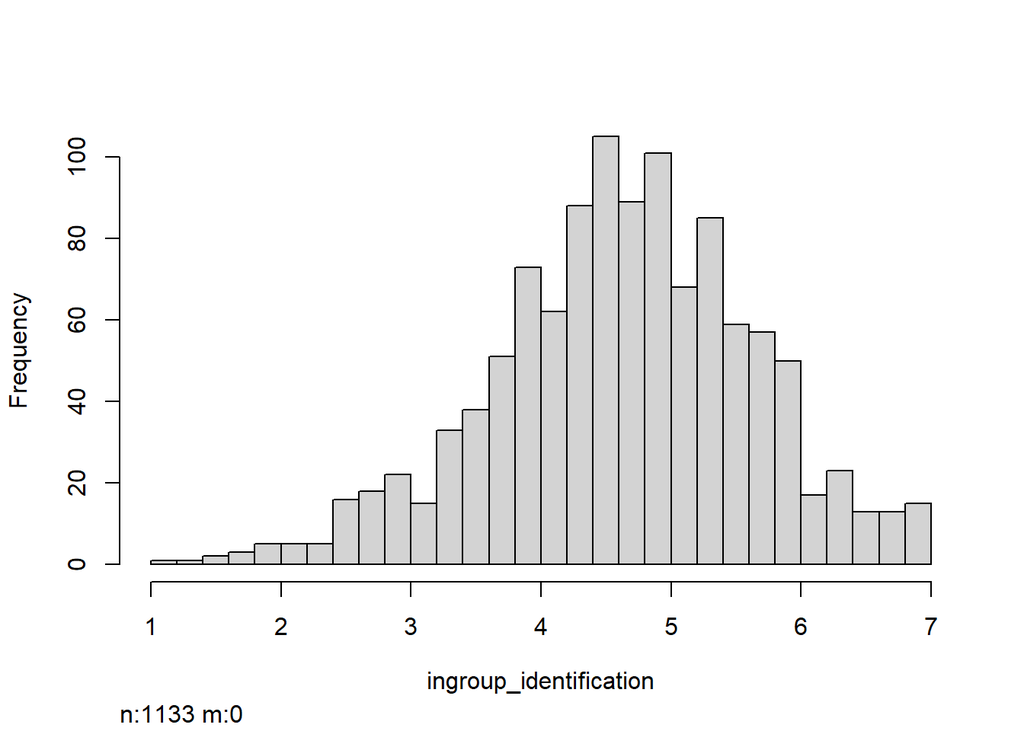

```r
data_R %>%
  dplyr::select(ingroup_identification) %>%
  hist()
```

## Values

### Reverse-code

No items need to be reverse-coded.

### Recoding scale options

Recoding values:

- -3 = 1
- -2 = 2
- -1 = 3
- 0 = 4
- +1 = 5
- +2 = 6
- +3 = 7

```r
table(data_R$values_1)
```

```
##
##  -3  -2  -1   0   1   2   3
##   5  10  17  40 176 362 508
```

```r
data_R$values_1_rec <- dplyr::recode(data_R$values_1, `-3` = 1, `-2` = 2, `-1` = 3, `0` = 4, `1` = 5, `2` = 6, `3` = 7)

table(data_R$values_1_rec)
```

```
##
##   1   2   3   4   5   6   7
##   5  10  17  40 176 362 508
```

```r
data_R$values_2_rec <- dplyr::recode(data_R$values_2, `-3` = 1, `-2` = 2, `-1` = 3, `0` = 4, `1` = 5, `2` = 6, `3` = 7)
data_R$values_3_rec <- dplyr::recode(data_R$values_3, `-3` = 1, `-2` = 2, `-1` = 3, `0` = 4, `1` = 5, `2` = 6, `3` = 7)
data_R$values_4_rec <- dplyr::recode(data_R$values_4, `-3` = 1, `-2` = 2, `-1` = 3, `0` = 4, `1` = 5, `2` = 6, `3` = 7)
data_R$values_5_rec <- dplyr::recode(data_R$values_5, `-3` = 1, `-2` = 2, `-1` = 3, `0` = 4, `1` = 5, `2` = 6, `3` = 7)
data_R$values_6_rec <- dplyr::recode(data_R$values_6, `-3` = 1, `-2` = 2, `-1` = 3, `0` = 4, `1` = 5, `2` = 6, `3` = 7)
data_R$values_7_rec <- dplyr::recode(data_R$values_7, `-3` = 1, `-2` = 2, `-1` = 3, `0` = 4, `1` = 5, `2` = 6, `3` = 7)
data_R$values_8_rec <- dplyr::recode(data_R$values_8, `-3` = 1, `-2` = 2, `-1` = 3, `0` = 4, `1` = 5, `2` = 6, `3` = 7)
data_R$values_9_rec <- dplyr::recode(data_R$values_9, `-3` = 1, `-2` = 2, `-1` = 3, `0` = 4, `1` = 5, `2` = 6, `3` = 7)
data_R$values_10_rec <- dplyr::recode(data_R$values_10, `-3` = 1, `-2` = 2, `-1` = 3, `0` = 4, `1` = 5, `2` = 6, `3` = 7)
data_R$values_11_rec <- dplyr::recode(data_R$values_11, `-3` = 1, `-2` = 2, `-1` = 3, `0` = 4, `1` = 5, `2` = 6, `3` = 7)
data_R$values_12_rec <- dplyr::recode(data_R$values_12, `-3` = 1, `-2` = 2, `-1` = 3, `0` = 4, `1` = 5, `2` = 6, `3` = 7)
data_R$values_13_rec <- dplyr::recode(data_R$values_13, `-3` = 1, `-2` = 2, `-1` = 3, `0` = 4, `1` = 5, `2` = 6, `3` = 7)
data_R$values_14_rec <- dplyr::recode(data_R$values_14, `-3` = 1, `-2` = 2, `-1` = 3, `0` = 4, `1` = 5, `2` = 6, `3` = 7)
data_R$values_15_rec <- dplyr::recode(data_R$values_15, `-3` = 1, `-2` = 2, `-1` = 3, `0` = 4, `1` = 5, `2` = 6, `3` = 7)
data_R$values_16_rec <- dplyr::recode(data_R$values_16, `-3` = 1, `-2` = 2, `-1` = 3, `0` = 4, `1` = 5, `2` = 6, `3` = 7)

table(data_R$values_16)
```

```
##
##  -3  -2  -1   0   1   2   3
##   4  11  29 116 250 394 312
```

```r
table(data_R$values_16_rec)
```

```
##
##   1   2   3   4   5   6   7
##   4  11  29 116 250 394 312
```

### Average items

```r
data_R$biospheric <- data_R %>%
  dplyr::select(values_1_rec:values_4_rec) %>%
  rowMeans(na.rm = TRUE)

data_R$altruistic <- data_R %>%
  dplyr::select(values_5_rec:values_8_rec) %>%
  rowMeans(na.rm = TRUE)

data_R$egoistic <- data_R %>%
  dplyr::select(values_9_rec:values_13_rec) %>%
  rowMeans(na.rm = TRUE)

data_R$hedonic <- data_R %>%
  dplyr::select(values_14_rec:values_16_rec) %>%
  rowMeans(na.rm = TRUE)
```

### Visually inspect

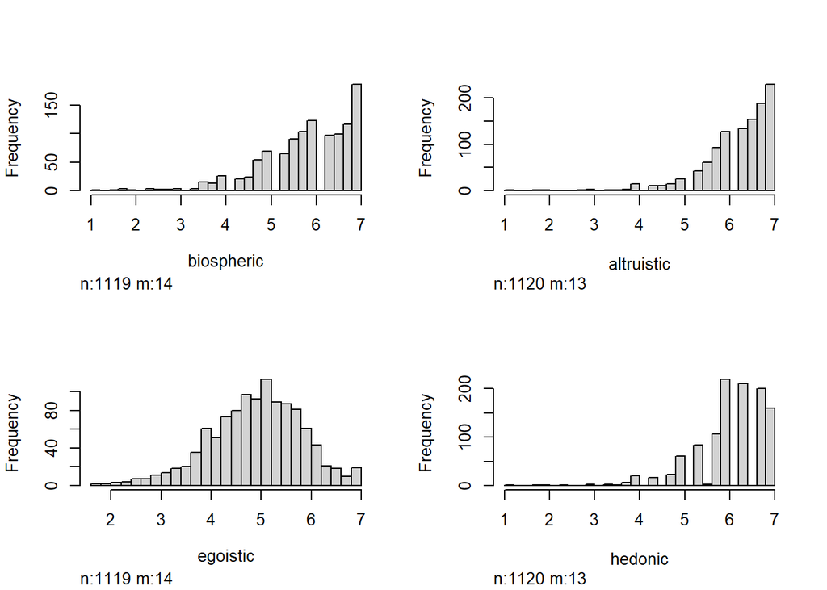

```r
values_df <- data_R %>%
  dplyr::select(biospheric, altruistic, egoistic, hedonic)

values_df %>%
  hist()
```

### Frequency tables

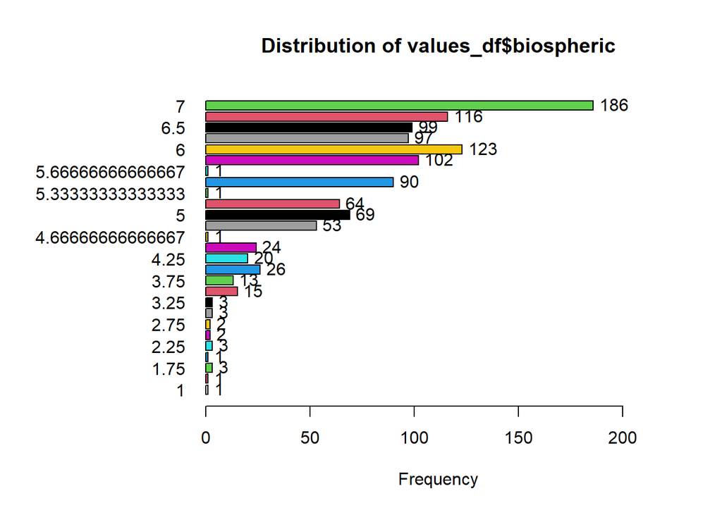

```
## values_df$biospheric :
##                  Frequency   %(NA+) cum.%(NA+)   %(NA-) cum.%(NA-)
## 1                        1      0.1        0.1      0.1        0.1
## 1.5                      1      0.1        0.2      0.1        0.2
## 1.75                     3      0.3        0.4      0.3        0.4
## 2                        1      0.1        0.5      0.1        0.5
## 2.25                     3      0.3        0.8      0.3        0.8
## 2.5                      2      0.2        1.0      0.2        1.0
## 2.75                     2      0.2        1.1      0.2        1.2
## 3                        3      0.3        1.4      0.3        1.4
## 3.25                     3      0.3        1.7      0.3        1.7
## 3.5                     15      1.3        3.0      1.3        3.0
## 3.75                    13      1.1        4.1      1.2        4.2
## 4                       26      2.3        6.4      2.3        6.5
## 4.25                    20      1.8        8.2      1.8        8.3
## 4.5                     24      2.1       10.3      2.1       10.5
## 4.66666666666667         1      0.1       10.4      0.1       10.5
## 4.75                    53      4.7       15.1      4.7       15.3
## 5                       69      6.1       21.2      6.2       21.4
## 5.25                    64      5.6       26.8      5.7       27.2
## 5.33333333333333         1      0.1       26.9      0.1       27.3
## 5.5                     90      7.9       34.9      8.0       35.3
## 5.66666666666667         1      0.1       35.0      0.1       35.4
## 5.75                   102      9.0       44.0      9.1       44.5
## 6                      123     10.9       54.8     11.0       55.5
## 6.25                    97      8.6       63.4      8.7       64.2
## 6.5                     99      8.7       72.1      8.8       73.0
## 6.75                   116     10.2       82.3     10.4       83.4
## 7                      186     16.4       98.8     16.6      100.0
## NaN                     14      1.2      100.0      0.0      100.0
##   Total               1133    100.0      100.0    100.0      100.0
```

```r
# Biospheric values
tab1(values_df$biospheric, sort.group = "descending", cum.percent = TRUE, missing = FALSE, horiz = TRUE)
```

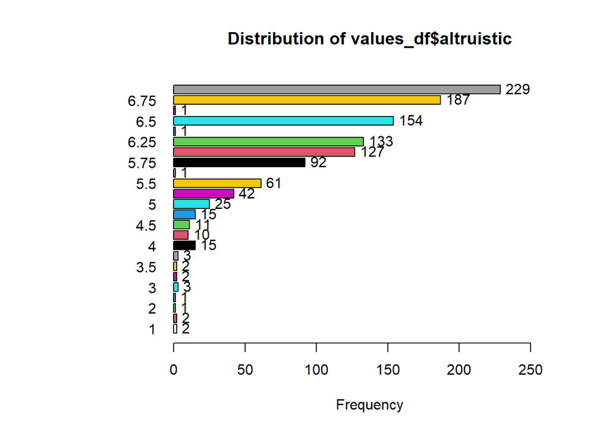

```
## values_df$altruistic :
##                  Frequency   %(NA+) cum.%(NA+)   %(NA-) cum.%(NA-)
## 1                        2      0.2        0.2      0.2        0.2
## 1.75                     2      0.2        0.4      0.2        0.4
## 2                        1      0.1        0.4      0.1        0.4
## 2.75                     1      0.1        0.5      0.1        0.5
## 3                        3      0.3        0.8      0.3        0.8
## 3.25                     2      0.2        1.0      0.2        1.0
## 3.5                      2      0.2        1.1      0.2        1.2
## 3.75                     3      0.3        1.4      0.3        1.4
## 4                       15      1.3        2.7      1.3        2.8
## 4.25                    10      0.9        3.6      0.9        3.7
## 4.5                     11      1.0        4.6      1.0        4.6
## 4.75                    15      1.3        5.9      1.3        6.0
## 5                       25      2.2        8.1      2.2        8.2
## 5.25                    42      3.7       11.8      3.8       12.0
## 5.5                     61      5.4       17.2      5.4       17.4
## 5.66666666666667         1      0.1       17.3      0.1       17.5
## 5.75                    92      8.1       25.4      8.2       25.7
## 6                      127     11.2       36.6     11.3       37.1
## 6.25                   133     11.7       48.4     11.9       48.9
## 6.33333333333333         1      0.1       48.5      0.1       49.0
## 6.5                    154     13.6       62.0     13.8       62.8
## 6.66666666666667         1      0.1       62.1      0.1       62.9
## 6.75                   187     16.5       78.6     16.7       79.6
## 7                      229     20.2       98.9     20.4      100.0
## NaN                     13      1.1      100.0      0.0      100.0
##   Total               1133    100.0      100.0    100.0      100.0
```

```r
# Altruistic values
tab1(values_df$altruistic, sort.group = "descending", cum.percent = TRUE, missing = FALSE, horiz = TRUE)
```

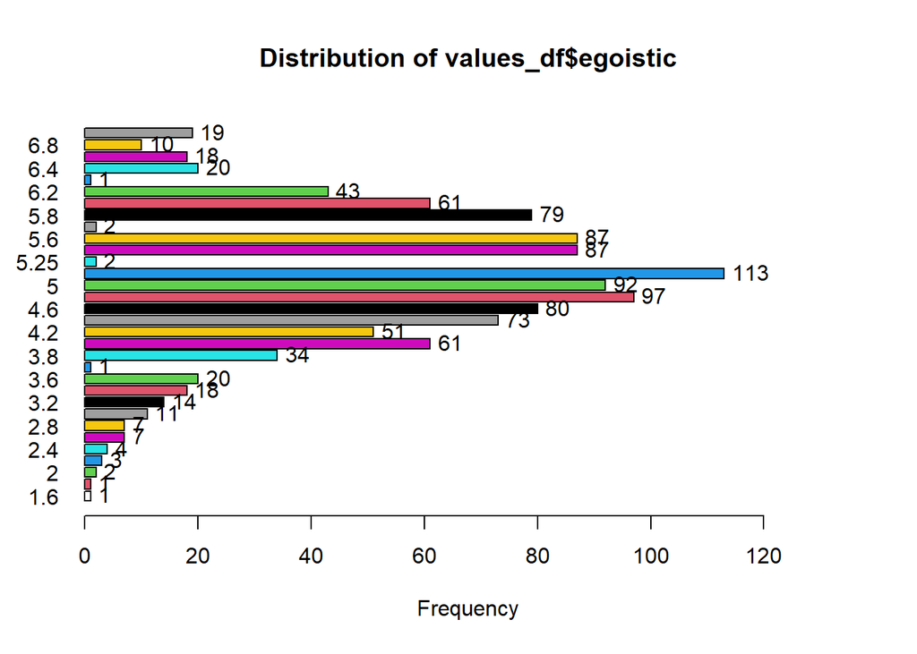

```
## values_df$egoistic :
##         Frequency   %(NA+) cum.%(NA+)   %(NA-) cum.%(NA-)
## 1.6             1      0.1        0.1      0.1        0.1
## 1.8             1      0.1        0.2      0.1        0.2
## 2               2      0.2        0.4      0.2        0.4
## 2.2             3      0.3        0.6      0.3        0.6
## 2.4             4      0.4        1.0      0.4        1.0
## 2.6             7      0.6        1.6      0.6        1.6
## 2.8             7      0.6        2.2      0.6        2.2
## 3              11      1.0        3.2      1.0        3.2
## 3.2            14      1.2        4.4      1.3        4.5
## 3.4            18      1.6        6.0      1.6        6.1
## 3.6            20      1.8        7.8      1.8        7.9
## 3.75            1      0.1        7.9      0.1        8.0
## 3.8            34      3.0       10.9      3.0       11.0
## 4              61      5.4       16.2      5.5       16.4
## 4.2            51      4.5       20.7      4.6       21.0
## 4.4            73      6.4       27.2      6.5       27.5
## 4.6            80      7.1       34.2      7.1       34.7
## 4.8            97      8.6       42.8      8.7       43.3
## 5              92      8.1       50.9      8.2       51.6
## 5.2           113     10.0       60.9     10.1       61.7
## 5.25            2      0.2       61.1      0.2       61.8
## 5.4            87      7.7       68.8      7.8       69.6
## 5.6            87      7.7       76.4      7.8       77.4
## 5.75            2      0.2       76.6      0.2       77.6
## 5.8            79      7.0       83.6      7.1       84.6
## 6              61      5.4       89.0      5.5       90.1
## 6.2            43      3.8       92.8      3.8       93.9
## 6.25            1      0.1       92.9      0.1       94.0
## 6.4            20      1.8       94.6      1.8       95.8
## 6.6            18      1.6       96.2      1.6       97.4
## 6.8            10      0.9       97.1      0.9       98.3
## 7              19      1.7       98.8      1.7      100.0
## NaN            14      1.2      100.0      0.0      100.0
##   Total      1133    100.0      100.0    100.0      100.0
```

```r
# Egoistic values
tab1(values_df$egoistic, sort.group = "descending", cum.percent = TRUE, missing = FALSE, horiz = TRUE)
```

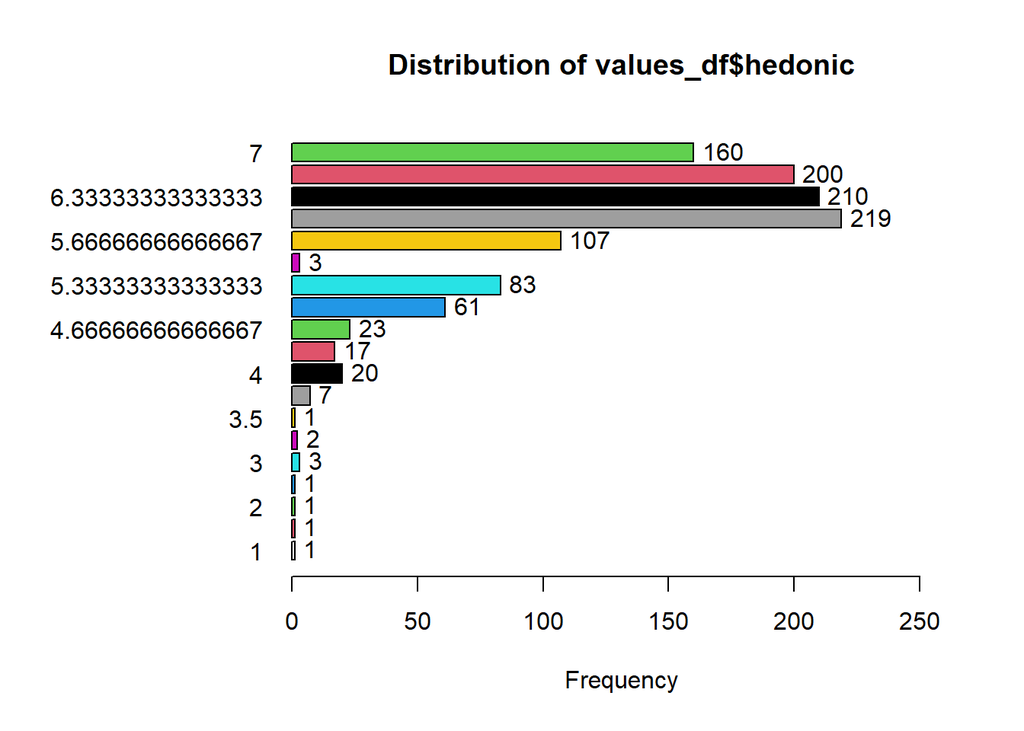

```
## values_df$hedonic :
##                  Frequency   %(NA+) cum.%(NA+)   %(NA-) cum.%(NA-)
## 1                        1      0.1        0.1      0.1        0.1
## 1.66666666666667         1      0.1        0.2      0.1        0.2
## 2                        1      0.1        0.3      0.1        0.3
## 2.33333333333333         1      0.1        0.4      0.1        0.4
## 3                        3      0.3        0.6      0.3        0.6
## 3.33333333333333         2      0.2        0.8      0.2        0.8
## 3.5                      1      0.1        0.9      0.1        0.9
## 3.66666666666667         7      0.6        1.5      0.6        1.5
## 4                       20      1.8        3.3      1.8        3.3
## 4.33333333333333        17      1.5        4.8      1.5        4.8
## 4.66666666666667        23      2.0        6.8      2.1        6.9
## 5                       61      5.4       12.2      5.4       12.3
## 5.33333333333333        83      7.3       19.5      7.4       19.7
## 5.5                      3      0.3       19.8      0.3       20.0
## 5.66666666666667       107      9.4       29.2      9.6       29.6
## 6                      219     19.3       48.5     19.6       49.1
## 6.33333333333333       210     18.5       67.1     18.8       67.9
## 6.66666666666667       200     17.7       84.7     17.9       85.7
## 7                      160     14.1       98.9     14.3      100.0
## NaN                     13      1.1      100.0      0.0      100.0
##   Total               1133    100.0      100.0    100.0      100.0
```

```r
# Hedonic values
tab1(values_df$hedonic, sort.group = "descending", cum.percent = TRUE, missing = FALSE, horiz = TRUE)
```

## Socially Desirable Responding

### Reverse-code

```r
data_R <- data_R %>%
  mutate(across(c(socially_desirable_1,
                  socially_desirable_3,
                  socially_desirable_5,
                  socially_desirable_8,
                  socially_desirable_9,
                  socially_desirable_11,
                  socially_desirable_12,
                  socially_desirable_13), ~8 - .)) # replace '#' with the max possible value plus 1 for any particular scale
```

### Average items

```r
data_R$self_deceptive_sdr <- data_R %>%
  dplyr::select(socially_desirable_1:socially_desirable_8) %>%
  rowMeans(na.rm = TRUE)

data_R$impress_manag_sdr <- data_R %>%
  dplyr::select(socially_desirable_9:socially_desirable_16) %>%
  rowMeans(na.rm = TRUE)
```

### Visually inspect

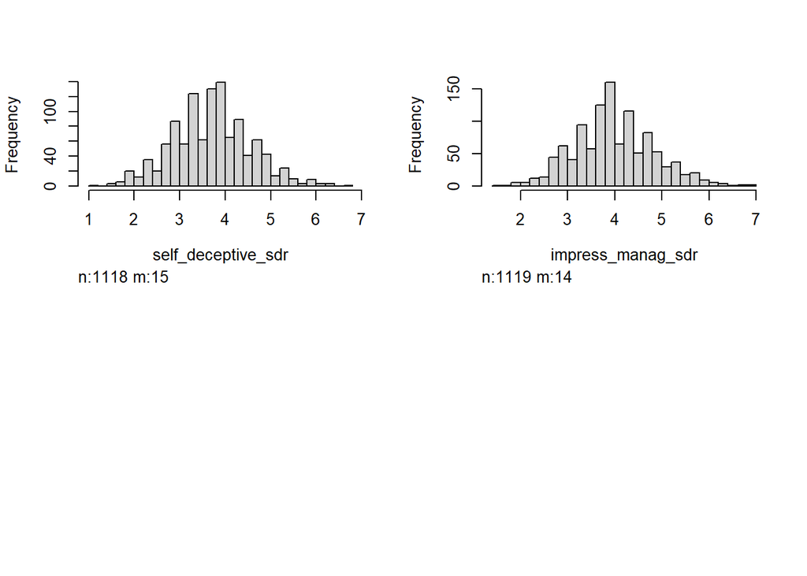

```r
data_R %>%
  dplyr::select(self_deceptive_sdr, impress_manag_sdr) %>%
  hist()
```

## Consumer Intentions

### Reverse-code

Higher scores mean better consumer intentions (intentions to *reduce* future consumption):

```r
data_R <- data_R %>%
  mutate(across(c(consumer_intentions_2,
                  consumer_intentions_4,
                  consumer_intentions_7,
                  consumer_intentions_9), ~8 - .)) # replace '#' with the max possible value plus 1 for any particular scale
```

### Average items

```r
data_R$consumer_intentions <- data_R %>%
  dplyr::select(consumer_intentions_1:consumer_intentions_9) %>%
  rowMeans(na.rm = TRUE)
```

### Visually inspect

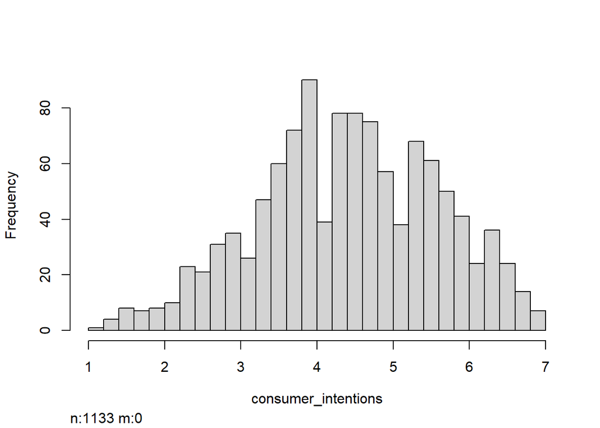

```r
data_R %>%
  dplyr::select(consumer_intentions) %>%
  hist()
```

# Contrast Coding

Subset variables

Contrast Coding using ifelse() approach:

```r
# Framing
data_R_alt$FramingCode1 <- ifelse(data_R_alt$framing_condition == "control_framing", -1/2, ifelse(data_R_alt$framing_condition == "self_enh_framing", 1/2, 0))

data_R_alt$FramingCode2 <- ifelse(data_R_alt$framing_condition == "pro_env_framing", 2/3, -1/3)


# Norm
data_R_alt$NormCode1 <- ifelse(data_R_alt$norm_condition == "moral_norm", 4, -1)

data_R_alt$NormCode2 <- ifelse(data_R_alt$norm_condition == "social_norm", 3, ifelse(data_R_alt$norm_condition == "moral_norm", 0, -1))

data_R_alt$NormCode3 <- ifelse(data_R_alt$norm_condition == "convention_norm", 2, ifelse(data_R_alt$norm_condition == "moral_norm", 0, ifelse(data_R_alt$norm_condition == "social_norm", 0, -1)))
data_R_alt$NormCode4 <- ifelse(data_R_alt$norm_condition == "descriptive_norm", 1, ifelse(data_R_alt$norm_condition == "control_norm", -1, 0))


## Adding contrast codes to Framing & Norm Condition
# Framing
FrameCode1 <- c(-1/2, 0, 1/2) # control vs self-enhancing
FrameCode2 <- c(-1/3, 2/3, -1/3) # arbitrary code

contrasts(data_R_alt$framing_condition) <- cbind(FrameCode1, FrameCode2)
contrasts(data_R_alt$framing_condition)
```

```
##                  FrameCode1 FrameCode2
## control_framing        -0.5 -0.3333333
## pro_env_framing         0.0  0.6666667
## self_enh_framing        0.5 -0.3333333
```

```r
# Norm
contrasts(data_R_alt$norm_condition) <- contr.helmert(5)
contrasts(data_R_alt$norm_condition) # control vs DN
```

```
##                  [,1] [,2] [,3] [,4]
## control_norm       -1   -1   -1   -1
## descriptive_norm    1   -1   -1   -1
## convention_norm     0    2   -1   -1
## social_norm         0    0    3   -1
## moral_norm          0    0    0    4
```

```r
# Gender
levels(data_R_alt$Gender) <- c("Woman", "Man", "Non-binary", "I prefer not to identify", "Other")

data_R_alt$Gender[data_R_alt$Gender == "Non-binary"] <- NA
data_R_alt$Gender[data_R_alt$Gender == "I prefer not to identify"] <- NA
data_R_alt$Gender[data_R_alt$Gender == "Other"] <- NA

data_R_alt$Gender <- droplevels(data_R_alt$Gender)

contrasts(data_R_alt$Gender) <- c(1, 0)
levels(data_R_alt$Gender)
```

```
## [1] "Woman" "Man"
```

Coding consumer_behaviors 0/1 and numeric because required by smcfcs imputation function:

```r
data_R_alt$consumer_behaviors <- as.numeric(data_R_alt$consumer_behaviors)

data_R_alt$consumer_behaviors <- ifelse(data_R_alt$consumer_behaviors == 1, 0, 1)
```

# Multiple Imputation

## Examine Missingness

Examine missingness:

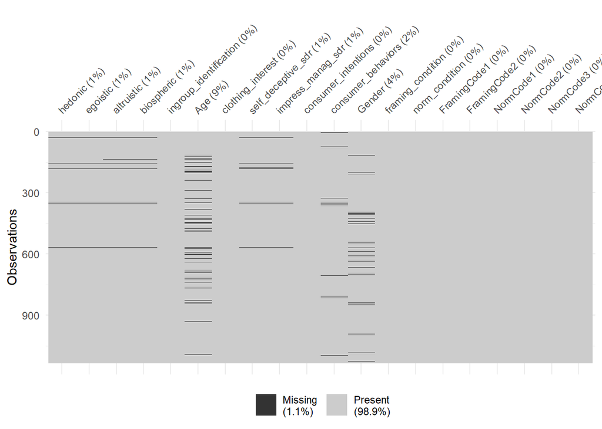

```r
data_R_alt %>%
  vis_miss()
```

Variables with NO missing data:

- ingroup_identification
- clothing_interest
- consumer_intentions
- framing_condition
- norm_condition

## Imputation Model

```r
set.seed(114950518)
```

[output not shown]

Storing imputed data sets

```r
impobject <- imputationList(imps$impDatasets)
```

Restrict range of values on imputed variables

```r
# bio values
impobject$imputations[[1]]$biospheric <- ifelse(impobject$imputations[[1]]$biospheric > 7, 7, impobject$imputations[[1]]$biospheric)

impobject$imputations[[2]]$biospheric <- ifelse(impobject$imputations[[2]]$biospheric > 7, 7, impobject$imputations[[2]]$biospheric)

impobject$imputations[[3]]$biospheric <- ifelse(impobject$imputations[[3]]$biospheric > 7, 7, impobject$imputations[[3]]$biospheric)

impobject$imputations[[4]]$biospheric <- ifelse(impobject$imputations[[4]]$biospheric > 7, 7, impobject$imputations[[4]]$biospheric)

impobject$imputations[[5]]$biospheric <- ifelse(impobject$imputations[[5]]$biospheric > 7, 7, impobject$imputations[[5]]$biospheric)


# alt values
impobject$imputations[[1]]$altruistic <- ifelse(impobject$imputations[[1]]$altruistic > 7, 7, impobject$imputations[[1]]$altruistic)

impobject$imputations[[2]]$altruistic <- ifelse(impobject$imputations[[2]]$altruistic > 7, 7, impobject$imputations[[2]]$altruistic)

impobject$imputations[[3]]$altruistic <- ifelse(impobject$imputations[[3]]$altruistic > 7, 7, impobject$imputations[[3]]$altruistic)

impobject$imputations[[4]]$altruistic <- ifelse(impobject$imputations[[4]]$altruistic > 7, 7, impobject$imputations[[4]]$altruistic)

impobject$imputations[[5]]$altruistic <- ifelse(impobject$imputations[[5]]$altruistic > 7, 7, impobject$imputations[[5]]$altruistic)


# ego values
impobject$imputations[[1]]$egoistic <- ifelse(impobject$imputations[[1]]$egoistic > 7, 7, impobject$imputations[[1]]$egoistic)

impobject$imputations[[2]]$egoistic <- ifelse(impobject$imputations[[2]]$egoistic > 7, 7, impobject$imputations[[2]]$egoistic)

impobject$imputations[[3]]$egoistic <- ifelse(impobject$imputations[[3]]$egoistic > 7, 7, impobject$imputations[[3]]$egoistic)

impobject$imputations[[4]]$egoistic <- ifelse(impobject$imputations[[4]]$egoistic > 7, 7, impobject$imputations[[4]]$egoistic)

impobject$imputations[[5]]$egoistic <- ifelse(impobject$imputations[[5]]$egoistic > 7, 7, impobject$imputations[[5]]$egoistic)


# hed values
impobject$imputations[[1]]$hedonic <- ifelse(impobject$imputations[[1]]$hedonic > 7, 7, impobject$imputations[[1]]$hedonic)

impobject$imputations[[2]]$hedonic <- ifelse(impobject$imputations[[2]]$hedonic > 7, 7, impobject$imputations[[2]]$hedonic)

impobject$imputations[[3]]$hedonic <- ifelse(impobject$imputations[[3]]$hedonic > 7, 7, impobject$imputations[[3]]$hedonic)

impobject$imputations[[4]]$hedonic <- ifelse(impobject$imputations[[4]]$hedonic > 7, 7, impobject$imputations[[4]]$hedonic)

impobject$imputations[[5]]$hedonic <- ifelse(impobject$imputations[[5]]$hedonic > 7, 7, impobject$imputations[[5]]$hedonic)


# self-deceptive enhancement
with(impobject, describe(self_deceptive_sdr))
```

```
## [[1]]
##    vars    n mean   sd median trimmed  mad min  max range skew kurtosis   se
## X1    1 1133 3.72 0.85   3.75    3.71 0.74   1 6.62  5.62 0.13     0.14 0.03
##
## [[2]]
##    vars    n mean   sd median trimmed  mad min  max range skew kurtosis   se
## X1    1 1133 3.71 0.86   3.75     3.7 0.74   1 6.62  5.62 0.15     0.14 0.03
##
## [[3]]
##    vars    n mean   sd median trimmed  mad min  max range skew kurtosis   se
## X1    1 1133 3.72 0.86   3.75    3.71 0.74   1 6.75  5.75 0.15     0.23 0.03
##
## [[4]]
##    vars    n mean   sd median trimmed  mad min  max range skew kurtosis   se
## X1    1 1133 3.72 0.86   3.75    3.71 0.74   1 6.62  5.62 0.14     0.13 0.03
##
## [[5]]
##    vars    n mean   sd median trimmed  mad min  max range skew kurtosis   se
## X1    1 1133 3.72 0.85   3.75    3.71 0.74   1 6.62  5.62 0.14     0.14 0.03
##
## attr(,"call")
## with(impobject, describe(self_deceptive_sdr))
```

```r
impobject$imputations[[4]]$self_deceptive_sdr <- ifelse(impobject$imputations[[4]]$self_deceptive_sdr < 1, 1, impobject$imputations[[4]]$self_deceptive_sdr)


# impr manag
with(impobject, describe(impress_manag_sdr))
```

```
## [[1]]
##    vars    n mean   sd median trimmed  mad min max range skew kurtosis   se
## X1    1 1133 4.01 0.85      4    3.99 0.74 1.5   7   5.5 0.24     0.14 0.03
##
## [[2]]
##    vars    n mean   sd median trimmed  mad min max range skew kurtosis   se
## X1    1 1133 4.01 0.85      4    3.99 0.74 1.5   7   5.5 0.24     0.14 0.03
##
## [[3]]
##    vars    n mean   sd median trimmed  mad min max range skew kurtosis   se
## X1    1 1133 4.01 0.85      4    3.99 0.74 1.5   7   5.5 0.25     0.16 0.03
##
## [[4]]
##    vars    n mean   sd median trimmed  mad min max range skew kurtosis   se
## X1    1 1133    4 0.85      4    3.99 0.74 1.5   7   5.5 0.25     0.17 0.03
##
## [[5]]
##    vars    n mean   sd median trimmed  mad min max range skew kurtosis   se
## X1    1 1133 4.01 0.85      4    3.99 0.74 1.5   7   5.5 0.27     0.19 0.03
##
## attr(,"call")
## with(impobject, describe(impress_manag_sdr))
```

```r
# Age
describe(data_R_alt$Age)
```

```
##    vars    n  mean   sd median trimmed  mad min max range skew kurtosis   se
## X1    1 1030 19.87 1.95     19   19.67 1.48  18  50    32 4.91    59.29 0.06
```

```r
with(impobject, describe(Age))
```

```
## [[1]]
##    vars    n  mean   sd median trimmed  mad   min max range skew kurtosis   se
## X1    1 1133 19.89 1.94  19.39    19.7 2.06 15.09  50 34.91 4.56    54.97 0.06
##
## [[2]]
##    vars    n  mean   sd median trimmed  mad   min max range skew kurtosis   se
## X1    1 1133 19.85 1.94     19   19.67 1.48 14.85  50 35.15 4.55    55.63 0.06
##
## [[3]]
##    vars    n  mean   sd median trimmed  mad   min max range skew kurtosis   se
## X1    1 1133 19.88 1.98  19.05   19.69 1.55 13.77  50 36.23 4.27    50.86 0.06
##
## [[4]]
##    vars    n  mean   sd median trimmed  mad   min max range skew kurtosis   se
## X1    1 1133 19.88 1.97  19.25    19.7 1.86 14.74  50 35.26 4.37    52.37 0.06
##
## [[5]]
##    vars    n mean   sd median trimmed  mad   min max range skew kurtosis   se
## X1    1 1133 19.9 1.95  19.48   19.71 2.19 15.37  50 34.63 4.49    53.77 0.06
##
## attr(,"call")
## with(impobject, describe(Age))
```

```r
impobject$imputations[[1]]$Age <- ifelse(impobject$imputations[[1]]$Age < 18, 18, impobject$imputations[[1]]$Age)

impobject$imputations[[2]]$Age <- ifelse(impobject$imputations[[2]]$Age < 18, 18, impobject$imputations[[2]]$Age)

impobject$imputations[[3]]$Age <- ifelse(impobject$imputations[[3]]$Age < 18, 18, impobject$imputations[[3]]$Age)

impobject$imputations[[4]]$Age <- ifelse(impobject$imputations[[4]]$Age < 18, 18, impobject$imputations[[4]]$Age)

impobject$imputations[[5]]$Age <- ifelse(impobject$imputations[[5]]$Age < 18, 18, impobject$imputations[[5]]$Age)
```

### Centering continuous predictors

```r
# Biospheric values
impobject$imputations[[1]]$biospheric_center <- impobject$imputations[[1]]$biospheric - mean(impobject$imputations[[1]]$biospheric)

impobject$imputations[[2]]$biospheric_center <- impobject$imputations[[2]]$biospheric - mean(impobject$imputations[[2]]$biospheric)

impobject$imputations[[3]]$biospheric_center <- impobject$imputations[[3]]$biospheric - mean(impobject$imputations[[3]]$biospheric)

impobject$imputations[[4]]$biospheric_center <- impobject$imputations[[4]]$biospheric - mean(impobject$imputations[[4]]$biospheric)

impobject$imputations[[5]]$biospheric_center <- impobject$imputations[[5]]$biospheric - mean(impobject$imputations[[5]]$biospheric)


# Altruistic values
impobject$imputations[[1]]$altruistic_center <- impobject$imputations[[1]]$altruistic - mean(impobject$imputations[[1]]$altruistic)

impobject$imputations[[2]]$altruistic_center <- impobject$imputations[[2]]$altruistic - mean(impobject$imputations[[2]]$altruistic)

impobject$imputations[[3]]$altruistic_center <- impobject$imputations[[3]]$altruistic - mean(impobject$imputations[[3]]$altruistic)

impobject$imputations[[4]]$altruistic_center <- impobject$imputations[[4]]$altruistic - mean(impobject$imputations[[4]]$altruistic)

impobject$imputations[[5]]$altruistic_center <- impobject$imputations[[5]]$altruistic - mean(impobject$imputations[[5]]$altruistic)


# Egoistic values
impobject$imputations[[1]]$egoistic_center <- impobject$imputations[[1]]$egoistic - mean(impobject$imputations[[1]]$egoistic)

impobject$imputations[[2]]$egoistic_center <- impobject$imputations[[2]]$egoistic - mean(impobject$imputations[[2]]$egoistic)

impobject$imputations[[3]]$egoistic_center <- impobject$imputations[[3]]$egoistic - mean(impobject$imputations[[3]]$egoistic)

impobject$imputations[[4]]$egoistic_center <- impobject$imputations[[4]]$egoistic - mean(impobject$imputations[[4]]$egoistic)

impobject$imputations[[5]]$egoistic_center <- impobject$imputations[[5]]$egoistic - mean(impobject$imputations[[5]]$egoistic)


# Hedonic values
impobject$imputations[[1]]$hedonic_center <- impobject$imputations[[1]]$hedonic - mean(impobject$imputations[[1]]$hedonic)

impobject$imputations[[2]]$hedonic_center <- impobject$imputations[[2]]$hedonic - mean(impobject$imputations[[2]]$hedonic)

impobject$imputations[[3]]$hedonic_center <- impobject$imputations[[3]]$hedonic - mean(impobject$imputations[[3]]$hedonic)

impobject$imputations[[4]]$hedonic_center <- impobject$imputations[[4]]$hedonic - mean(impobject$imputations[[4]]$hedonic)

impobject$imputations[[5]]$hedonic_center <- impobject$imputations[[5]]$hedonic - mean(impobject$imputations[[5]]$hedonic)



# Ingroup identification
impobject$imputations[[1]]$ingroup_center <- impobject$imputations[[1]]$ingroup_identification - mean(impobject$imputations[[1]]$ingroup_identification)

impobject$imputations[[2]]$ingroup_center <- impobject$imputations[[2]]$ingroup_identification - mean(impobject$imputations[[2]]$ingroup_identification)

impobject$imputations[[3]]$ingroup_center <- impobject$imputations[[3]]$ingroup_identification - mean(impobject$imputations[[3]]$ingroup_identification)

impobject$imputations[[4]]$ingroup_center <- impobject$imputations[[4]]$ingroup_identification - mean(impobject$imputations[[4]]$ingroup_identification)

impobject$imputations[[5]]$ingroup_center <- impobject$imputations[[5]]$ingroup_identification - mean(impobject$imputations[[5]]$ingroup_identification)


# Age
impobject$imputations[[1]]$Age_center <- impobject$imputations[[1]]$Age - mean(impobject$imputations[[1]]$Age)

impobject$imputations[[2]]$Age_center <- impobject$imputations[[2]]$Age - mean(impobject$imputations[[2]]$Age)

impobject$imputations[[3]]$Age_center <- impobject$imputations[[3]]$Age - mean(impobject$imputations[[3]]$Age)

impobject$imputations[[4]]$Age_center <- impobject$imputations[[4]]$Age - mean(impobject$imputations[[4]]$Age)

impobject$imputations[[5]]$Age_center <- impobject$imputations[[5]]$Age - mean(impobject$imputations[[5]]$Age)



# Clothing interest
impobject$imputations[[1]]$clothing_center <- impobject$imputations[[1]]$clothing_interest - mean(impobject$imputations[[1]]$clothing_interest)

impobject$imputations[[2]]$clothing_center <- impobject$imputations[[2]]$clothing_interest - mean(impobject$imputations[[2]]$clothing_interest)

impobject$imputations[[3]]$clothing_center <- impobject$imputations[[3]]$clothing_interest - mean(impobject$imputations[[3]]$clothing_interest)

impobject$imputations[[4]]$clothing_center <- impobject$imputations[[4]]$clothing_interest - mean(impobject$imputations[[4]]$clothing_interest)

impobject$imputations[[5]]$clothing_center <- impobject$imputations[[5]]$clothing_interest - mean(impobject$imputations[[5]]$clothing_interest)



# Self deceptive SDR
impobject$imputations[[1]]$self_dec_center <- impobject$imputations[[1]]$self_deceptive_sdr - mean(impobject$imputations[[1]]$self_deceptive_sdr)

impobject$imputations[[2]]$self_dec_center <- impobject$imputations[[2]]$self_deceptive_sdr - mean(impobject$imputations[[2]]$self_deceptive_sdr)

impobject$imputations[[3]]$self_dec_center <- impobject$imputations[[3]]$self_deceptive_sdr - mean(impobject$imputations[[3]]$self_deceptive_sdr)

impobject$imputations[[4]]$self_dec_center <- impobject$imputations[[4]]$self_deceptive_sdr - mean(impobject$imputations[[4]]$self_deceptive_sdr)

impobject$imputations[[5]]$self_dec_center <- impobject$imputations[[5]]$self_deceptive_sdr - mean(impobject$imputations[[5]]$self_deceptive_sdr)


# Impression management SDR
impobject$imputations[[1]]$impress_manag_center <- impobject$imputations[[1]]$impress_manag_sdr - mean(impobject$imputations[[1]]$impress_manag_sdr)

impobject$imputations[[2]]$impress_manag_center <- impobject$imputations[[2]]$impress_manag_sdr - mean(impobject$imputations[[2]]$impress_manag_sdr)

impobject$imputations[[3]]$impress_manag_center <- impobject$imputations[[3]]$impress_manag_sdr - mean(impobject$imputations[[3]]$impress_manag_sdr)

impobject$imputations[[4]]$impress_manag_center <- impobject$imputations[[4]]$impress_manag_sdr - mean(impobject$imputations[[4]]$impress_manag_sdr)

impobject$imputations[[5]]$impress_manag_center <- impobject$imputations[[5]]$impress_manag_sdr - mean(impobject$imputations[[5]]$impress_manag_sdr)

# Coding Gender
contrasts(impobject$imputations[[1]]$Gender) <- c(1/2, -1/2)
contrasts(impobject$imputations[[2]]$Gender) <- c(1/2, -1/2)
contrasts(impobject$imputations[[3]]$Gender) <- c(1/2, -1/2)
contrasts(impobject$imputations[[4]]$Gender) <- c(1/2, -1/2)
contrasts(impobject$imputations[[5]]$Gender) <- c(1/2, -1/2)
```

Convert `scmfcs` object to a `mids` object (to make the object compatible with `mice`, and thus, `emmeans`):

```r
mids_obj <- datlist2mids(impobject)
```

# Descriptive Statistics

```r
freqs <- with(mids_obj, table(consumer_behaviors))
freqs$analyses
```

```
## [[1]]
## consumer_behaviors
##   0   1
## 608 525
##
## [[2]]
## consumer_behaviors
##   0   1
## 605 528
##
## [[3]]
## consumer_behaviors
##   0   1
## 606 527
##
## [[4]]
## consumer_behaviors
##   0   1
## 606 527
##
## [[5]]
## consumer_behaviors
##   0   1
## 603 530
```

```r
props1 <- with(mids_obj, prop.table(table(consumer_behaviors)))
props1$analyses
```

```
## [[1]]
## consumer_behaviors
##         0         1
## 0.5366284 0.4633716
##
## [[2]]
## consumer_behaviors
##         0         1
## 0.5339806 0.4660194
##
## [[3]]
## consumer_behaviors
##         0         1
## 0.5348632 0.4651368
##
## [[4]]
## consumer_behaviors
##         0         1
## 0.5348632 0.4651368
##
## [[5]]
## consumer_behaviors
##         0         1
## 0.5322154 0.4677846
```

# Logistic Analysis (DV = Consumer Behaviors)

Consumer Behaviors

- 0 = New Clothing
- 1 = Secondhand Clothing

## Running Model

```r
log_pool_obj <- pool(log_mice)
```

- df_residual = 1038
- residual deviance: 1329

## Pooled Regression Results

```r
summary(pool(log_mice)) %>%
  knitr::kable(digits = 3)
```

| term | estimate | std.error | statistic | df | p.value |
| --- | --- | --- | --- | --- | --- |
| (Intercept) | -0.154 | 0.074 | -2.092 | 811.847 | 0.037 |
| framing_conditionFrameCode1 | 0.123 | 0.174 | 0.708 | 882.439 | 0.479 |
| framing_conditionFrameCode2 | 0.504 | 0.152 | 3.324 | 937.441 | 0.001 |
| norm_condition1 | 0.137 | 0.113 | 1.216 | 894.465 | 0.224 |
| norm_condition2 | 0.002 | 0.065 | 0.032 | 984.072 | 0.974 |
| norm_condition3 | 0.013 | 0.045 | 0.291 | 1025.111 | 0.771 |
| norm_condition4 | 0.017 | 0.036 | 0.484 | 955.659 | 0.628 |
| biospheric_center | 0.508 | 0.106 | 4.801 | 1004.891 | 0.000 |
| altruistic_center | 0.226 | 0.148 | 1.526 | 946.390 | 0.127 |
| egoistic_center | -0.729 | 0.100 | -7.294 | 751.725 | 0.000 |
| hedonic_center | 0.008 | 0.121 | 0.066 | 847.891 | 0.948 |
| ingroup_center | 0.010 | 0.073 | 0.140 | 856.019 | 0.888 |
| self_dec_center | -0.236 | 0.090 | -2.621 | 1033.255 | 0.009 |
| impress_manag_center | -0.226 | 0.088 | -2.556 | 984.405 | 0.011 |
| clothing_center | 0.051 | 0.095 | 0.539 | 1002.212 | 0.590 |
| Gender1 | -0.014 | 0.170 | -0.080 | 219.027 | 0.936 |
| Age_center | -0.087 | 0.050 | -1.733 | 57.425 | 0.088 |
| framing_conditionFrameCode1:norm_condition1 | 0.463 | 0.268 | 1.732 | 1018.113 | 0.084 |
| framing_conditionFrameCode2:norm_condition1 | 0.348 | 0.244 | 1.427 | 1000.360 | 0.154 |
| framing_conditionFrameCode1:norm_condition2 | -0.058 | 0.163 | -0.355 | 829.435 | 0.723 |
| framing_conditionFrameCode2:norm_condition2 | -0.010 | 0.134 | -0.072 | 1020.077 | 0.943 |
| framing_conditionFrameCode1:norm_condition3 | 0.063 | 0.108 | 0.584 | 936.829 | 0.559 |
| framing_conditionFrameCode2:norm_condition3 | 0.086 | 0.099 | 0.869 | 1027.197 | 0.385 |
| framing_conditionFrameCode1:norm_condition4 | 0.027 | 0.091 | 0.299 | 532.635 | 0.765 |
| framing_conditionFrameCode2:norm_condition4 | -0.041 | 0.075 | -0.554 | 838.856 | 0.580 |
| framing_conditionFrameCode1:biospheric_center | -0.187 | 0.269 | -0.693 | 1010.638 | 0.488 |
| framing_conditionFrameCode2:biospheric_center | 0.390 | 0.214 | 1.828 | 966.989 | 0.068 |
| norm_condition1:biospheric_center | 0.274 | 0.163 | 1.683 | 953.880 | 0.093 |
| norm_condition2:biospheric_center | 0.062 | 0.094 | 0.661 | 941.570 | 0.509 |
| norm_condition3:biospheric_center | 0.008 | 0.066 | 0.124 | 929.196 | 0.901 |

[output cut: 65 more lines]

APA-style table

```r
pool_summ <- summary(pool(log_mice))

apa_table(pool_summ,
          caption = "Pooled Logistic Regression Results",
          note = "DV = Consumer Behaviors")
```

*Pooled Logistic Regression Results*

| term | estimate | std.error | statistic | df | p.value |
| --- | --- | --- | --- | --- | --- |
| (Intercept) | -0.15 | 0.07 | -2.09 | 811.85 | 0.04 |
| framing_conditionFrameCode1 | 0.12 | 0.17 | 0.71 | 882.44 | 0.48 |
| framing_conditionFrameCode2 | 0.50 | 0.15 | 3.32 | 937.44 | 0.00 |
| norm_condition1 | 0.14 | 0.11 | 1.22 | 894.46 | 0.22 |
| norm_condition2 | 0.00 | 0.06 | 0.03 | 984.07 | 0.97 |
| norm_condition3 | 0.01 | 0.05 | 0.29 | 1,025.11 | 0.77 |
| norm_condition4 | 0.02 | 0.04 | 0.48 | 955.66 | 0.63 |
| biospheric_center | 0.51 | 0.11 | 4.80 | 1,004.89 | 0.00 |
| altruistic_center | 0.23 | 0.15 | 1.53 | 946.39 | 0.13 |
| egoistic_center | -0.73 | 0.10 | -7.29 | 751.72 | 0.00 |
| hedonic_center | 0.01 | 0.12 | 0.07 | 847.89 | 0.95 |
| ingroup_center | 0.01 | 0.07 | 0.14 | 856.02 | 0.89 |
| self_dec_center | -0.24 | 0.09 | -2.62 | 1,033.26 | 0.01 |
| impress_manag_center | -0.23 | 0.09 | -2.56 | 984.40 | 0.01 |
| clothing_center | 0.05 | 0.10 | 0.54 | 1,002.21 | 0.59 |
| Gender1 | -0.01 | 0.17 | -0.08 | 219.03 | 0.94 |
| Age_center | -0.09 | 0.05 | -1.73 | 57.42 | 0.09 |
| framing_conditionFrameCode1:norm_condition1 | 0.46 | 0.27 | 1.73 | 1,018.11 | 0.08 |
| framing_conditionFrameCode2:norm_condition1 | 0.35 | 0.24 | 1.43 | 1,000.36 | 0.15 |
| framing_conditionFrameCode1:norm_condition2 | -0.06 | 0.16 | -0.36 | 829.44 | 0.72 |
| framing_conditionFrameCode2:norm_condition2 | -0.01 | 0.13 | -0.07 | 1,020.08 | 0.94 |
| framing_conditionFrameCode1:norm_condition3 | 0.06 | 0.11 | 0.58 | 936.83 | 0.56 |
| framing_conditionFrameCode2:norm_condition3 | 0.09 | 0.10 | 0.87 | 1,027.20 | 0.39 |
| framing_conditionFrameCode1:norm_condition4 | 0.03 | 0.09 | 0.30 | 532.64 | 0.76 |
| framing_conditionFrameCode2:norm_condition4 | -0.04 | 0.07 | -0.55 | 838.86 | 0.58 |
| framing_conditionFrameCode1:biospheric_center | -0.19 | 0.27 | -0.69 | 1,010.64 | 0.49 |
| framing_conditionFrameCode2:biospheric_center | 0.39 | 0.21 | 1.83 | 966.99 | 0.07 |
| norm_condition1:biospheric_center | 0.27 | 0.16 | 1.68 | 953.88 | 0.09 |
| norm_condition2:biospheric_center | 0.06 | 0.09 | 0.66 | 941.57 | 0.51 |
| norm_condition3:biospheric_center | 0.01 | 0.07 | 0.12 | 929.20 | 0.90 |

[output cut: 65 more lines]

*Note.* DV = Consumer Behaviors

### Odds Ratios

Converting log odds estimates to odds ratios:

```r
ORs_pool <- cbind(log_summ_pool$term, exp(log_summ_pool$estimate))

ORs_pool %>%
  knitr::kable(digits = 2)
```

| 1 | 0.86 |
| --- | --- |
| 2 | 1.13 |
| 3 | 1.66 |
| 4 | 1.15 |
| 5 | 1.00 |
| 6 | 1.01 |
| 7 | 1.02 |
| 8 | 1.66 |
| 9 | 1.25 |
| 10 | 0.48 |
| 11 | 1.01 |
| 12 | 1.01 |
| 13 | 0.79 |
| 14 | 0.80 |
| 15 | 1.05 |
| 16 | 0.99 |
| 17 | 0.92 |
| 18 | 1.59 |
| 19 | 1.42 |
| 20 | 0.94 |
| 21 | 0.99 |
| 22 | 1.07 |
| 23 | 1.09 |
| 24 | 1.03 |
| 25 | 0.96 |
| 26 | 0.83 |
| 27 | 1.48 |
| 28 | 1.31 |
| 29 | 1.06 |
| 30 | 1.01 |
| 31 | 1.01 |

[output cut: 64 more lines]

## Pooled Anova Results

Using Anova()

doesn’t have a pooling option

```r
# anova_mod2
```

```r
anova_mod2$analyses
```

```
## [[1]]
## Analysis of Deviance Table (Type III tests)
##
## Response: consumer_behaviors
##                                                    LR Chisq Df
## framing_condition                                    12.716  2
## norm_condition                                        2.083  4
## biospheric_center                                    25.092  1
## altruistic_center                                     1.867  1
## egoistic_center                                      61.432  1
## hedonic_center                                        0.031  1
## ingroup_center                                        0.099  1
## self_dec_center                                       7.285  1
## impress_manag_center                                  7.052  1
## clothing_center                                       0.232  1
## Gender                                                0.126  1
## Age_center                                            2.493  1
## framing_condition:norm_condition                      7.056  8
## framing_condition:biospheric_center                   3.932  2
## norm_condition:biospheric_center                      3.844  4
## framing_condition:altruistic_center                  10.031  2
## norm_condition:altruistic_center                      8.677  4
## framing_condition:egoistic_center                     4.287  2
## norm_condition:egoistic_center                        1.918  4
## framing_condition:hedonic_center                      0.716  2
## norm_condition:hedonic_center                         1.973  4
## framing_condition:ingroup_center                      0.196  2
## norm_condition:ingroup_center                         0.722  4
## framing_condition:norm_condition:biospheric_center    6.191  8
## framing_condition:norm_condition:altruistic_center   10.938  8
## framing_condition:norm_condition:egoistic_center      5.809  8
## framing_condition:norm_condition:hedonic_center       5.718  8
## framing_condition:norm_condition:ingroup_center       3.192  8
##                                                              Pr(>Chisq)
## framing_condition                                              0.001733 **
## norm_condition                                                 0.720511
## biospheric_center                                  0.000000546482605334 ***
## altruistic_center                                              0.171765
## egoistic_center                                    0.000000000000004582 ***
## hedonic_center                                                 0.859490
```

[output cut: 269 more lines]

```
## framing_condition:altruistic_center                             0.004723 **
## norm_condition:altruistic_center                                0.037991 *
## framing_condition:egoistic_center                               0.109064
## norm_condition:egoistic_center                                  0.726822
## framing_condition:hedonic_center                                0.730236
## norm_condition:hedonic_center                                   0.752388
## framing_condition:ingroup_center                                0.927543
## norm_condition:ingroup_center                                   0.906533
## framing_condition:norm_condition:biospheric_center              0.611830
## framing_condition:norm_condition:altruistic_center              0.216528
## framing_condition:norm_condition:egoistic_center                0.548237
## framing_condition:norm_condition:hedonic_center                 0.611633
## framing_condition:norm_condition:ingroup_center                 0.757505
## ---
## Signif. codes:  0 '***' 0.001 '**' 0.01 '*' 0.05 '.' 0.1 ' ' 1
```

### Interaction effects

FramingXNorm Interaction

```r
micombine.chisquare(chi_sq, df, display=TRUE, version=1)
```

```
## Combination of Chi Square Statistics for Multiply Imputed Data
## Using 5 Imputed Data Sets
## F(8, 11802.27)=0.854     p=0.55449 F(8, 11802.27)=0.854     p=0.55449 F(8, 11802.27)=0.854     p=0.55449 F(8, 11802.27)=0.854     p=0.55449 F(8, 11802.27)=0.854     p=0.55449
```

FramingXBio Interaction

```r
micombine.chisquare(chi_sq, df, display=TRUE, version=1)
```

```
## Combination of Chi Square Statistics for Multiply Imputed Data
## Using 5 Imputed Data Sets
## F(2, 31941.74)=1.951     p=0.14211 F(2, 31941.74)=1.951     p=0.14211 F(2, 31941.74)=1.951     p=0.14211 F(2, 31941.74)=1.951     p=0.14211 F(2, 31941.74)=1.951     p=0.14211
```

NormXBio Interaction

```r
micombine.chisquare(chi_sq, df, display=TRUE, version=1)
```

```
## Combination of Chi Square Statistics for Multiply Imputed Data
## Using 5 Imputed Data Sets
## F(4, 2157.91)=0.874     p=0.47844 F(4, 2157.91)=0.874     p=0.47844 F(4, 2157.91)=0.874     p=0.47844 F(4, 2157.91)=0.874     p=0.47844 F(4, 2157.91)=0.874     p=0.47844
```

FrameXAlt Interaction

```r
micombine.chisquare(chi_sq, df, display=TRUE, version=1)
```

```
## Combination of Chi Square Statistics for Multiply Imputed Data
## Using 5 Imputed Data Sets
## F(2, 289927.89)=5.106     p=0.00606 F(2, 289927.89)=5.106     p=0.00606 F(2, 289927.89)=5.106     p=0.00606 F(2, 289927.89)=5.106     p=0.00606 F(2, 289927.89)=5.106     p=0.00606
```

NormXAlt Interaction

```r
micombine.chisquare(chi_sq, df, display=TRUE, version=1)
```

```
## Combination of Chi Square Statistics for Multiply Imputed Data
## Using 5 Imputed Data Sets
## F(4, 10056.48)=2.347     p=0.05222 F(4, 10056.48)=2.347     p=0.05222 F(4, 10056.48)=2.347     p=0.05222 F(4, 10056.48)=2.347     p=0.05222 F(4, 10056.48)=2.347     p=0.05222
```

FrameXEgo Interaction

```r
micombine.chisquare(chi_sq, df, display=TRUE, version=1)
```

```
## Combination of Chi Square Statistics for Multiply Imputed Data
## Using 5 Imputed Data Sets
## F(2, 5639.24)=2.351     p=0.09538 F(2, 5639.24)=2.351     p=0.09538 F(2, 5639.24)=2.351     p=0.09538 F(2, 5639.24)=2.351     p=0.09538 F(2, 5639.24)=2.351     p=0.09538
```

NormxEgo Interaction

```r
micombine.chisquare(chi_sq, df, display=TRUE, version=1)
```

```
## Combination of Chi Square Statistics for Multiply Imputed Data
## Using 5 Imputed Data Sets
## F(4, 1739.09)=0.448     p=0.77425 F(4, 1739.09)=0.448     p=0.77425 F(4, 1739.09)=0.448     p=0.77425 F(4, 1739.09)=0.448     p=0.77425 F(4, 1739.09)=0.448     p=0.77425
```

FrameXHed Interaction

```r
micombine.chisquare(chi_sq, df, display=TRUE, version=1)
```

```
## Combination of Chi Square Statistics for Multiply Imputed Data
## Using 5 Imputed Data Sets
## F(2, 10144.25)=0.316     p=0.72942 F(2, 10144.25)=0.316     p=0.72942 F(2, 10144.25)=0.316     p=0.72942 F(2, 10144.25)=0.316     p=0.72942 F(2, 10144.25)=0.316     p=0.72942
```

NormXHed Interaction

```r
micombine.chisquare(chi_sq, df, display=TRUE, version=1)
```

```
## Combination of Chi Square Statistics for Multiply Imputed Data
## Using 5 Imputed Data Sets
## F(4, 73732.36)=0.491     p=0.74237 F(4, 73732.36)=0.491     p=0.74237 F(4, 73732.36)=0.491     p=0.74237 F(4, 73732.36)=0.491     p=0.74237 F(4, 73732.36)=0.491     p=0.74237
```

FrameXIngroup Interaction

```r
micombine.chisquare(chi_sq, df, display=TRUE, version=1)
```

```
## Combination of Chi Square Statistics for Multiply Imputed Data
## Using 5 Imputed Data Sets
## F(2, 18834.69)=0.105     p=0.90056 F(2, 18834.69)=0.105     p=0.90056 F(2, 18834.69)=0.105     p=0.90056 F(2, 18834.69)=0.105     p=0.90056 F(2, 18834.69)=0.105     p=0.90056
```

NormXIngroup Interaction

```r
micombine.chisquare(chi_sq, df, display=TRUE, version=1)
```

```
## Combination of Chi Square Statistics for Multiply Imputed Data
## Using 5 Imputed Data Sets
## F(4, 9488.21)=0.239     p=0.91638 F(4, 9488.21)=0.239     p=0.91638 F(4, 9488.21)=0.239     p=0.91638 F(4, 9488.21)=0.239     p=0.91638 F(4, 9488.21)=0.239     p=0.91638
```

frameXnormXbio Interaction

```r
micombine.chisquare(chi_sq, df, display=TRUE, version=1)
```

```
## Combination of Chi Square Statistics for Multiply Imputed Data
## Using 5 Imputed Data Sets
## F(8, 1981.71)=0.798     p=0.60394 F(8, 1981.71)=0.798     p=0.60394 F(8, 1981.71)=0.798     p=0.60394 F(8, 1981.71)=0.798     p=0.60394 F(8, 1981.71)=0.798     p=0.60394
```

frameXnormXalt Interaction

```r
micombine.chisquare(chi_sq, df, display=TRUE, version=1)
```

```
## Combination of Chi Square Statistics for Multiply Imputed Data
## Using 5 Imputed Data Sets
## F(8, 49675.93)=1.334     p=0.2208 F(8, 49675.93)=1.334     p=0.2208 F(8, 49675.93)=1.334     p=0.2208 F(8, 49675.93)=1.334     p=0.2208 F(8, 49675.93)=1.334     p=0.2208
```

frameXnormXego Interaction

```r
micombine.chisquare(chi_sq, df, display=TRUE, version=1)
```

```
## Combination of Chi Square Statistics for Multiply Imputed Data
## Using 5 Imputed Data Sets
## F(8, 1320.93)=0.668     p=0.72028 F(8, 1320.93)=0.668     p=0.72028 F(8, 1320.93)=0.668     p=0.72028 F(8, 1320.93)=0.668     p=0.72028 F(8, 1320.93)=0.668     p=0.72028
```

frameXnormXhed Interaction

```r
micombine.chisquare(chi_sq, df, display=TRUE, version=1)
```

```
## Combination of Chi Square Statistics for Multiply Imputed Data
## Using 5 Imputed Data Sets
## F(8, 24721.97)=0.763     p=0.6352 F(8, 24721.97)=0.763     p=0.6352 F(8, 24721.97)=0.763     p=0.6352 F(8, 24721.97)=0.763     p=0.6352 F(8, 24721.97)=0.763     p=0.6352
```

frameXnormXingroup Interaction

```r
micombine.chisquare(chi_sq, df, display=TRUE, version=1)
```

```
## Combination of Chi Square Statistics for Multiply Imputed Data
## Using 5 Imputed Data Sets
## F(8, 830.24)=0.421     p=0.90885 F(8, 830.24)=0.421     p=0.90885 F(8, 830.24)=0.421     p=0.90885 F(8, 830.24)=0.421     p=0.90885 F(8, 830.24)=0.421     p=0.90885
```

# Simple Effects

## Framing Condition

> > H1: Consumer intentions/behaviors will be lower in the self-enhancing framing than in the pro-environmental or control framing conditions.

EM Means

```r
# logit scale
frame_emmeans_logit <- emmeans(log_mice, ~ framing_condition)
frame_emmeans_logit %>%
  knitr::kable(digits = 2)
```

| framing_condition | emmean | SE | df | asymp.LCL | asymp.UCL |
| --- | --- | --- | --- | --- | --- |
| control_framing | -0.38 | 0.13 | Inf | -0.63 | -0.14 |
| pro_env_framing | 0.18 | 0.13 | Inf | -0.06 | 0.43 |
| self_enh_framing | -0.26 | 0.12 | Inf | -0.50 | -0.02 |

```r
# probability scale
frame_emmeans_prob <- emmeans(log_mice, ~ framing_condition, type = "response")
frame_emmeans_prob %>%
  knitr::kable(digits = 2)
```

| framing_condition | prob | SE | df | asymp.LCL | asymp.UCL |
| --- | --- | --- | --- | --- | --- |
| control_framing | 0.41 | 0.03 | Inf | 0.35 | 0.47 |
| pro_env_framing | 0.55 | 0.03 | Inf | 0.48 | 0.61 |
| self_enh_framing | 0.44 | 0.03 | Inf | 0.38 | 0.50 |

Text Settings

```r
text_settings <- theme(text = element_text(size = 20)) +
  theme(plot.title = element_text(size = 20, face = 'bold')) +
  theme(axis.title.x = element_text(face = 'bold')) +
  theme(axis.title.y = element_text(face = 'bold')) +
  theme(axis.text.x = element_text(size = 20)) +
  theme(axis.text.y = element_text(size = 20)) +
  theme(axis.ticks = element_blank())
```

Visualization

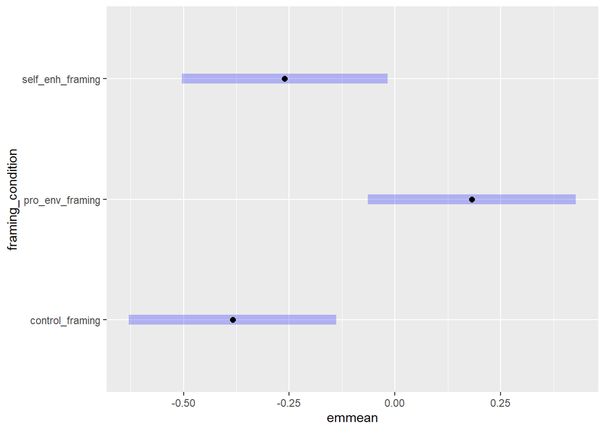

```r
# logit scale
plot(frame_emmeans_logit)
```

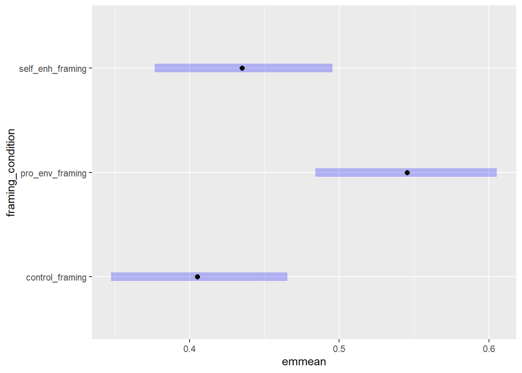

```r
# probability scale
plot(frame_emmeans_prob)
```

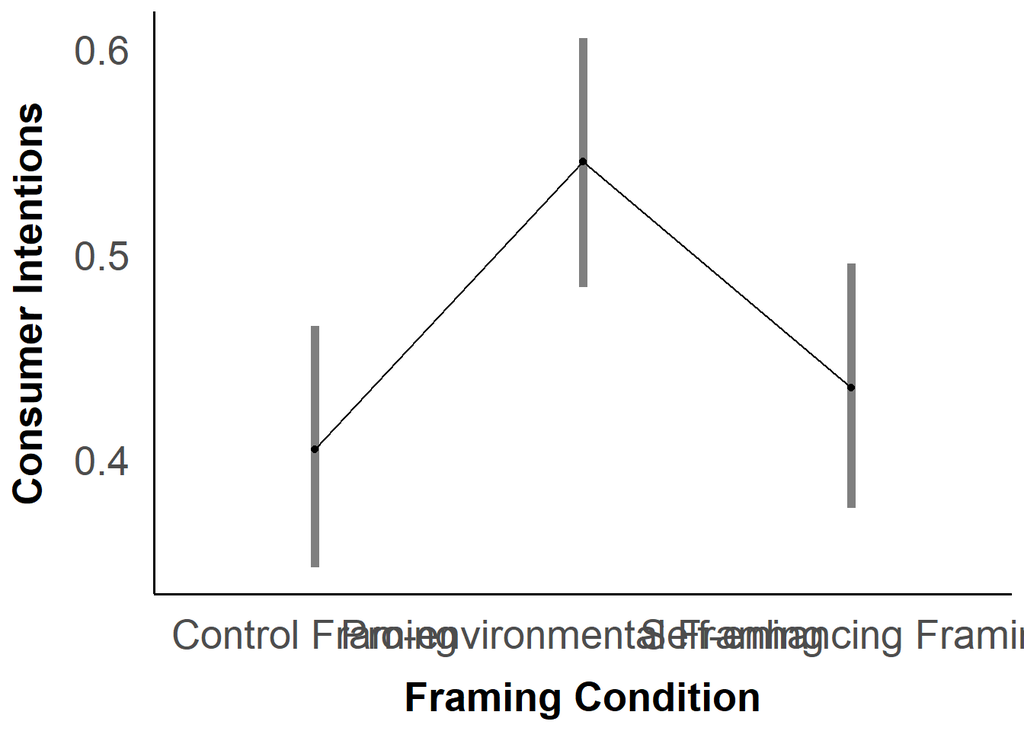

```r
emmip(log_mice, ~ framing_condition, type = "response", CIs = TRUE, CIarg = list(lwd = 2, alpha = 0.5), xlab = "Framing Condition", ylab = "Consumer Intentions") + scale_x_discrete(breaks=c("control_framing","pro_env_framing","self_enh_framing"),
        labels=c("Control Framing", "Pro-environmental Framing", "Self-enhancing Framing")) + theme_apa() + text_settings
```

Planned comparisons

```r
# custom contrasts
SE_F_EMM <- c(0,0,1)
C_F_EMM <- c(1,0,0)
PE_F_EMM <- c(0,1,0)

# logit scale
framing_comparisons <- contrast(frame_emmeans_logit,
                          method = list("SE Frame - Control Frame" = SE_F_EMM - C_F_EMM,
                                        "SE Frame - PE Frame" = SE_F_EMM - PE_F_EMM,
                                        "PE Frame - Control" = PE_F_EMM - C_F_EMM), adjust = "none")

framing_comparisons %>%
  knitr::kable(digits = c(NA,2,2,2,2,2,3))
```

| contrast | estimate | SE | df | z.ratio | p.value |
| --- | --- | --- | --- | --- | --- |
| SE Frame - Control Frame | 0.12 | 0.17 | Inf | 0.71 | 0.48 |
| SE Frame - PE Frame | -0.44 | 0.18 | Inf | -2.52 | 0.01 |
| PE Frame - Control | 0.57 | 0.17 | Inf | 3.25 | 0.00 |

```r
# confidence intervals
framing_comparisons %>% confint() %>%
  knitr::kable(digits = 2)
```

| contrast | estimate | SE | df | asymp.LCL | asymp.UCL |
| --- | --- | --- | --- | --- | --- |
| SE Frame - Control Frame | 0.12 | 0.17 | Inf | -0.22 | 0.46 |
| SE Frame - PE Frame | -0.44 | 0.18 | Inf | -0.79 | -0.10 |
| PE Frame - Control | 0.57 | 0.17 | Inf | 0.23 | 0.91 |

```r
# probability scale
framing_comparisons <- contrast(frame_emmeans_prob,
                          method = list("SE Frame - Control Frame" = SE_F_EMM - C_F_EMM,
                                        "SE Frame - PE Frame" = SE_F_EMM - PE_F_EMM,
                                        "PE Frame - Control" = PE_F_EMM - C_F_EMM), adjust = "none")

framing_comparisons %>%
  knitr::kable(digits = c(NA,2,2,2,2,2,3))
```

| contrast | odds.ratio | SE | df | null | z.ratio | p.value |
| --- | --- | --- | --- | --- | --- | --- |
| SE Frame / Control Frame | 1.13 | 0.20 | Inf | 1 | 0.71 | 0.479 |
| SE Frame / PE Frame | 0.64 | 0.11 | Inf | 1 | -2.52 | 0.012 |
| PE Frame / Control | 1.76 | 0.31 | Inf | 1 | 3.25 | 0.001 |

```r
# confidence intervals
framing_comparisons %>% confint() %>%
  knitr::kable(digits = 2)
```

| contrast | odds.ratio | SE | df | asymp.LCL | asymp.UCL |
| --- | --- | --- | --- | --- | --- |
| SE Frame / Control Frame | 1.13 | 0.20 | Inf | 0.80 | 1.59 |
| SE Frame / PE Frame | 0.64 | 0.11 | Inf | 0.46 | 0.91 |
| PE Frame / Control | 1.76 | 0.31 | Inf | 1.25 | 2.48 |

## Norm Condition

EM Means

```r
norm_emmeans_logit <- emmeans(log_mice, ~ norm_condition)
norm_emmeans_logit %>%
  knitr::kable(digits = 2)
```

| norm_condition | emmean | SE | df | asymp.LCL | asymp.UCL |
| --- | --- | --- | --- | --- | --- |
| control_norm | -0.32 | 0.16 | Inf | -0.63 | -0.01 |
| descriptive_norm | -0.05 | 0.16 | Inf | -0.37 | 0.27 |
| convention_norm | -0.18 | 0.16 | Inf | -0.49 | 0.13 |
| social_norm | -0.13 | 0.16 | Inf | -0.44 | 0.18 |
| moral_norm | -0.09 | 0.16 | Inf | -0.40 | 0.23 |

```r
norm_emmeans_prob <- emmeans(log_mice, ~ norm_condition, type = "response")
norm_emmeans_prob %>%
  knitr::kable(digits = 2)
```

| norm_condition | prob | SE | df | asymp.LCL | asymp.UCL |
| --- | --- | --- | --- | --- | --- |
| control_norm | 0.42 | 0.04 | Inf | 0.35 | 0.50 |
| descriptive_norm | 0.49 | 0.04 | Inf | 0.41 | 0.57 |
| convention_norm | 0.46 | 0.04 | Inf | 0.38 | 0.53 |
| social_norm | 0.47 | 0.04 | Inf | 0.39 | 0.54 |
| moral_norm | 0.48 | 0.04 | Inf | 0.40 | 0.56 |

Visualization

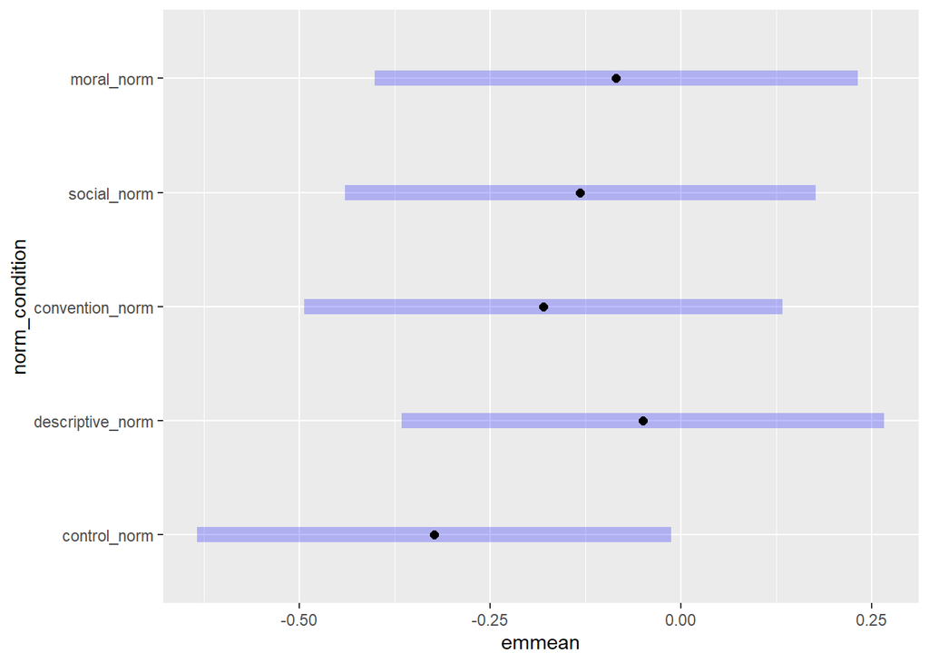

```r
# logit scale
plot(norm_emmeans_logit)
```

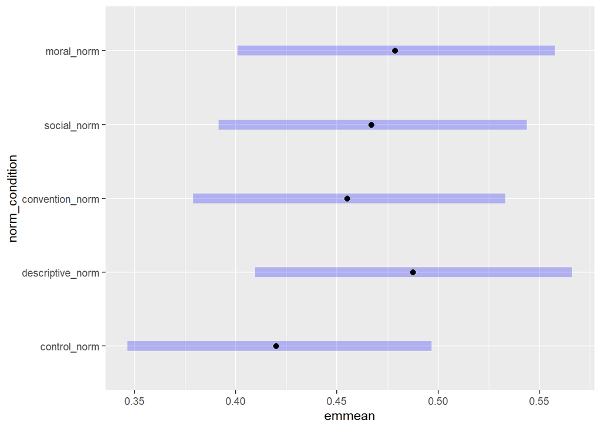

```r
# probability scale
plot(norm_emmeans_prob)
```

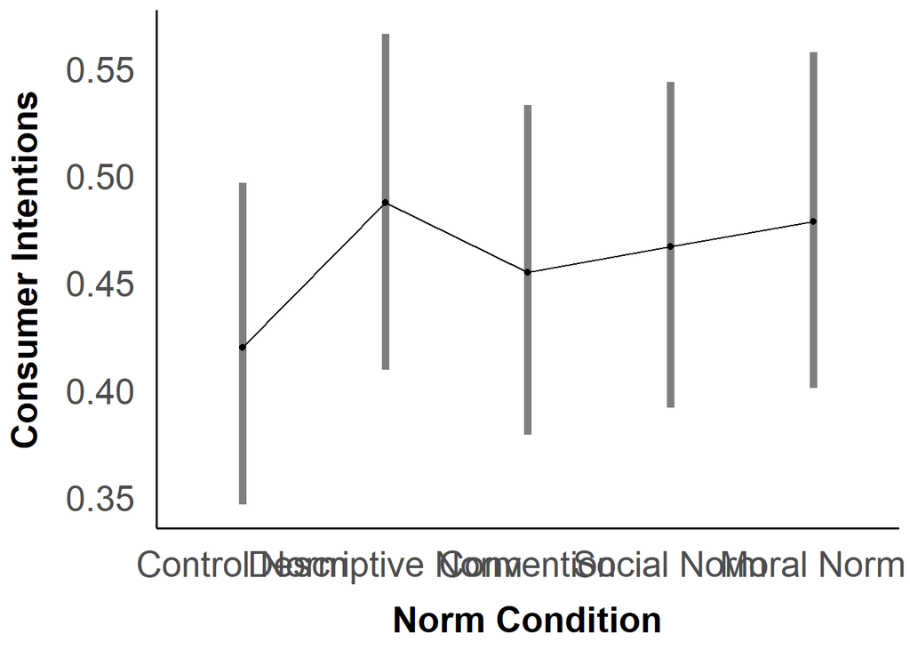

```r
emmip(log_mice, ~ norm_condition, type = "response", CIs = TRUE, CIarg = list(lwd = 2, alpha = 0.5), xlab = "Norm Condition", ylab = "Consumer Intentions") + scale_x_discrete(breaks=c("control_norm","descriptive_norm", "convention_norm", "social_norm", "moral_norm"),
        labels=c("Control Norm", "Descriptive Norm", "Convention", "Social Norm", "Moral Norm")) + theme_apa() + text_settings
```

Planned comparisons

```r
# custom contrasts
Control_N_EMM <- c(1,0,0,0,0)
DN_EMM <- c(0,1,0,0,0)
Conv_EMM <- c(0,0,1,0,0)
SN_EMM <- c(0,0,0,1,0)
MN_EMM <- c(0,0,0,0,1)

# logit scale
norm_comparisons <- contrast(norm_emmeans_logit,
                          method = list("Descriptive Norm - Control" = DN_EMM - Control_N_EMM,
                                        "Convention - Control" = Conv_EMM - Control_N_EMM,
                                        "Social Norm - Control" = SN_EMM - Control_N_EMM,
                                        "Moral Norm - Control" = MN_EMM - Control_N_EMM), adjust = "none")


norm_comparisons %>%
  knitr::kable(digits = c(NA,2,2,2,2,3))
```

| contrast | estimate | SE | df | z.ratio | p.value |
| --- | --- | --- | --- | --- | --- |
| Descriptive Norm - Control | 0.27 | 0.23 | Inf | 1.22 | 0.224 |
| Convention - Control | 0.14 | 0.22 | Inf | 0.65 | 0.518 |
| Social Norm - Control | 0.19 | 0.22 | Inf | 0.87 | 0.386 |
| Moral Norm - Control | 0.24 | 0.22 | Inf | 1.06 | 0.288 |

```r
# confidence intervals
norm_comparisons %>% confint() %>%
  knitr::kable(digits = 2)
```

| contrast | estimate | SE | df | asymp.LCL | asymp.UCL |
| --- | --- | --- | --- | --- | --- |
| Descriptive Norm - Control | 0.27 | 0.23 | Inf | -0.17 | 0.71 |
| Convention - Control | 0.14 | 0.22 | Inf | -0.29 | 0.58 |
| Social Norm - Control | 0.19 | 0.22 | Inf | -0.24 | 0.62 |
| Moral Norm - Control | 0.24 | 0.22 | Inf | -0.20 | 0.68 |

```r
# probability scale
norm_comparisons <- contrast(norm_emmeans_prob,
                          method = list("Descriptive Norm - Control" = DN_EMM - Control_N_EMM,
                                        "Convention - Control" = Conv_EMM - Control_N_EMM,
                                        "Social Norm - Control" = SN_EMM - Control_N_EMM,
                                        "Moral Norm - Control" = MN_EMM - Control_N_EMM), adjust = "none")


norm_comparisons %>%
  knitr::kable(digits = c(NA,2,2,2,2,2,3))
```

| contrast | odds.ratio | SE | df | null | z.ratio | p.value |
| --- | --- | --- | --- | --- | --- | --- |
| Descriptive Norm / Control | 1.31 | 0.30 | Inf | 1 | 1.22 | 0.224 |
| Convention / Control | 1.15 | 0.26 | Inf | 1 | 0.65 | 0.518 |
| Social Norm / Control | 1.21 | 0.27 | Inf | 1 | 0.87 | 0.386 |
| Moral Norm / Control | 1.27 | 0.28 | Inf | 1 | 1.06 | 0.288 |

```r
# confidence intervals
norm_comparisons %>% confint() %>%
  knitr::kable(digits = 2)
```

| contrast | odds.ratio | SE | df | asymp.LCL | asymp.UCL |
| --- | --- | --- | --- | --- | --- |
| Descriptive Norm / Control | 1.31 | 0.30 | Inf | 0.85 | 2.04 |
| Convention / Control | 1.15 | 0.26 | Inf | 0.75 | 1.78 |
| Social Norm / Control | 1.21 | 0.27 | Inf | 0.79 | 1.87 |
| Moral Norm / Control | 1.27 | 0.28 | Inf | 0.82 | 1.97 |

## Framing x Norm

EM Means

```r
cell_emmeans_logit <- emmeans(log_mice, ~ norm_condition*framing_condition)
cell_emmeans_logit %>%
  knitr::kable(digits = c(NA,NA,2,2,2,2,3))
```

| norm_condition | framing_condition | emmean | SE | df | asymp.LCL | asymp.UCL |
| --- | --- | --- | --- | --- | --- | --- |
| control_norm | control_framing | -0.18 | 0.26 | Inf | -0.69 | 0.336 |
| descriptive_norm | control_framing | -0.60 | 0.28 | Inf | -1.14 | -0.057 |
| convention_norm | control_framing | -0.29 | 0.29 | Inf | -0.85 | 0.281 |
| social_norm | control_framing | -0.54 | 0.24 | Inf | -1.01 | -0.077 |
| moral_norm | control_framing | -0.31 | 0.31 | Inf | -0.92 | 0.289 |
| control_norm | pro_env_framing | -0.24 | 0.27 | Inf | -0.76 | 0.279 |
| descriptive_norm | pro_env_framing | 0.50 | 0.31 | Inf | -0.12 | 1.110 |
| convention_norm | pro_env_framing | 0.11 | 0.25 | Inf | -0.37 | 0.598 |
| social_norm | pro_env_framing | 0.40 | 0.29 | Inf | -0.17 | 0.971 |
| moral_norm | pro_env_framing | 0.14 | 0.26 | Inf | -0.37 | 0.655 |
| control_norm | self_enh_framing | -0.55 | 0.29 | Inf | -1.11 | 0.009 |
| descriptive_norm | self_enh_framing | -0.05 | 0.25 | Inf | -0.53 | 0.440 |
| convention_norm | self_enh_framing | -0.37 | 0.29 | Inf | -0.94 | 0.198 |
| social_norm | self_enh_framing | -0.26 | 0.28 | Inf | -0.81 | 0.296 |
| moral_norm | self_enh_framing | -0.08 | 0.27 | Inf | -0.61 | 0.447 |

```r
cell_emmeans_prob <- emmeans(log_mice, ~ norm_condition*framing_condition, type = "response")
cell_emmeans_prob %>%
  knitr::kable(digits = c(NA,NA,2,2,2,2,3))
```

| norm_condition | framing_condition | prob | SE | df | asymp.LCL | asymp.UCL |
| --- | --- | --- | --- | --- | --- | --- |
| control_norm | control_framing | 0.46 | 0.07 | Inf | 0.33 | 0.583 |
| descriptive_norm | control_framing | 0.35 | 0.06 | Inf | 0.24 | 0.486 |
| convention_norm | control_framing | 0.43 | 0.07 | Inf | 0.30 | 0.570 |
| social_norm | control_framing | 0.37 | 0.06 | Inf | 0.27 | 0.481 |
| moral_norm | control_framing | 0.42 | 0.08 | Inf | 0.29 | 0.572 |
| control_norm | pro_env_framing | 0.44 | 0.07 | Inf | 0.32 | 0.569 |
| descriptive_norm | pro_env_framing | 0.62 | 0.07 | Inf | 0.47 | 0.752 |
| convention_norm | pro_env_framing | 0.53 | 0.06 | Inf | 0.41 | 0.645 |
| social_norm | pro_env_framing | 0.60 | 0.07 | Inf | 0.46 | 0.725 |
| moral_norm | pro_env_framing | 0.54 | 0.07 | Inf | 0.41 | 0.658 |
| control_norm | self_enh_framing | 0.37 | 0.07 | Inf | 0.25 | 0.502 |
| descriptive_norm | self_enh_framing | 0.49 | 0.06 | Inf | 0.37 | 0.608 |
| convention_norm | self_enh_framing | 0.41 | 0.07 | Inf | 0.28 | 0.549 |
| social_norm | self_enh_framing | 0.44 | 0.07 | Inf | 0.31 | 0.573 |
| moral_norm | self_enh_framing | 0.48 | 0.07 | Inf | 0.35 | 0.610 |

Visualization

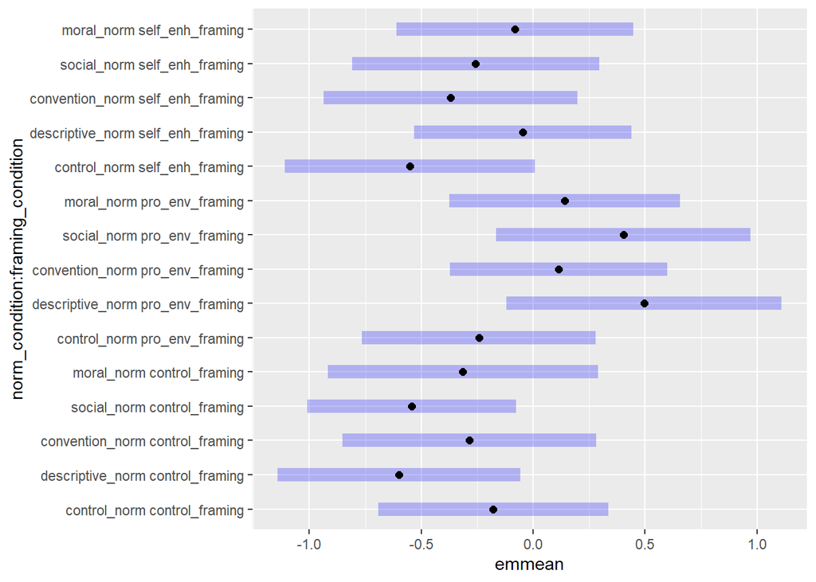

```r
plot(cell_emmeans_logit)
```

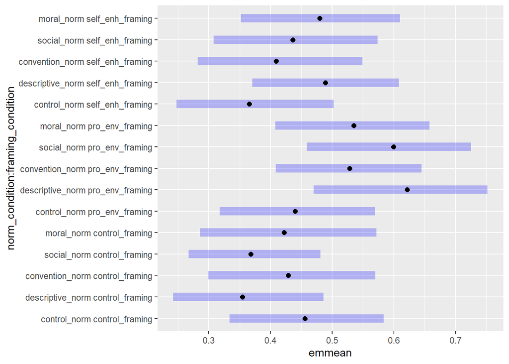

```r
plot(cell_emmeans_prob)
```

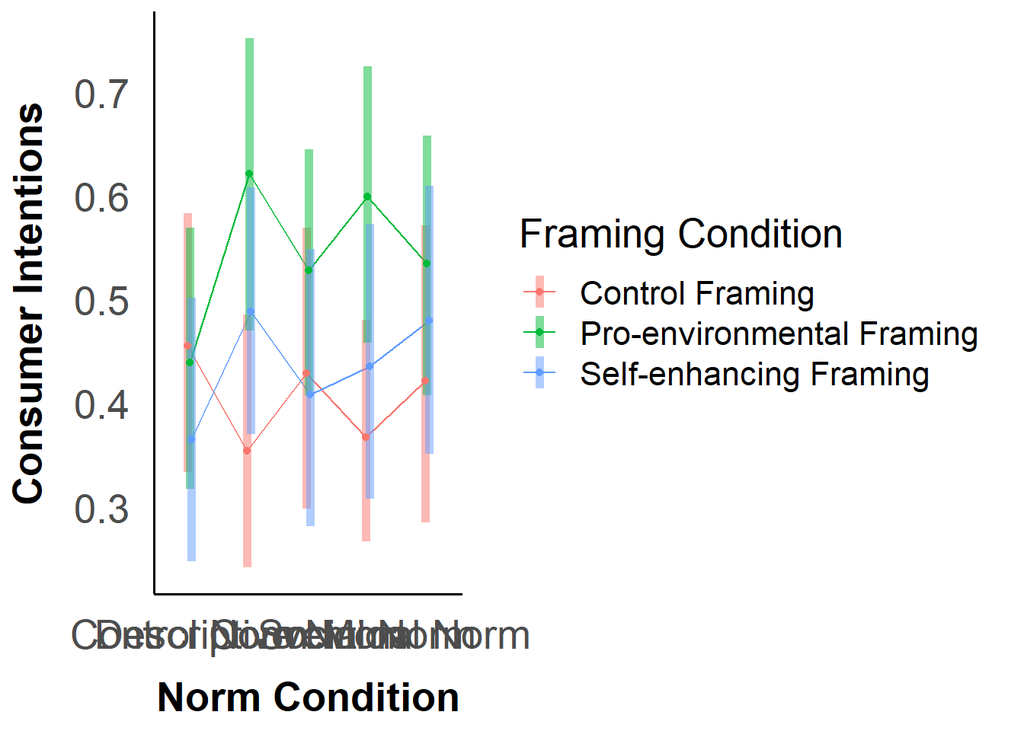

```r
emmip(log_mice, framing_condition ~ norm_condition, type = "response", CIs = TRUE, CIarg = list(lwd = 2, alpha = 0.5), xlab = "Norm Condition", ylab = "Consumer Intentions") + scale_x_discrete(breaks=c("control_norm","descriptive_norm", "convention_norm", "social_norm", "moral_norm"),
        labels=c("Control Norm", "Descriptive Norm", "Convention", "Social Norm", "Moral Norm")) + scale_colour_discrete(name = "Framing Condition", breaks=c("control_framing","pro_env_framing","self_enh_framing"), labels=c("Control Framing", "Pro-environmental Framing", "Self-enhancing Framing")) + theme_apa() + text_settings
```

Planned comparisons

```r
# custom contrasts
cf_cn_emm <- c(1,rep(0,14)) ## control framings
cf_dn_emm <- c(0,1,rep(0,13))
cf_conv_emm <- c(0,0,1,rep(0,12))
cf_sn_emm <- c(0,0,0,1,rep(0,11))
cf_mn_emm <- c(0,0,0,0,1,rep(0,10))

pf_cn_emm <- c(0,0,0,0,0,1,rep(0,9)) ## pro-environmental framings
pf_dn_emm <- c(0,0,0,0,0,0,1,rep(0,8))
pf_conv_emm <- c(rep(0,7),1,(rep(0,7)))
pf_sn_emm <- c(rep(0,8),1,(rep(0,6)))
pf_mn_emm <- c(rep(0,9),1,(rep(0,5)))

sf_cn_emm <- c(rep(0,10),1,(rep(0,4))) ## self-enhancing framings
sf_dn_emm <- c(rep(0,11),1,(rep(0,3)))
sf_conv_emm <- c(rep(0,12),1,(rep(0,2)))
sf_sn_emm <- c(rep(0,13),1,0)
sf_mn_emm <- c(rep(0,14),1)


# logit scale
FxN_comparisons <- contrast(cell_emmeans_logit,
                          method = list("Control Frame + DN - Control Frame + Ctrl" = cf_dn_emm - cf_cn_emm,
                                        "Control Frame + Conv - Control Frame + Ctrl" = cf_conv_emm - cf_cn_emm,
                                        "Control Frame + SN - Control Frame + Ctrl" = cf_sn_emm - cf_cn_emm,
                                        "Control Frame + MN - Control Frame + Ctrl" = cf_mn_emm - cf_cn_emm,
                                        "PE Frame + DN - PE Frame + Ctrl" = pf_dn_emm - pf_cn_emm,
                                        "PE Frame + Conv - PE Frame + Ctrl" = pf_conv_emm - pf_cn_emm,
                                        "PE Frame + SN - PE Frame + Ctrl" = pf_sn_emm - pf_cn_emm,
                                        "PE Frame + MN - PE Frame + Ctrl" = pf_mn_emm - pf_cn_emm,
                                        "SE Frame + DN - SE Frame + Ctrl" = sf_dn_emm - sf_cn_emm,
                                        "SE Frame + Conv - SE Frame + Ctrl" = sf_conv_emm - sf_cn_emm,
                                        "SE Frame + SN - SE Frame + Ctrl" = sf_sn_emm - sf_cn_emm,
                                        "SE Frame + MN - SE Frame + Ctrl" = sf_mn_emm - sf_cn_emm), adjust = "none")

FxN_comparisons %>%
  knitr::kable(digits = c(NA,2,2,2,2,3))
```

| contrast | estimate | SE | df | z.ratio | p.value |
| --- | --- | --- | --- | --- | --- |
| Control Frame + DN - Control Frame + Ctrl | -0.42 | 0.38 | Inf | -1.11 | 0.266 |
| Control Frame + Conv - Control Frame + Ctrl | -0.11 | 0.39 | Inf | -0.28 | 0.782 |
| Control Frame + SN - Control Frame + Ctrl | -0.36 | 0.35 | Inf | -1.03 | 0.301 |
| Control Frame + MN - Control Frame + Ctrl | -0.14 | 0.40 | Inf | -0.34 | 0.735 |
| PE Frame + DN - PE Frame + Ctrl | 0.74 | 0.41 | Inf | 1.80 | 0.072 |
| PE Frame + Conv - PE Frame + Ctrl | 0.36 | 0.36 | Inf | 0.98 | 0.326 |
| PE Frame + SN - PE Frame + Ctrl | 0.64 | 0.39 | Inf | 1.64 | 0.100 |
| PE Frame + MN - PE Frame + Ctrl | 0.38 | 0.37 | Inf | 1.03 | 0.305 |
| SE Frame + DN - SE Frame + Ctrl | 0.51 | 0.38 | Inf | 1.34 | 0.180 |
| SE Frame + Conv - SE Frame + Ctrl | 0.18 | 0.40 | Inf | 0.45 | 0.653 |
| SE Frame + SN - SE Frame + Ctrl | 0.29 | 0.40 | Inf | 0.73 | 0.464 |
| SE Frame + MN - SE Frame + Ctrl | 0.47 | 0.39 | Inf | 1.19 | 0.232 |

```r
# confidence intervals
FxN_comparisons %>% confint() %>%
  knitr::kable(digits = 2)
```

| contrast | estimate | SE | df | asymp.LCL | asymp.UCL |
| --- | --- | --- | --- | --- | --- |
| Control Frame + DN - Control Frame + Ctrl | -0.42 | 0.38 | Inf | -1.16 | 0.32 |
| Control Frame + Conv - Control Frame + Ctrl | -0.11 | 0.39 | Inf | -0.87 | 0.66 |
| Control Frame + SN - Control Frame + Ctrl | -0.36 | 0.35 | Inf | -1.06 | 0.33 |
| Control Frame + MN - Control Frame + Ctrl | -0.14 | 0.40 | Inf | -0.93 | 0.65 |
| PE Frame + DN - PE Frame + Ctrl | 0.74 | 0.41 | Inf | -0.07 | 1.54 |
| PE Frame + Conv - PE Frame + Ctrl | 0.36 | 0.36 | Inf | -0.35 | 1.07 |
| PE Frame + SN - PE Frame + Ctrl | 0.64 | 0.39 | Inf | -0.12 | 1.41 |
| PE Frame + MN - PE Frame + Ctrl | 0.38 | 0.37 | Inf | -0.35 | 1.11 |
| SE Frame + DN - SE Frame + Ctrl | 0.51 | 0.38 | Inf | -0.23 | 1.24 |
| SE Frame + Conv - SE Frame + Ctrl | 0.18 | 0.40 | Inf | -0.61 | 0.97 |
| SE Frame + SN - SE Frame + Ctrl | 0.29 | 0.40 | Inf | -0.49 | 1.08 |
| SE Frame + MN - SE Frame + Ctrl | 0.47 | 0.39 | Inf | -0.30 | 1.24 |

```r
# probability scale
FxN_comparisons <- contrast(cell_emmeans_prob,
                          method = list("Control Frame + DN - Control Frame + Ctrl" = cf_dn_emm - cf_cn_emm,
                                        "Control Frame + Conv - Control Frame + Ctrl" = cf_conv_emm - cf_cn_emm,
                                        "Control Frame + SN - Control Frame + Ctrl" = cf_sn_emm - cf_cn_emm,
                                        "Control Frame + MN - Control Frame + Ctrl" = cf_mn_emm - cf_cn_emm,
                                        "PE Frame + DN - PE Frame + Ctrl" = pf_dn_emm - pf_cn_emm,
                                        "PE Frame + Conv - PE Frame + Ctrl" = pf_conv_emm - pf_cn_emm,
                                        "PE Frame + SN - PE Frame + Ctrl" = pf_sn_emm - pf_cn_emm,
                                        "PE Frame + MN - PE Frame + Ctrl" = pf_mn_emm - pf_cn_emm,
                                        "SE Frame + DN - SE Frame + Ctrl" = sf_dn_emm - sf_cn_emm,
                                        "SE Frame + Conv - SE Frame + Ctrl" = sf_conv_emm - sf_cn_emm,
                                        "SE Frame + SN - SE Frame + Ctrl" = sf_sn_emm - sf_cn_emm,
                                        "SE Frame + MN - SE Frame + Ctrl" = sf_mn_emm - sf_cn_emm), adjust = "none")

FxN_comparisons %>%
  knitr::kable(digits = c(NA,2,2,2,2,3))
```

| contrast | odds.ratio | SE | df | null | z.ratio | p.value |
| --- | --- | --- | --- | --- | --- | --- |
| Control Frame + DN / Control Frame + Ctrl | 0.66 | 0.25 | Inf | 1 | -1.113 | NA |
| Control Frame + Conv / Control Frame + Ctrl | 0.90 | 0.35 | Inf | 1 | -0.277 | NA |
| Control Frame + SN / Control Frame + Ctrl | 0.69 | 0.24 | Inf | 1 | -1.035 | NA |
| Control Frame + MN / Control Frame + Ctrl | 0.87 | 0.35 | Inf | 1 | -0.338 | NA |
| PE Frame + DN / PE Frame + Ctrl | 2.09 | 0.86 | Inf | 1 | 1.796 | NA |
| PE Frame + Conv / PE Frame + Ctrl | 1.43 | 0.52 | Inf | 1 | 0.981 | NA |
| PE Frame + SN / PE Frame + Ctrl | 1.91 | 0.75 | Inf | 1 | 1.643 | NA |
| PE Frame + MN / PE Frame + Ctrl | 1.47 | 0.55 | Inf | 1 | 1.026 | NA |
| SE Frame + DN / SE Frame + Ctrl | 1.66 | 0.62 | Inf | 1 | 1.342 | NA |
| SE Frame + Conv / SE Frame + Ctrl | 1.20 | 0.48 | Inf | 1 | 0.450 | NA |
| SE Frame + SN / SE Frame + Ctrl | 1.34 | 0.54 | Inf | 1 | 0.733 | NA |
| SE Frame + MN / SE Frame + Ctrl | 1.60 | 0.63 | Inf | 1 | 1.194 | NA |

```r
# confidence intervals
FxN_comparisons %>% confint() %>%
  knitr::kable(digits = 2)
```

| contrast | odds.ratio | SE | df | asymp.LCL | asymp.UCL |
| --- | --- | --- | --- | --- | --- |
| Control Frame + DN / Control Frame + Ctrl | 0.66 | 0.25 | Inf | 0.31 | 1.38 |
| Control Frame + Conv / Control Frame + Ctrl | 0.90 | 0.35 | Inf | 0.42 | 1.93 |
| Control Frame + SN / Control Frame + Ctrl | 0.69 | 0.24 | Inf | 0.35 | 1.39 |
| Control Frame + MN / Control Frame + Ctrl | 0.87 | 0.35 | Inf | 0.40 | 1.92 |
| PE Frame + DN / PE Frame + Ctrl | 2.09 | 0.86 | Inf | 0.94 | 4.67 |
| PE Frame + Conv / PE Frame + Ctrl | 1.43 | 0.52 | Inf | 0.70 | 2.90 |
| PE Frame + SN / PE Frame + Ctrl | 1.91 | 0.75 | Inf | 0.88 | 4.11 |
| PE Frame + MN / PE Frame + Ctrl | 1.47 | 0.55 | Inf | 0.71 | 3.05 |
| SE Frame + DN / SE Frame + Ctrl | 1.66 | 0.62 | Inf | 0.79 | 3.47 |
| SE Frame + Conv / SE Frame + Ctrl | 1.20 | 0.48 | Inf | 0.54 | 2.64 |
| SE Frame + SN / SE Frame + Ctrl | 1.34 | 0.54 | Inf | 0.61 | 2.94 |
| SE Frame + MN / SE Frame + Ctrl | 1.60 | 0.63 | Inf | 0.74 | 3.45 |

## Exploratory RQ2: Cell differences from control

> > Exploratory RQ2: Which combination of framing and norm condition produced the strongest reductions in consumer intentions compared to the control condition?

```r
# custom contrasts
cf_cn_emm <- c(1,rep(0,14)) ## control framings
cf_dn_emm <- c(0,1,rep(0,13))
cf_conv_emm <- c(0,0,1,rep(0,12))
cf_sn_emm <- c(0,0,0,1,rep(0,11))
cf_mn_emm <- c(0,0,0,0,1,rep(0,10))

pf_cn_emm <- c(0,0,0,0,0,1,rep(0,9)) ## pro-environmental framings
pf_dn_emm <- c(0,0,0,0,0,0,1,rep(0,8))
pf_conv_emm <- c(rep(0,7),1,(rep(0,7)))
pf_sn_emm <- c(rep(0,8),1,(rep(0,6)))
pf_mn_emm <- c(rep(0,9),1,(rep(0,5)))

sf_cn_emm <- c(rep(0,10),1,(rep(0,4))) ## self-enhancing framings
sf_dn_emm <- c(rep(0,11),1,(rep(0,3)))
sf_conv_emm <- c(rep(0,12),1,(rep(0,2)))
sf_sn_emm <- c(rep(0,13),1,0)
sf_mn_emm <- c(rep(0,14),1)



# logit scale
RQ2 <- contrast(cell_emmeans_logit,
                          method = list("Pro-env Frame + Control vs Control" = pf_cn_emm - cf_cn_emm,
                                        "Pro-env Frame + DN vs Control" = pf_dn_emm - cf_cn_emm,
                                        "Pro-env Frame + Conv vs Control" = pf_conv_emm - cf_cn_emm,
                                        "Pro-env Frame + SN vs Control" = pf_sn_emm - cf_cn_emm,
                                        "Pro-env Frame + MN vs Control" = pf_mn_emm - cf_cn_emm,
                                        "Self-enh Frame + Control vs Control" = sf_cn_emm - cf_cn_emm,
                                        "Self-enh Frame + DN vs Control" = sf_dn_emm - cf_cn_emm,
                                        "Self-enh Frame + Conv vs Control" = sf_conv_emm - cf_cn_emm,
                                        "Self-enh Frame + SN vs Control" = sf_sn_emm - cf_cn_emm,
                                        "Self-enh Frame + MN vs Control" = sf_mn_emm - cf_cn_emm), adjust = "sidak")

RQ2 %>%
  knitr::kable(digits = c(NA,2,2,2,2,3))
```

| contrast | estimate | SE | df | z.ratio | p.value |
| --- | --- | --- | --- | --- | --- |
| Pro-env Frame + Control vs Control | -0.06 | 0.37 | Inf | -0.17 | 1.000 |
| Pro-env Frame + DN vs Control | 0.67 | 0.41 | Inf | 1.64 | 0.659 |
| Pro-env Frame + Conv vs Control | 0.29 | 0.36 | Inf | 0.81 | 0.996 |
| Pro-env Frame + SN vs Control | 0.58 | 0.39 | Inf | 1.49 | 0.771 |
| Pro-env Frame + MN vs Control | 0.32 | 0.37 | Inf | 0.86 | 0.993 |
| Self-enh Frame + Control vs Control | -0.37 | 0.39 | Inf | -0.96 | 0.983 |
| Self-enh Frame + DN vs Control | 0.13 | 0.36 | Inf | 0.37 | 1.000 |
| Self-enh Frame + Conv vs Control | -0.19 | 0.38 | Inf | -0.50 | 1.000 |
| Self-enh Frame + SN vs Control | -0.08 | 0.38 | Inf | -0.21 | 1.000 |
| Self-enh Frame + MN vs Control | 0.10 | 0.38 | Inf | 0.25 | 1.000 |

```r
# confidence intervals
RQ2 %>% confint() %>%
  knitr::kable(digits = 2)
```

| contrast | estimate | SE | df | asymp.LCL | asymp.UCL |
| --- | --- | --- | --- | --- | --- |
| Pro-env Frame + Control vs Control | -0.06 | 0.37 | Inf | -1.10 | 0.97 |
| Pro-env Frame + DN vs Control | 0.67 | 0.41 | Inf | -0.48 | 1.83 |
| Pro-env Frame + Conv vs Control | 0.29 | 0.36 | Inf | -0.72 | 1.30 |
| Pro-env Frame + SN vs Control | 0.58 | 0.39 | Inf | -0.51 | 1.67 |
| Pro-env Frame + MN vs Control | 0.32 | 0.37 | Inf | -0.71 | 1.35 |
| Self-enh Frame + Control vs Control | -0.37 | 0.39 | Inf | -1.45 | 0.71 |
| Self-enh Frame + DN vs Control | 0.13 | 0.36 | Inf | -0.88 | 1.14 |
| Self-enh Frame + Conv vs Control | -0.19 | 0.38 | Inf | -1.26 | 0.88 |
| Self-enh Frame + SN vs Control | -0.08 | 0.38 | Inf | -1.15 | 1.00 |
| Self-enh Frame + MN vs Control | 0.10 | 0.38 | Inf | -0.96 | 1.15 |

```r
# probability scale
RQ2 <- contrast(cell_emmeans_prob,
                          method = list("Pro-env Frame + Control vs Control" = pf_cn_emm - cf_cn_emm,
                                        "Pro-env Frame + DN vs Control" = pf_dn_emm - cf_cn_emm,
                                        "Pro-env Frame + Conv vs Control" = pf_conv_emm - cf_cn_emm,
                                        "Pro-env Frame + SN vs Control" = pf_sn_emm - cf_cn_emm,
                                        "Pro-env Frame + MN vs Control" = pf_mn_emm - cf_cn_emm,
                                        "Self-enh Frame + Control vs Control" = sf_cn_emm - cf_cn_emm,
                                        "Self-enh Frame + DN vs Control" = sf_dn_emm - cf_cn_emm,
                                        "Self-enh Frame + Conv vs Control" = sf_conv_emm - cf_cn_emm,
                                        "Self-enh Frame + SN vs Control" = sf_sn_emm - cf_cn_emm,
                                        "Self-enh Frame + MN vs Control" = sf_mn_emm - cf_cn_emm), adjust = "sidak")

RQ2 %>%
  knitr::kable(digits = c(NA,2,2,2,2,3))
```

| contrast | odds.ratio | SE | df | null | z.ratio | p.value |
| --- | --- | --- | --- | --- | --- | --- |
| Pro-env Frame + Control vs Control | 0.94 | 0.35 | Inf | 1 | -0.173 | NA |
| Pro-env Frame + DN vs Control | 1.96 | 0.81 | Inf | 1 | 1.636 | NA |
| Pro-env Frame + Conv vs Control | 1.34 | 0.48 | Inf | 1 | 0.810 | NA |
| Pro-env Frame + SN vs Control | 1.79 | 0.70 | Inf | 1 | 1.487 | NA |
| Pro-env Frame + MN vs Control | 1.38 | 0.51 | Inf | 1 | 0.864 | NA |
| Self-enh Frame + Control vs Control | 0.69 | 0.27 | Inf | 1 | -0.965 | NA |
| Self-enh Frame + DN vs Control | 1.14 | 0.41 | Inf | 1 | 0.368 | NA |
| Self-enh Frame + Conv vs Control | 0.83 | 0.32 | Inf | 1 | -0.498 | NA |
| Self-enh Frame + SN vs Control | 0.92 | 0.35 | Inf | 1 | -0.205 | NA |
| Self-enh Frame + MN vs Control | 1.10 | 0.42 | Inf | 1 | 0.254 | NA |

```r
# confidence intervals
RQ2 %>% confint() %>%
  knitr::kable(digits = 2)
```

| contrast | odds.ratio | SE | df | asymp.LCL | asymp.UCL |
| --- | --- | --- | --- | --- | --- |
| Pro-env Frame + Control vs Control | 0.94 | 0.35 | Inf | 0.33 | 2.65 |
| Pro-env Frame + DN vs Control | 1.96 | 0.81 | Inf | 0.62 | 6.20 |
| Pro-env Frame + Conv vs Control | 1.34 | 0.48 | Inf | 0.49 | 3.66 |
| Pro-env Frame + SN vs Control | 1.79 | 0.70 | Inf | 0.60 | 5.33 |
| Pro-env Frame + MN vs Control | 1.38 | 0.51 | Inf | 0.49 | 3.86 |
| Self-enh Frame + Control vs Control | 0.69 | 0.27 | Inf | 0.23 | 2.03 |
| Self-enh Frame + DN vs Control | 1.14 | 0.41 | Inf | 0.42 | 3.13 |
| Self-enh Frame + Conv vs Control | 0.83 | 0.32 | Inf | 0.28 | 2.42 |
| Self-enh Frame + SN vs Control | 0.92 | 0.35 | Inf | 0.32 | 2.71 |
| Self-enh Frame + MN vs Control | 1.10 | 0.42 | Inf | 0.38 | 3.17 |

# Values and Ingroup Interactions

> > H4: There will be a three-way interaction between values (biospheric, egoistic, altruistic, hedonic), framing condition, & norm condition such that when a pro-environmental or control framing is used, values will moderate the effect of each norm condition, but not when a self-enhancing framing is used.

Labels to use with facet_wrap

```r
norm_labs <- c("Control Norm", "Descriptive Norm", "Convention", "Social Norm", "Moral Norm")
names(norm_labs) <- c("control_norm","descriptive_norm", "convention_norm", "social_norm", "moral_norm")

frame_labs <- c("Control Framing", "Pro-environmental Framing", "Self-enhancing Framing")
names(frame_labs) <- c("control_framing","pro_env_framing","self_enh_framing")
```

Averaging scores across imputations

```r
complete_data_subset <- complete_data %>%
  dplyr::select(.imp, .id, consumer_intentions, consumer_behaviors, Gender, framing_condition, norm_condition, biospheric_center, altruistic_center, egoistic_center, hedonic_center, ingroup_center, Age_center, clothing_center, self_dec_center, impress_manag_center)

average_df <- complete_data_subset %>%
  group_by(.id) %>%
  transmute(.imp = .imp,
            consumer_behaviors = consumer_behaviors,
            Gender = Gender,
            framing_condition = framing_condition,
            norm_condition = norm_condition,
            biospheric_center = mean(biospheric_center),
         altruistic_center = mean(altruistic_center),
         egoistic_center = mean(egoistic_center),
         hedonic_center = mean(hedonic_center),
         ingroup_center = mean(ingroup_center),
         Age_center = mean(Age_center),
         clothing_center = mean(clothing_center),
         self_dec_center = mean(self_dec_center),
         impress_manag_center = mean(impress_manag_center),
         consumer_intentions = mean(consumer_intentions))


average_df <- average_df %>%
  filter(.imp == 1)
```

## Biospheric values

Is the difference between Control Norm and Other Norm different for people low vs high on biospheric values? Does this vary across framing conditions?

### Visualization

```r
text_settings <- theme(text = element_text(size = 20)) +
  theme(plot.title = element_text(size = 20, face = 'bold')) +
  theme(axis.title.x = element_text(face = 'bold')) +
  theme(axis.title.y = element_text(face = 'bold')) +
  theme(axis.text.x = element_text(size = 14)) +
  theme(axis.text.y = element_text(size = 20)) +
  theme(axis.ticks = element_blank())
```

#### Bio x Framing

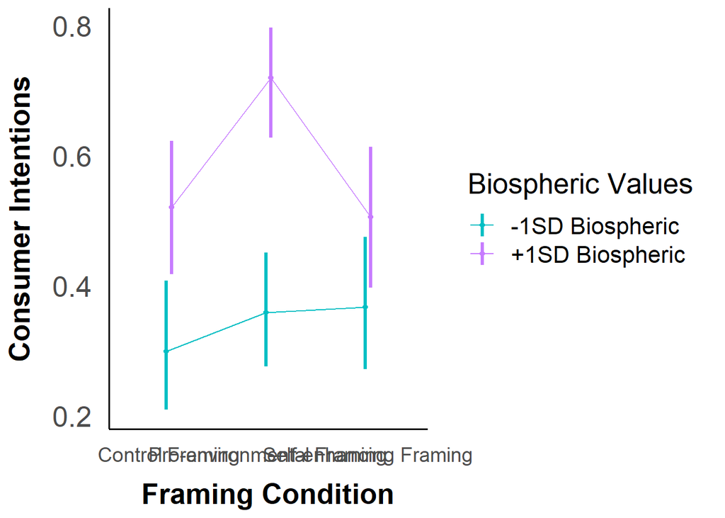

```r
sd_below <- mean(average_df$biospheric_center) - sd(average_df$biospheric_center)
sd_above <- mean(average_df$biospheric_center) + sd(average_df$biospheric_center)

at_list <- list(biospheric_center = c(sd_below, sd_above))

emmip(log_mice, biospheric_center ~ framing_condition, type = "response", CIs = TRUE, CIarg = list(lwd = 1.2, alpha = 1), xlab = "Framing Condition", ylab = "Consumer Intentions", at = at_list) +
  scale_x_discrete(breaks=c("control_framing","pro_env_framing", "self_enh_framing"), labels = c("Control Framing", "Pro-environmental Framing", "Self-enhancing Framing")) +
  theme_apa() +
  text_settings +
  scale_color_manual(name = "Biospheric Values", breaks = c(-0.992493391146803, 0.992493391146803), labels = c("-1SD Biospheric", "+1SD Biospheric"), values = c("#00BFC4","#C77CFF"))
```

#### Bio x Norm

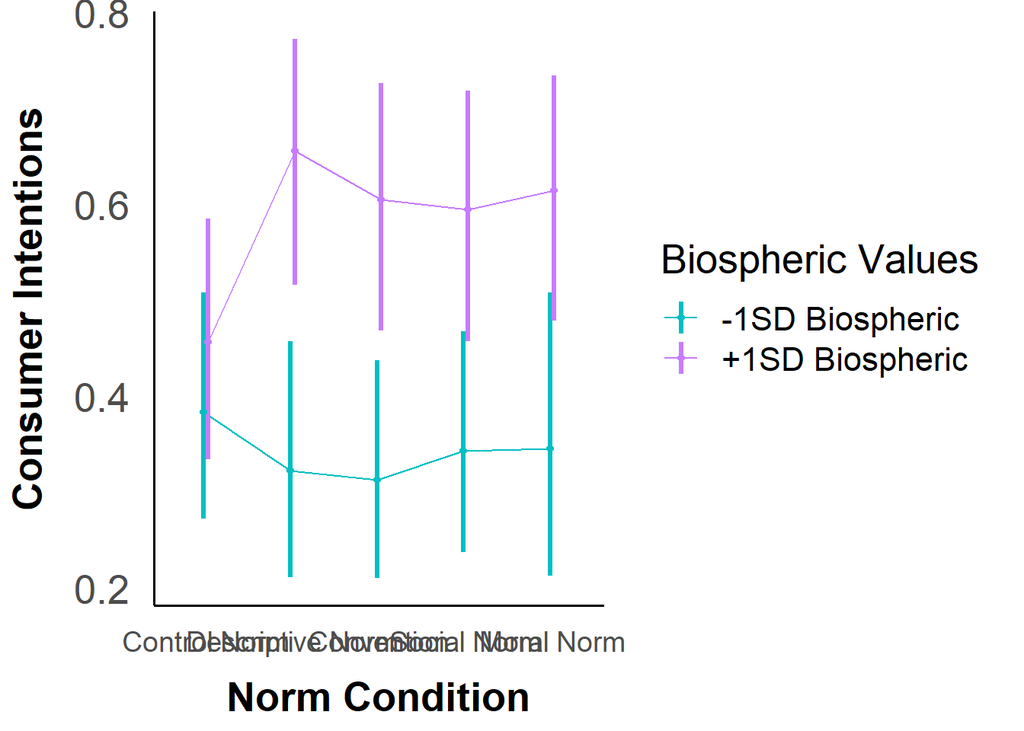

```r
emmip(log_mice, biospheric_center ~ norm_condition, type = "response", CIs = TRUE, CIarg = list(lwd = 1.2, alpha = 1), xlab = "Norm Condition", ylab = "Consumer Intentions", at = at_list) +
  scale_x_discrete(breaks=c("control_norm","descriptive_norm", "convention_norm", "social_norm", "moral_norm"), labels = c("Control Norm", "Descriptive Norm", "Convention", "Social Norm", "Moral Norm")) +
  theme_apa() +
  text_settings +
  scale_color_manual(name = "Biospheric Values", breaks = c(-0.992493391146803, 0.992493391146803), labels = c("-1SD Biospheric", "+1SD Biospheric"), values = c("#00BFC4","#C77CFF"))
```

#### Bio, Framing, & Norm

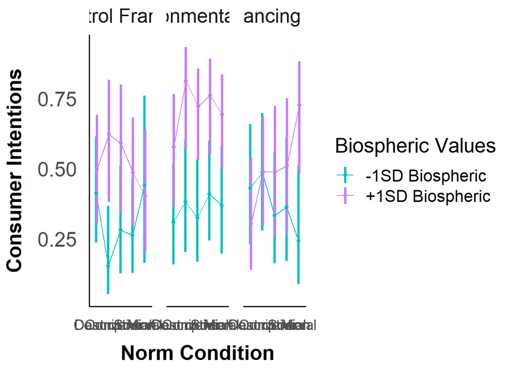

```r
emmip(log_mice, biospheric_center ~ norm_condition | framing_condition, type = "response", CIs = TRUE, CIarg = list(lwd = 1.2, alpha = 1), xlab = "Norm Condition", ylab = "Consumer Intentions", at = at_list) +
  scale_x_discrete(breaks=c("control_norm","descriptive_norm", "convention_norm", "social_norm", "moral_norm"), labels = c("Control", "Descriptive", "Convention", "Social", "Moral")) +
  facet_wrap(~framing_condition, labeller = labeller(framing_condition = frame_labs)) +
  theme_apa() +
  text_settings +
  scale_color_manual(name = "Biospheric Values", breaks = c(-0.992493391146803, 0.992493391146803), labels = c("-1SD Biospheric", "+1SD Biospheric"), values = c("#00BFC4","#C77CFF"))
```

### Planned Comparisons

#### Storing low (-1SD) and high (+1SD) biospheric values

```r
sd_below <- mean(average_df$biospheric_center) - sd(average_df$biospheric_center)
sd_above <- mean(average_df$biospheric_center) + sd(average_df$biospheric_center)
```

#### Calculate EM Means at low and high bio

```r
atlist <- list(biospheric_center = c(sd_below, sd_above))

combinations <- emmeans(log_mice, ~ norm_condition*biospheric_center*framing_condition, at=atlist, type = "response")

combinations %>% knitr::kable(digits = 2)
```

| norm_condition | biospheric_center | framing_condition | prob | SE | df | asymp.LCL | asymp.UCL |
| --- | --- | --- | --- | --- | --- | --- | --- |
| control_norm | -0.99 | control_framing | 0.41 | 0.10 | Inf | 0.24 | 0.62 |
| descriptive_norm | -0.99 | control_framing | 0.15 | 0.08 | Inf | 0.05 | 0.37 |
| convention_norm | -0.99 | control_framing | 0.28 | 0.10 | Inf | 0.13 | 0.51 |
| social_norm | -0.99 | control_framing | 0.26 | 0.09 | Inf | 0.13 | 0.46 |
| moral_norm | -0.99 | control_framing | 0.44 | 0.18 | Inf | 0.16 | 0.76 |
| control_norm | 0.99 | control_framing | 0.50 | 0.10 | Inf | 0.31 | 0.69 |
| descriptive_norm | 0.99 | control_framing | 0.62 | 0.12 | Inf | 0.38 | 0.82 |
| convention_norm | 0.99 | control_framing | 0.59 | 0.13 | Inf | 0.34 | 0.80 |
| social_norm | 0.99 | control_framing | 0.49 | 0.10 | Inf | 0.29 | 0.68 |
| moral_norm | 0.99 | control_framing | 0.40 | 0.12 | Inf | 0.20 | 0.64 |
| control_norm | -0.99 | pro_env_framing | 0.31 | 0.09 | Inf | 0.16 | 0.52 |
| descriptive_norm | -0.99 | pro_env_framing | 0.38 | 0.11 | Inf | 0.20 | 0.60 |
| convention_norm | -0.99 | pro_env_framing | 0.33 | 0.10 | Inf | 0.17 | 0.53 |
| social_norm | -0.99 | pro_env_framing | 0.41 | 0.09 | Inf | 0.24 | 0.60 |
| moral_norm | -0.99 | pro_env_framing | 0.37 | 0.10 | Inf | 0.20 | 0.58 |
| control_norm | 0.99 | pro_env_framing | 0.58 | 0.11 | Inf | 0.36 | 0.77 |
| descriptive_norm | 0.99 | pro_env_framing | 0.81 | 0.09 | Inf | 0.57 | 0.93 |
| convention_norm | 0.99 | pro_env_framing | 0.72 | 0.08 | Inf | 0.53 | 0.86 |
| social_norm | 0.99 | pro_env_framing | 0.76 | 0.09 | Inf | 0.55 | 0.89 |
| moral_norm | 0.99 | pro_env_framing | 0.69 | 0.09 | Inf | 0.50 | 0.84 |
| control_norm | -0.99 | self_enh_framing | 0.43 | 0.12 | Inf | 0.23 | 0.66 |
| descriptive_norm | -0.99 | self_enh_framing | 0.49 | 0.11 | Inf | 0.28 | 0.70 |
| convention_norm | -0.99 | self_enh_framing | 0.33 | 0.11 | Inf | 0.16 | 0.56 |
| social_norm | -0.99 | self_enh_framing | 0.36 | 0.12 | Inf | 0.17 | 0.61 |
| moral_norm | -0.99 | self_enh_framing | 0.24 | 0.11 | Inf | 0.09 | 0.51 |
| control_norm | 0.99 | self_enh_framing | 0.30 | 0.11 | Inf | 0.14 | 0.54 |
| descriptive_norm | 0.99 | self_enh_framing | 0.49 | 0.11 | Inf | 0.30 | 0.69 |
| convention_norm | 0.99 | self_enh_framing | 0.49 | 0.13 | Inf | 0.26 | 0.72 |
| social_norm | 0.99 | self_enh_framing | 0.51 | 0.14 | Inf | 0.27 | 0.75 |
| moral_norm | 0.99 | self_enh_framing | 0.73 | 0.11 | Inf | 0.48 | 0.88 |

#### Custom contrasts

```r
cf_cn_low_bio <- c(1, rep(0,29)) # control framing
cf_dn_low_bio <- c(0,1,rep(0,28))
cf_conv_low_bio <- c(0,0,1,rep(0,27))
cf_sn_low_bio <- c(0,0,0,1,rep(0,26))
cf_mn_low_bio <- c(rep(0,4),1,(rep(0,25)))

cf_cn_hi_bio <- c(rep(0,5),1,(rep(0,24)))
cf_dn_hi_bio <- c(rep(0,6),1,(rep(0,23)))
cf_conv_hi_bio <- c(rep(0,7),1,(rep(0,22)))
cf_sn_hi_bio <- c(rep(0,8),1,(rep(0,21)))
cf_mn_hi_bio <- c(rep(0,9),1,(rep(0,20)))


pf_cn_low_bio <- c(rep(0,10),1,(rep(0,19))) # pro-environmental framing
pf_dn_low_bio <- c(rep(0,11),1,(rep(0,18)))
pf_conv_low_bio <- c(rep(0,12),1,(rep(0,17)))
pf_sn_low_bio <- c(rep(0,13),1,(rep(0,16)))
pf_mn_low_bio <- c(rep(0,14),1,(rep(0,15)))

pf_cn_hi_bio <- c(rep(0,15),1,(rep(0,14)))
pf_dn_hi_bio <- c(rep(0,16),1,(rep(0,13)))
pf_conv_hi_bio <- c(rep(0,17),1,(rep(0,12)))
pf_sn_hi_bio <- c(rep(0,18),1,(rep(0,11)))
pf_mn_hi_bio <- c(rep(0,19),1,(rep(0,10)))


sf_cn_low_bio <- c(rep(0,20),1,(rep(0,9))) # self-enhancing framing
sf_dn_low_bio <- c(rep(0,21),1,(rep(0,8)))
sf_conv_low_bio <- c(rep(0,22),1,(rep(0,7)))
sf_sn_low_bio <- c(rep(0,23),1,(rep(0,6)))
sf_mn_low_bio <- c(rep(0,24),1,(rep(0,5)))

sf_cn_hi_bio <- c(rep(0,25),1,(rep(0,4)))
sf_dn_hi_bio <- c(rep(0,26),1,(rep(0,3)))
sf_conv_hi_bio <- c(rep(0,27),1,(rep(0,2)))
sf_sn_hi_bio <- c(rep(0,28),1,(rep(0,1)))
sf_mn_hi_bio <- c(rep(0,29),1)
```

Effect of norm for people low vs high on biospheric values across framing conditions

#### Control framing

```r
controlframe_lowvshi_bio <- contrast(combinations,
                       method = list("CF/DN/LowBio - CF/CN/LowBio" = cf_dn_low_bio - cf_cn_low_bio,
                                     "CF/Conv/LowBio - CF/CN/LowBio" = cf_conv_low_bio - cf_cn_low_bio,
                                     "CF/SN/LowBio - CF/CN/LowBio" = cf_sn_low_bio - cf_cn_low_bio,
                                     "CF/MN/LowBio - CF/CN/LowBio" = cf_mn_low_bio - cf_cn_low_bio,
                                     "CF/DN/HiBio - CF/CN/HiBio" = cf_dn_hi_bio - cf_cn_hi_bio,
                                     "CF/Conv/HiBio - CF/CN/HiBio" = cf_conv_hi_bio - cf_cn_hi_bio,
                                     "CF/SN/HiBio - CF/CN/HiBio" = cf_sn_hi_bio - cf_cn_hi_bio,
                                     "CF/MN/HiBio - CF/CN/HiBio" = cf_mn_hi_bio - cf_cn_hi_bio),
                       adjust = "none")

controlframe_lowvshi_bio %>% knitr::kable(digits = c(NA,2,2,2,2,3))
```

| contrast | odds.ratio | SE | df | null | z.ratio | p.value |
| --- | --- | --- | --- | --- | --- | --- |
| CF/DN/LowBio / CF/CN/LowBio | 0.26 | 0.19 | Inf | 1 | -1.861 | NA |
| CF/Conv/LowBio / CF/CN/LowBio | 0.55 | 0.36 | Inf | 1 | -0.902 | NA |
| CF/SN/LowBio / CF/CN/LowBio | 0.51 | 0.31 | Inf | 1 | -1.093 | NA |
| CF/MN/LowBio / CF/CN/LowBio | 1.12 | 0.91 | Inf | 1 | 0.141 | NA |
| CF/DN/HiBio / CF/CN/HiBio | 1.67 | 1.08 | Inf | 1 | 0.788 | NA |
| CF/Conv/HiBio / CF/CN/HiBio | 1.45 | 0.97 | Inf | 1 | 0.560 | NA |
| CF/SN/HiBio / CF/CN/HiBio | 0.95 | 0.56 | Inf | 1 | -0.088 | NA |
| CF/MN/HiBio / CF/CN/HiBio | 0.68 | 0.44 | Inf | 1 | -0.602 | NA |

```r
# confidence intervals
controlframe_lowvshi_bio %>% confint() %>%
  knitr::kable(digits = 2)
```

| contrast | odds.ratio | SE | df | asymp.LCL | asymp.UCL |
| --- | --- | --- | --- | --- | --- |
| CF/DN/LowBio / CF/CN/LowBio | 0.26 | 0.19 | Inf | 0.06 | 1.07 |
| CF/Conv/LowBio / CF/CN/LowBio | 0.55 | 0.36 | Inf | 0.15 | 2.00 |
| CF/SN/LowBio / CF/CN/LowBio | 0.51 | 0.31 | Inf | 0.15 | 1.71 |
| CF/MN/LowBio / CF/CN/LowBio | 1.12 | 0.91 | Inf | 0.23 | 5.52 |
| CF/DN/HiBio / CF/CN/HiBio | 1.67 | 1.08 | Inf | 0.47 | 5.94 |
| CF/Conv/HiBio / CF/CN/HiBio | 1.45 | 0.97 | Inf | 0.39 | 5.36 |
| CF/SN/HiBio / CF/CN/HiBio | 0.95 | 0.56 | Inf | 0.30 | 3.05 |
| CF/MN/HiBio / CF/CN/HiBio | 0.68 | 0.44 | Inf | 0.19 | 2.40 |

Planned comparisons

Custom contrasts

```r
controlframe_lowvshi_bio
```

```
##  contrast                      odds.ratio    SE  df null z.ratio p.value
##  CF/DN/LowBio / CF/CN/LowBio        0.258 0.188 Inf    1  -1.861  0.0628
##  CF/Conv/LowBio / CF/CN/LowBio      0.555 0.362 Inf    1  -0.902  0.3672
##  CF/SN/LowBio / CF/CN/LowBio        0.508 0.315 Inf    1  -1.093  0.2744
##  CF/MN/LowBio / CF/CN/LowBio        1.122 0.912 Inf    1   0.141  0.8875
##  CF/DN/HiBio / CF/CN/HiBio          1.667 1.081 Inf    1   0.788  0.4308
##  CF/Conv/HiBio / CF/CN/HiBio        1.452 0.967 Inf    1   0.560  0.5752
##  CF/SN/HiBio / CF/CN/HiBio          0.949 0.565 Inf    1  -0.088  0.9301
##  CF/MN/HiBio / CF/CN/HiBio          0.679 0.437 Inf    1  -0.602  0.5474
##
## Results are averaged over the levels of: Gender
## Tests are performed on the log odds ratio scale
```

```r
dn_vs_c_lowbio <- c(1,rep(0,7))
conv_vs_c_lowbio <- c(0,1,rep(0,6))
sn_vs_c_lowbio <- c(0,0,1,rep(0,5))
mn_vs_c_lowbio <- c(0,0,0,1,rep(0,4))

dn_vs_c_hibio <- c(rep(0,4),1,rep(0,3))
conv_vs_c_hibio <- c(rep(0,5),1,rep(0,2))
sn_vs_c_hibio <- c(rep(0,6),1,rep(0,1))
mn_vs_c_hibio <- c(rep(0,7),1)
```

```r
compare_bio <- contrast(controlframe_lowvshi_bio, method = list("Effect of DN (Low - High Bio)" = dn_vs_c_lowbio - dn_vs_c_hibio,
                                                                "Effect of Conv (Low - High Bio)" = conv_vs_c_lowbio - conv_vs_c_hibio,
                                                                "Effect of SN (Low - High Bio)" = sn_vs_c_lowbio - sn_vs_c_hibio,
                                                                "Effect of MN (Low - High Bio)" = mn_vs_c_lowbio - mn_vs_c_hibio), adjust = "none")

compare_bio %>% knitr::kable(digits = c(NA,2,2,2,2,3))
```

| contrast | odds.ratio | SE | df | null | z.ratio | p.value |
| --- | --- | --- | --- | --- | --- | --- |
| Effect of DN (Low / High Bio) | 0.15 | 0.18 | Inf | 1 | -1.619 | NA |
| Effect of Conv (Low / High Bio) | 0.38 | 0.41 | Inf | 1 | -0.904 | NA |
| Effect of SN (Low / High Bio) | 0.54 | 0.53 | Inf | 1 | -0.632 | NA |
| Effect of MN (Low / High Bio) | 1.65 | 2.03 | Inf | 1 | 0.410 | NA |

```r
# confidence intervals
compare_bio %>% confint() %>%
  knitr::kable(digits = 2)
```

| contrast | odds.ratio | SE | df | asymp.LCL | asymp.UCL |
| --- | --- | --- | --- | --- | --- |
| Effect of DN (Low / High Bio) | 0.15 | 0.18 | Inf | 0.02 | 1.48 |
| Effect of Conv (Low / High Bio) | 0.38 | 0.41 | Inf | 0.05 | 3.07 |
| Effect of SN (Low / High Bio) | 0.54 | 0.53 | Inf | 0.08 | 3.72 |
| Effect of MN (Low / High Bio) | 1.65 | 2.03 | Inf | 0.15 | 18.25 |

#### Pro-environmental framing

```r
proenvframe_lowvshi_bio <- contrast(combinations,
                       method = list("PF/DN/LowBio - PF/CN/LowBio" = pf_dn_low_bio - pf_cn_low_bio,
                                     "PF/Conv/LowBio - PF/CN/LowBio" = pf_conv_low_bio - pf_cn_low_bio,
                                     "PF/SN/LowBio - PF/CN/LowBio" = pf_sn_low_bio - pf_cn_low_bio,
                                     "PF/MN/LowBio - PF/CN/LowBio" = pf_mn_low_bio - pf_cn_low_bio,
                                     "PF/DN/HiBio - PF/CN/HiBio" = pf_dn_hi_bio - pf_cn_hi_bio,
                                     "PF/Conv/HiBio - PF/CN/HiBio" = pf_conv_hi_bio - pf_cn_hi_bio,
                                     "PF/SN/HiBio - PF/CN/HiBio" = pf_sn_hi_bio - pf_cn_hi_bio,
                                     "PF/MN/HiBio - PF/CN/HiBio" = pf_mn_hi_bio - pf_cn_hi_bio),
                       adjust = "none")

proenvframe_lowvshi_bio %>% knitr::kable(digits = c(NA,2,2,2,2,3))
```

| contrast | odds.ratio | SE | df | null | z.ratio | p.value |
| --- | --- | --- | --- | --- | --- | --- |
| PF/DN/LowBio / PF/CN/LowBio | 1.38 | 0.87 | Inf | 1 | 0.504 | NA |
| PF/Conv/LowBio / PF/CN/LowBio | 1.07 | 0.67 | Inf | 1 | 0.110 | NA |
| PF/SN/LowBio / PF/CN/LowBio | 1.55 | 0.91 | Inf | 1 | 0.740 | NA |
| PF/MN/LowBio / PF/CN/LowBio | 1.30 | 0.81 | Inf | 1 | 0.417 | NA |
| PF/DN/HiBio / PF/CN/HiBio | 3.17 | 2.37 | Inf | 1 | 1.546 | NA |
| PF/Conv/HiBio / PF/CN/HiBio | 1.90 | 1.17 | Inf | 1 | 1.046 | NA |
| PF/SN/HiBio / PF/CN/HiBio | 2.35 | 1.55 | Inf | 1 | 1.293 | NA |
| PF/MN/HiBio / PF/CN/HiBio | 1.66 | 1.01 | Inf | 1 | 0.831 | NA |

```r
# confidence intervals
proenvframe_lowvshi_bio %>% confint() %>%
  knitr::kable(digits = 2)
```

| contrast | odds.ratio | SE | df | asymp.LCL | asymp.UCL |
| --- | --- | --- | --- | --- | --- |
| PF/DN/LowBio / PF/CN/LowBio | 1.38 | 0.87 | Inf | 0.40 | 4.78 |
| PF/Conv/LowBio / PF/CN/LowBio | 1.07 | 0.67 | Inf | 0.31 | 3.65 |
| PF/SN/LowBio / PF/CN/LowBio | 1.55 | 0.91 | Inf | 0.49 | 4.91 |
| PF/MN/LowBio / PF/CN/LowBio | 1.30 | 0.81 | Inf | 0.38 | 4.42 |
| PF/DN/HiBio / PF/CN/HiBio | 3.17 | 2.37 | Inf | 0.73 | 13.71 |
| PF/Conv/HiBio / PF/CN/HiBio | 1.90 | 1.17 | Inf | 0.57 | 6.34 |
| PF/SN/HiBio / PF/CN/HiBio | 2.35 | 1.55 | Inf | 0.64 | 8.57 |
| PF/MN/HiBio / PF/CN/HiBio | 1.66 | 1.01 | Inf | 0.50 | 5.45 |

Planned comparisons

Custom contrasts

```r
proenvframe_lowvshi_bio
```

```
##  contrast                      odds.ratio    SE  df null z.ratio p.value
##  PF/DN/LowBio / PF/CN/LowBio         1.38 0.875 Inf    1   0.504  0.6142
##  PF/Conv/LowBio / PF/CN/LowBio       1.07 0.669 Inf    1   0.110  0.9126
##  PF/SN/LowBio / PF/CN/LowBio         1.55 0.912 Inf    1   0.740  0.4595
##  PF/MN/LowBio / PF/CN/LowBio         1.30 0.811 Inf    1   0.417  0.6766
##  PF/DN/HiBio / PF/CN/HiBio           3.17 2.369 Inf    1   1.546  0.1221
##  PF/Conv/HiBio / PF/CN/HiBio         1.90 1.168 Inf    1   1.046  0.2954
##  PF/SN/HiBio / PF/CN/HiBio           2.35 1.551 Inf    1   1.293  0.1961
##  PF/MN/HiBio / PF/CN/HiBio           1.66 1.007 Inf    1   0.831  0.4062
##
## Results are averaged over the levels of: Gender
## Tests are performed on the log odds ratio scale
```

```r
dn_vs_c_lowbio <- c(1,rep(0,7))
conv_vs_c_lowbio <- c(0,1,rep(0,6))
sn_vs_c_lowbio <- c(0,0,1,rep(0,5))
mn_vs_c_lowbio <- c(0,0,0,1,rep(0,4))

dn_vs_c_hibio <- c(rep(0,4),1,rep(0,3))
conv_vs_c_hibio <- c(rep(0,5),1,rep(0,2))
sn_vs_c_hibio <- c(rep(0,6),1,rep(0,1))
mn_vs_c_hibio <- c(rep(0,7),1)
```

```r
compare_bio <- contrast(proenvframe_lowvshi_bio, method = list("Effect of DN (Low - High Bio)" = dn_vs_c_lowbio - dn_vs_c_hibio,
                                                                "Effect of Conv (Low - High Bio)" = conv_vs_c_lowbio - conv_vs_c_hibio,
                                                                "Effect of SN (Low - High Bio)" = sn_vs_c_lowbio - sn_vs_c_hibio,
                                                                "Effect of MN (Low - High Bio)" = mn_vs_c_lowbio - mn_vs_c_hibio), adjust = "none")

compare_bio %>% knitr::kable(digits = c(NA,2,2,2,2,3))
```

| contrast | odds.ratio | SE | df | null | z.ratio | p.value |
| --- | --- | --- | --- | --- | --- | --- |
| Effect of DN (Low / High Bio) | 0.43 | 0.49 | Inf | 1 | -0.747 | NA |
| Effect of Conv (Low / High Bio) | 0.56 | 0.57 | Inf | 1 | -0.571 | NA |
| Effect of SN (Low / High Bio) | 0.66 | 0.64 | Inf | 1 | -0.428 | NA |
| Effect of MN (Low / High Bio) | 0.78 | 0.77 | Inf | 1 | -0.249 | NA |

```r
# confidence intervals
compare_bio %>% confint() %>%
  knitr::kable(digits = 2)
```

| contrast | odds.ratio | SE | df | asymp.LCL | asymp.UCL |
| --- | --- | --- | --- | --- | --- |
| Effect of DN (Low / High Bio) | 0.43 | 0.49 | Inf | 0.05 | 3.88 |
| Effect of Conv (Low / High Bio) | 0.56 | 0.57 | Inf | 0.08 | 4.04 |
| Effect of SN (Low / High Bio) | 0.66 | 0.64 | Inf | 0.10 | 4.46 |
| Effect of MN (Low / High Bio) | 0.78 | 0.77 | Inf | 0.11 | 5.36 |

#### Self-enhancing framing

```r
selfenhframe_lowvshi_bio <- contrast(combinations,
                       method = list("SF/DN/LowBio - SF/CN/LowBio" = sf_dn_low_bio - sf_cn_low_bio,
                                     "SF/Conv/LowBio - SF/CN/LowBio" = sf_conv_low_bio - sf_cn_low_bio,
                                     "SF/SN/LowBio - SF/CN/LowBio" = sf_sn_low_bio - sf_cn_low_bio,
                                     "SF/MN/LowBio - SF/CN/LowBio" = sf_mn_low_bio - sf_cn_low_bio,
                                     "SF/DN/HiBio - SF/CN/HiBio" = sf_dn_hi_bio - sf_cn_hi_bio,
                                     "SF/Conv/HiBio - SF/CN/HiBio" = sf_conv_hi_bio - sf_cn_hi_bio,
                                     "SF/SN/HiBio - SF/CN/HiBio" = sf_sn_hi_bio - sf_cn_hi_bio,
                                     "SF/MN/HiBio - SF/CN/HiBio" = sf_mn_hi_bio - sf_cn_hi_bio),
                       adjust = "none")

selfenhframe_lowvshi_bio %>% knitr::kable(digits = c(NA,2,2,2,2,3))
```

| contrast | odds.ratio | SE | df | null | z.ratio | p.value |
| --- | --- | --- | --- | --- | --- | --- |
| SF/DN/LowBio / SF/CN/LowBio | 1.25 | 0.83 | Inf | 1 | 0.339 | NA |
| SF/Conv/LowBio / SF/CN/LowBio | 0.66 | 0.44 | Inf | 1 | -0.622 | NA |
| SF/SN/LowBio / SF/CN/LowBio | 0.75 | 0.53 | Inf | 1 | -0.400 | NA |
| SF/MN/LowBio / SF/CN/LowBio | 0.42 | 0.32 | Inf | 1 | -1.128 | NA |
| SF/DN/HiBio / SF/CN/HiBio | 2.19 | 1.44 | Inf | 1 | 1.196 | NA |
| SF/Conv/HiBio / SF/CN/HiBio | 2.19 | 1.58 | Inf | 1 | 1.087 | NA |
| SF/SN/HiBio / SF/CN/HiBio | 2.39 | 1.76 | Inf | 1 | 1.177 | NA |
| SF/MN/HiBio / SF/CN/HiBio | 6.06 | 4.44 | Inf | 1 | 2.460 | NA |

```r
# confidence intervals
selfenhframe_lowvshi_bio %>% confint() %>%
  knitr::kable(digits = 2)
```

| contrast | odds.ratio | SE | df | asymp.LCL | asymp.UCL |
| --- | --- | --- | --- | --- | --- |
| SF/DN/LowBio / SF/CN/LowBio | 1.25 | 0.83 | Inf | 0.34 | 4.57 |
| SF/Conv/LowBio / SF/CN/LowBio | 0.66 | 0.44 | Inf | 0.18 | 2.47 |
| SF/SN/LowBio / SF/CN/LowBio | 0.75 | 0.53 | Inf | 0.19 | 3.00 |
| SF/MN/LowBio / SF/CN/LowBio | 0.42 | 0.32 | Inf | 0.09 | 1.89 |
| SF/DN/HiBio / SF/CN/HiBio | 2.19 | 1.44 | Inf | 0.61 | 7.96 |
| SF/Conv/HiBio / SF/CN/HiBio | 2.19 | 1.58 | Inf | 0.53 | 8.97 |
| SF/SN/HiBio / SF/CN/HiBio | 2.39 | 1.76 | Inf | 0.56 | 10.14 |
| SF/MN/HiBio / SF/CN/HiBio | 6.06 | 4.44 | Inf | 1.44 | 25.46 |

Planned comparisons

Custom contrasts

```r
selfenhframe_lowvshi_bio
```

```
##  contrast                      odds.ratio    SE  df null z.ratio p.value
##  SF/DN/LowBio / SF/CN/LowBio        1.251 0.827 Inf    1   0.339  0.7345
##  SF/Conv/LowBio / SF/CN/LowBio      0.657 0.443 Inf    1  -0.622  0.5340
##  SF/SN/LowBio / SF/CN/LowBio        0.754 0.531 Inf    1  -0.400  0.6892
##  SF/MN/LowBio / SF/CN/LowBio        0.421 0.323 Inf    1  -1.128  0.2594
##  SF/DN/HiBio / SF/CN/HiBio          2.195 1.442 Inf    1   1.196  0.2315
##  SF/Conv/HiBio / SF/CN/HiBio        2.187 1.575 Inf    1   1.087  0.2773
##  SF/SN/HiBio / SF/CN/HiBio          2.385 1.761 Inf    1   1.177  0.2391
##  SF/MN/HiBio / SF/CN/HiBio          6.061 4.439 Inf    1   2.460  0.0139
##
## Results are averaged over the levels of: Gender
## Tests are performed on the log odds ratio scale
```

```r
dn_vs_c_lowbio <- c(1,rep(0,7))
conv_vs_c_lowbio <- c(0,1,rep(0,6))
sn_vs_c_lowbio <- c(0,0,1,rep(0,5))
mn_vs_c_lowbio <- c(0,0,0,1,rep(0,4))

dn_vs_c_hibio <- c(rep(0,4),1,rep(0,3))
conv_vs_c_hibio <- c(rep(0,5),1,rep(0,2))
sn_vs_c_hibio <- c(rep(0,6),1,rep(0,1))
mn_vs_c_hibio <- c(rep(0,7),1)
```

```r
compare_bio <- contrast(selfenhframe_lowvshi_bio, method = list("Effect of DN (Low - High Bio)" = dn_vs_c_lowbio - dn_vs_c_hibio,
                                                                "Effect of Conv (Low - High Bio)" = conv_vs_c_lowbio - conv_vs_c_hibio,
                                                                "Effect of SN (Low - High Bio)" = sn_vs_c_lowbio - sn_vs_c_hibio,
                                                                "Effect of MN (Low - High Bio)" = mn_vs_c_lowbio - mn_vs_c_hibio), adjust = "none")

compare_bio %>% knitr::kable(digits = c(NA,2,2,2,2,3))
```

| contrast | odds.ratio | SE | df | null | z.ratio | p.value |
| --- | --- | --- | --- | --- | --- | --- |
| Effect of DN (Low / High Bio) | 0.57 | 0.62 | Inf | 1 | -0.519 | NA |
| Effect of Conv (Low / High Bio) | 0.30 | 0.34 | Inf | 1 | -1.056 | NA |
| Effect of SN (Low / High Bio) | 0.32 | 0.38 | Inf | 1 | -0.959 | NA |
| Effect of MN (Low / High Bio) | 0.07 | 0.09 | Inf | 1 | -2.088 | NA |

```r
# confidence intervals
compare_bio %>% confint() %>%
  knitr::kable(digits = 2)
```

| contrast | odds.ratio | SE | df | asymp.LCL | asymp.UCL |
| --- | --- | --- | --- | --- | --- |
| Effect of DN (Low / High Bio) | 0.57 | 0.62 | Inf | 0.07 | 4.75 |
| Effect of Conv (Low / High Bio) | 0.30 | 0.34 | Inf | 0.03 | 2.80 |
| Effect of SN (Low / High Bio) | 0.32 | 0.38 | Inf | 0.03 | 3.32 |
| Effect of MN (Low / High Bio) | 0.07 | 0.09 | Inf | 0.01 | 0.85 |

## Altruistic values

Is the difference between Control Norm and Other Norm different for people low vs high on altruistic values? Does this vary across framing conditions?

### Visualization

```r
text_settings <- theme(text = element_text(size = 20)) +
  theme(plot.title = element_text(size = 20, face = 'bold')) +
  theme(axis.title.x = element_text(face = 'bold')) +
  theme(axis.title.y = element_text(face = 'bold')) +
  theme(axis.text.x = element_text(size = 14)) +
  theme(axis.text.y = element_text(size = 20)) +
  theme(axis.ticks = element_blank())
```

#### Alt x Framing

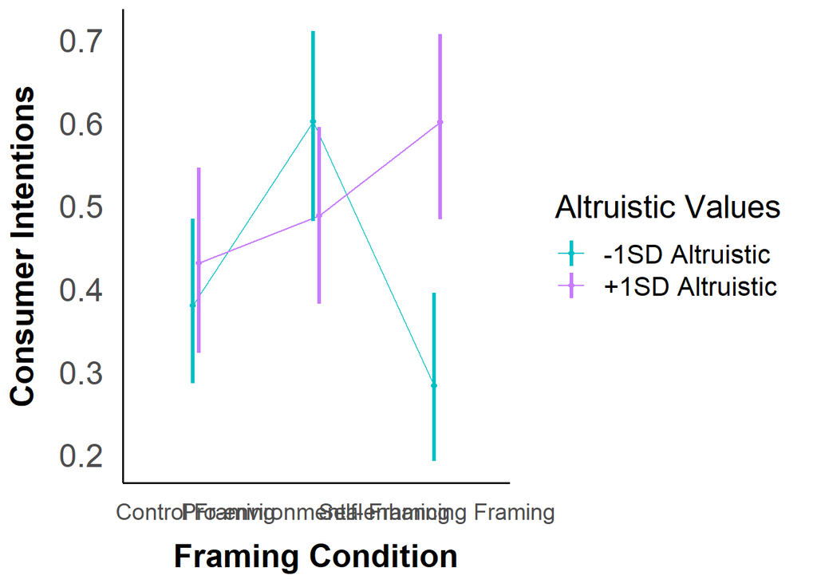

```r
sd_below <- mean(average_df$altruistic_center) - sd(average_df$altruistic_center)
sd_above <- mean(average_df$altruistic_center) + sd(average_df$altruistic_center)

at_list <- list(altruistic_center = c(sd_below, sd_above))

emmip(log_mice, altruistic_center ~ framing_condition, type = "response", CIs = TRUE, CIarg = list(lwd = 1.2, alpha = 1), xlab = "Framing Condition", ylab = "Consumer Intentions", at = at_list) +
  scale_x_discrete(breaks=c("control_framing","pro_env_framing", "self_enh_framing"), labels = c("Control Framing", "Pro-environmental Framing", "Self-enhancing Framing")) +
  theme_apa() +
  text_settings +
  scale_color_manual(name = "Altruistic Values", breaks = c(-0.802959343713252, 0.802959343713252), labels = c("-1SD Altruistic", "+1SD Altruistic"), values = c("#00BFC4","#C77CFF"))
```

#### Alt x Norm

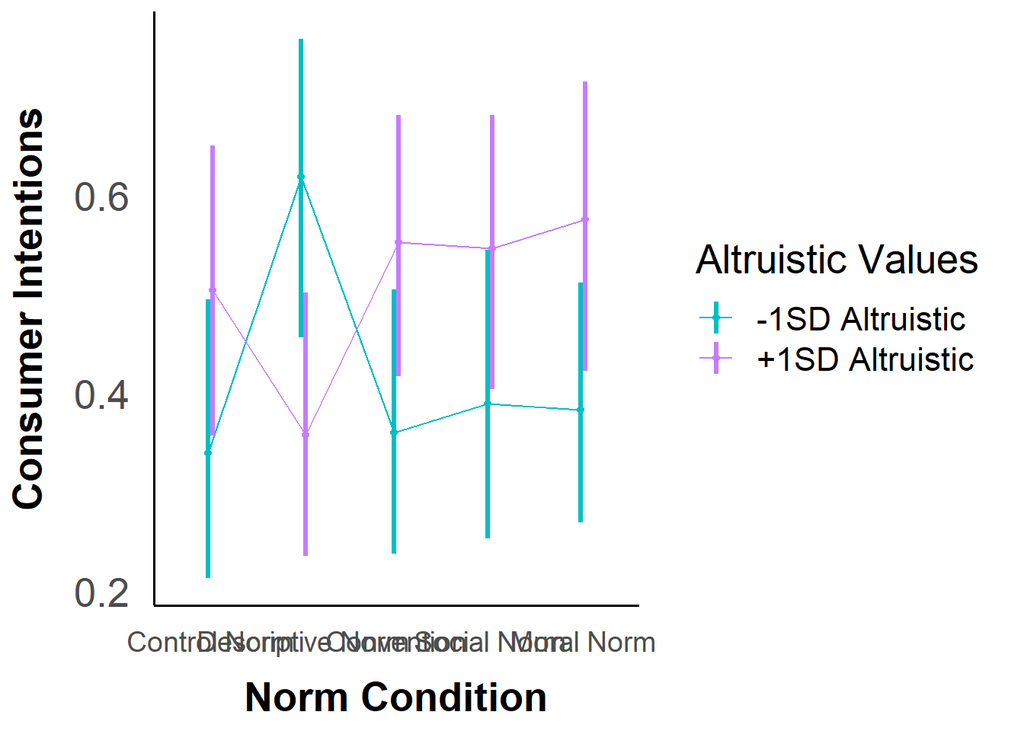

```r
emmip(log_mice, altruistic_center ~ norm_condition, type = "response", CIs = TRUE, CIarg = list(lwd = 1.2, alpha = 1), xlab = "Norm Condition", ylab = "Consumer Intentions", at = at_list) +
  scale_x_discrete(breaks=c("control_norm","descriptive_norm", "convention_norm", "social_norm", "moral_norm"), labels = c("Control Norm", "Descriptive Norm", "Convention", "Social Norm", "Moral Norm")) +
  theme_apa() +
  text_settings +
  scale_color_manual(name = "Altruistic Values", breaks = c(-0.802959343713252, 0.802959343713252), labels = c("-1SD Altruistic", "+1SD Altruistic"), values = c("#00BFC4","#C77CFF"))
```

#### Alt, Framing, Norm

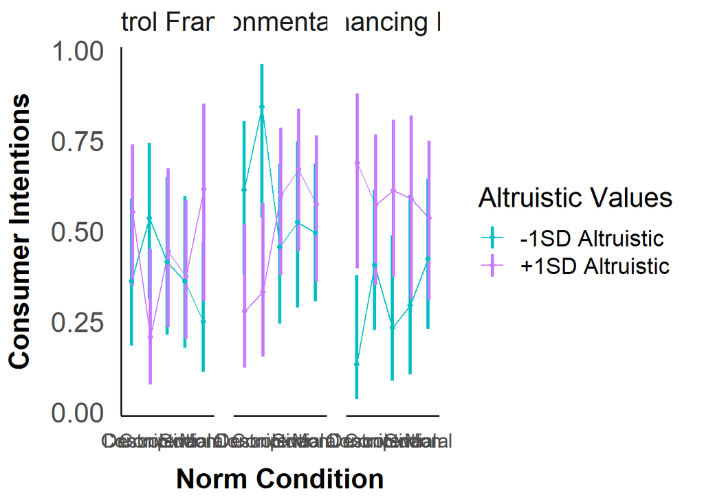

```r
emmip(log_mice, altruistic_center ~ norm_condition | framing_condition, type = "response", CIs = TRUE, CIarg = list(lwd = 1.2, alpha = 1), xlab = "Norm Condition", ylab = "Consumer Intentions", at = at_list) +
  scale_x_discrete(breaks=c("control_norm","descriptive_norm", "convention_norm", "social_norm", "moral_norm"), labels = c("Control", "Descriptive", "Convention", "Social", "Moral")) +
  facet_wrap(~framing_condition, labeller = labeller(framing_condition = frame_labs)) +
  theme_apa() +
  text_settings +
  scale_color_manual(name = "Altruistic Values", breaks = c(-0.802959343713252, 0.802959343713252), labels = c("-1SD Altruistic", "+1SD Altruistic"), values = c("#00BFC4","#C77CFF"))
```

### Planned Comparisons

#### Storing low (-1SD) and high (+1SD) altspheric values

```r
sd_below <- mean(average_df$altruistic_center) - sd(average_df$altruistic_center)
sd_above <- mean(average_df$altruistic_center) + sd(average_df$altruistic_center)
```

#### Calculate EM Means at low and high alt

```r
atlist <- list(altruistic_center = c(sd_below, sd_above))

combinations <- emmeans(log_mice, ~ norm_condition*altruistic_center*framing_condition, at=atlist, type = "response")

combinations %>% knitr::kable(digits = 2)
```

| norm_condition | altruistic_center | framing_condition | prob | SE | df | asymp.LCL | asymp.UCL |
| --- | --- | --- | --- | --- | --- | --- | --- |
| control_norm | -0.8 | control_framing | 0.36 | 0.11 | Inf | 0.18 | 0.59 |
| descriptive_norm | -0.8 | control_framing | 0.54 | 0.12 | Inf | 0.31 | 0.74 |
| convention_norm | -0.8 | control_framing | 0.41 | 0.12 | Inf | 0.21 | 0.65 |
| social_norm | -0.8 | control_framing | 0.36 | 0.11 | Inf | 0.18 | 0.60 |
| moral_norm | -0.8 | control_framing | 0.25 | 0.09 | Inf | 0.11 | 0.47 |
| control_norm | 0.8 | control_framing | 0.55 | 0.10 | Inf | 0.35 | 0.74 |
| descriptive_norm | 0.8 | control_framing | 0.21 | 0.10 | Inf | 0.08 | 0.45 |
| convention_norm | 0.8 | control_framing | 0.44 | 0.12 | Inf | 0.24 | 0.67 |
| social_norm | 0.8 | control_framing | 0.37 | 0.10 | Inf | 0.20 | 0.59 |
| moral_norm | 0.8 | control_framing | 0.62 | 0.15 | Inf | 0.31 | 0.85 |
| control_norm | -0.8 | pro_env_framing | 0.61 | 0.12 | Inf | 0.38 | 0.81 |
| descriptive_norm | -0.8 | pro_env_framing | 0.84 | 0.10 | Inf | 0.54 | 0.96 |
| convention_norm | -0.8 | pro_env_framing | 0.46 | 0.12 | Inf | 0.24 | 0.69 |
| social_norm | -0.8 | pro_env_framing | 0.52 | 0.13 | Inf | 0.29 | 0.75 |
| moral_norm | -0.8 | pro_env_framing | 0.50 | 0.10 | Inf | 0.31 | 0.69 |
| control_norm | 0.8 | pro_env_framing | 0.28 | 0.11 | Inf | 0.12 | 0.52 |
| descriptive_norm | 0.8 | pro_env_framing | 0.33 | 0.11 | Inf | 0.15 | 0.58 |
| convention_norm | 0.8 | pro_env_framing | 0.60 | 0.11 | Inf | 0.38 | 0.79 |
| social_norm | 0.8 | pro_env_framing | 0.67 | 0.11 | Inf | 0.44 | 0.84 |
| moral_norm | 0.8 | pro_env_framing | 0.57 | 0.11 | Inf | 0.36 | 0.76 |
| control_norm | -0.8 | self_enh_framing | 0.13 | 0.08 | Inf | 0.04 | 0.38 |
| descriptive_norm | -0.8 | self_enh_framing | 0.41 | 0.10 | Inf | 0.23 | 0.61 |
| convention_norm | -0.8 | self_enh_framing | 0.23 | 0.10 | Inf | 0.09 | 0.49 |
| social_norm | -0.8 | self_enh_framing | 0.29 | 0.14 | Inf | 0.10 | 0.60 |
| moral_norm | -0.8 | self_enh_framing | 0.42 | 0.11 | Inf | 0.23 | 0.64 |
| control_norm | 0.8 | self_enh_framing | 0.69 | 0.13 | Inf | 0.40 | 0.88 |
| descriptive_norm | 0.8 | self_enh_framing | 0.57 | 0.11 | Inf | 0.35 | 0.77 |
| convention_norm | 0.8 | self_enh_framing | 0.61 | 0.12 | Inf | 0.37 | 0.81 |
| social_norm | 0.8 | self_enh_framing | 0.59 | 0.14 | Inf | 0.31 | 0.82 |
| moral_norm | 0.8 | self_enh_framing | 0.54 | 0.12 | Inf | 0.31 | 0.75 |

### Custom contrasts

```r
cf_cn_low_alt <- c(1, rep(0,29)) # control framing
cf_dn_low_alt <- c(0,1,rep(0,28))
cf_conv_low_alt <- c(0,0,1,rep(0,27))
cf_sn_low_alt <- c(0,0,0,1,rep(0,26))
cf_mn_low_alt <- c(rep(0,4),1,(rep(0,25)))

cf_cn_hi_alt <- c(rep(0,5),1,(rep(0,24)))
cf_dn_hi_alt <- c(rep(0,6),1,(rep(0,23)))
cf_conv_hi_alt <- c(rep(0,7),1,(rep(0,22)))
cf_sn_hi_alt <- c(rep(0,8),1,(rep(0,21)))
cf_mn_hi_alt <- c(rep(0,9),1,(rep(0,20)))


pf_cn_low_alt <- c(rep(0,10),1,(rep(0,19))) # pro-environmental framing
pf_dn_low_alt <- c(rep(0,11),1,(rep(0,18)))
pf_conv_low_alt <- c(rep(0,12),1,(rep(0,17)))
pf_sn_low_alt <- c(rep(0,13),1,(rep(0,16)))
pf_mn_low_alt <- c(rep(0,14),1,(rep(0,15)))

pf_cn_hi_alt <- c(rep(0,15),1,(rep(0,14)))
pf_dn_hi_alt <- c(rep(0,16),1,(rep(0,13)))
pf_conv_hi_alt <- c(rep(0,17),1,(rep(0,12)))
pf_sn_hi_alt <- c(rep(0,18),1,(rep(0,11)))
pf_mn_hi_alt <- c(rep(0,19),1,(rep(0,10)))


sf_cn_low_alt <- c(rep(0,20),1,(rep(0,9))) # self-enhancing framing
sf_dn_low_alt <- c(rep(0,21),1,(rep(0,8)))
sf_conv_low_alt <- c(rep(0,22),1,(rep(0,7)))
sf_sn_low_alt <- c(rep(0,23),1,(rep(0,6)))
sf_mn_low_alt <- c(rep(0,24),1,(rep(0,5)))

sf_cn_hi_alt <- c(rep(0,25),1,(rep(0,4)))
sf_dn_hi_alt <- c(rep(0,26),1,(rep(0,3)))
sf_conv_hi_alt <- c(rep(0,27),1,(rep(0,2)))
sf_sn_hi_alt <- c(rep(0,28),1,(rep(0,1)))
sf_mn_hi_alt <- c(rep(0,29),1)
```

Effect of norm for people low vs high on altruistic values across framing conditions

#### Control framing

```r
controlframe_lowvshi_alt <- contrast(combinations,
                       method = list("CF/DN/LowAlt - CF/CN/LowAlt" = cf_dn_low_alt - cf_cn_low_alt,
                                     "CF/Conv/LowAlt - CF/CN/LowAlt" = cf_conv_low_alt - cf_cn_low_alt,
                                     "CF/SN/LowAlt - CF/CN/LowAlt" = cf_sn_low_alt - cf_cn_low_alt,
                                     "CF/MN/LowAlt - CF/CN/LowAlt" = cf_mn_low_alt - cf_cn_low_alt,
                                     "CF/DN/HiAlt - CF/CN/HiAlt" = cf_dn_hi_alt - cf_cn_hi_alt,
                                     "CF/Conv/HiAlt - CF/CN/HiAlt" = cf_conv_hi_alt - cf_cn_hi_alt,
                                     "CF/SN/HiAlt - CF/CN/HiAlt" = cf_sn_hi_alt - cf_cn_hi_alt,
                                     "CF/MN/HiAlt - CF/CN/HiAlt" = cf_mn_hi_alt - cf_cn_hi_alt),
                       adjust = "none")

controlframe_lowvshi_alt %>% knitr::kable(digits = c(NA,2,2,2,2,3))
```

| contrast | odds.ratio | SE | df | null | z.ratio | p.value |
| --- | --- | --- | --- | --- | --- | --- |
| CF/DN/LowAlt / CF/CN/LowAlt | 2.04 | 1.36 | Inf | 1 | 1.064 | NA |
| CF/Conv/LowAlt / CF/CN/LowAlt | 1.25 | 0.85 | Inf | 1 | 0.327 | NA |
| CF/SN/LowAlt / CF/CN/LowAlt | 1.00 | 0.68 | Inf | 1 | -0.006 | NA |
| CF/MN/LowAlt / CF/CN/LowAlt | 0.59 | 0.40 | Inf | 1 | -0.774 | NA |
| CF/DN/HiAlt / CF/CN/HiAlt | 0.21 | 0.15 | Inf | 1 | -2.167 | NA |
| CF/Conv/HiAlt / CF/CN/HiAlt | 0.64 | 0.41 | Inf | 1 | -0.683 | NA |
| CF/SN/HiAlt / CF/CN/HiAlt | 0.48 | 0.30 | Inf | 1 | -1.180 | NA |
| CF/MN/HiAlt / CF/CN/HiAlt | 1.30 | 0.99 | Inf | 1 | 0.339 | NA |

```r
# confidence intervals
controlframe_lowvshi_alt %>% confint() %>%
  knitr::kable(digits = 2)
```

| contrast | odds.ratio | SE | df | asymp.LCL | asymp.UCL |
| --- | --- | --- | --- | --- | --- |
| CF/DN/LowAlt / CF/CN/LowAlt | 2.04 | 1.36 | Inf | 0.55 | 7.56 |
| CF/Conv/LowAlt / CF/CN/LowAlt | 1.25 | 0.85 | Inf | 0.33 | 4.75 |
| CF/SN/LowAlt / CF/CN/LowAlt | 1.00 | 0.68 | Inf | 0.26 | 3.81 |
| CF/MN/LowAlt / CF/CN/LowAlt | 0.59 | 0.40 | Inf | 0.15 | 2.26 |
| CF/DN/HiAlt / CF/CN/HiAlt | 0.21 | 0.15 | Inf | 0.05 | 0.86 |
| CF/Conv/HiAlt / CF/CN/HiAlt | 0.64 | 0.41 | Inf | 0.18 | 2.27 |
| CF/SN/HiAlt / CF/CN/HiAlt | 0.48 | 0.30 | Inf | 0.15 | 1.61 |
| CF/MN/HiAlt / CF/CN/HiAlt | 1.30 | 0.99 | Inf | 0.29 | 5.82 |

Planned Comparisons

Custom contrasts

```r
controlframe_lowvshi_alt
```

```
##  contrast                      odds.ratio    SE  df null z.ratio p.value
##  CF/DN/LowAlt / CF/CN/LowAlt        2.037 1.362 Inf    1   1.064  0.2873
##  CF/Conv/LowAlt / CF/CN/LowAlt      1.250 0.851 Inf    1   0.327  0.7436
##  CF/SN/LowAlt / CF/CN/LowAlt        0.996 0.682 Inf    1  -0.006  0.9952
##  CF/MN/LowAlt / CF/CN/LowAlt        0.587 0.404 Inf    1  -0.774  0.4392
##  CF/DN/HiAlt / CF/CN/HiAlt          0.211 0.152 Inf    1  -2.167  0.0302
##  CF/Conv/HiAlt / CF/CN/HiAlt        0.645 0.414 Inf    1  -0.683  0.4946
##  CF/SN/HiAlt / CF/CN/HiAlt          0.484 0.298 Inf    1  -1.180  0.2381
##  CF/MN/HiAlt / CF/CN/HiAlt          1.297 0.994 Inf    1   0.339  0.7343
##
## Results are averaged over the levels of: Gender
## Tests are performed on the log odds ratio scale
```

```r
dn_vs_c_LowAlt <- c(1,rep(0,7))
conv_vs_c_LowAlt <- c(0,1,rep(0,6))
sn_vs_c_LowAlt <- c(0,0,1,rep(0,5))
mn_vs_c_LowAlt <- c(0,0,0,1,rep(0,4))

dn_vs_c_HiAlt <- c(rep(0,4),1,rep(0,3))
conv_vs_c_HiAlt <- c(rep(0,5),1,rep(0,2))
sn_vs_c_HiAlt <- c(rep(0,6),1,rep(0,1))
mn_vs_c_HiAlt <- c(rep(0,7),1)
```

```r
compare_alt <- contrast(controlframe_lowvshi_alt, method = list("Effect of DN (Low - High alt)" = dn_vs_c_LowAlt - dn_vs_c_HiAlt,
                                                                "Effect of Conv (Low - High alt)" = conv_vs_c_LowAlt - conv_vs_c_HiAlt,
                                                                "Effect of SN (Low - High alt)" = sn_vs_c_LowAlt - sn_vs_c_HiAlt,
                                                                "Effect of MN (Low - High alt)" = mn_vs_c_LowAlt - mn_vs_c_HiAlt), adjust = "none")

compare_alt %>% knitr::kable(digits = c(NA,2,2,2,2,3))
```

| contrast | odds.ratio | SE | df | null | z.ratio | p.value |
| --- | --- | --- | --- | --- | --- | --- |
| Effect of DN (Low / High alt) | 9.64 | 11.20 | Inf | 1 | 1.950 | NA |
| Effect of Conv (Low / High alt) | 1.94 | 2.07 | Inf | 1 | 0.618 | NA |
| Effect of SN (Low / High alt) | 2.06 | 2.25 | Inf | 1 | 0.659 | NA |
| Effect of MN (Low / High alt) | 0.45 | 0.55 | Inf | 1 | -0.653 | NA |

```r
# confidence intervals
compare_alt %>% confint() %>%
  knitr::kable(digits = 2)
```

| contrast | odds.ratio | SE | df | asymp.LCL | asymp.UCL |
| --- | --- | --- | --- | --- | --- |
| Effect of DN (Low / High alt) | 9.64 | 11.20 | Inf | 0.99 | 94.00 |
| Effect of Conv (Low / High alt) | 1.94 | 2.07 | Inf | 0.24 | 15.78 |
| Effect of SN (Low / High alt) | 2.06 | 2.25 | Inf | 0.24 | 17.55 |
| Effect of MN (Low / High alt) | 0.45 | 0.55 | Inf | 0.04 | 4.88 |

#### Pro-environmental framing

```r
proenvframe_lowvshi_alt <- contrast(combinations,
                       method = list("PF/DN/LowAlt - PF/CN/LowAlt" = pf_dn_low_alt - pf_cn_low_alt,
                                     "PF/Conv/LowAlt - PF/CN/LowAlt" = pf_conv_low_alt - pf_cn_low_alt,
                                     "PF/SN/LowAlt - PF/CN/LowAlt" = pf_sn_low_alt - pf_cn_low_alt,
                                     "PF/MN/LowAlt - PF/CN/LowAlt" = pf_mn_low_alt - pf_cn_low_alt,
                                     "PF/DN/HiAlt - PF/CN/HiAlt" = pf_dn_hi_alt - pf_cn_hi_alt,
                                     "PF/Conv/HiAlt - PF/CN/HiAlt" = pf_conv_hi_alt - pf_cn_hi_alt,
                                     "PF/SN/HiAlt - PF/CN/HiAlt" = pf_sn_hi_alt - pf_cn_hi_alt,
                                     "PF/MN/HiAlt - PF/CN/HiAlt" = pf_mn_hi_alt - pf_cn_hi_alt),
                       adjust = "none")

proenvframe_lowvshi_alt %>% knitr::kable(digits = c(NA,2,2,2,2,3))
```

| contrast | odds.ratio | SE | df | null | z.ratio | p.value |
| --- | --- | --- | --- | --- | --- | --- |
| PF/DN/LowAlt / PF/CN/LowAlt | 3.41 | 3.14 | Inf | 1 | 1.330 | NA |
| PF/Conv/LowAlt / PF/CN/LowAlt | 0.53 | 0.36 | Inf | 1 | -0.926 | NA |
| PF/SN/LowAlt / PF/CN/LowAlt | 0.69 | 0.49 | Inf | 1 | -0.525 | NA |
| PF/MN/LowAlt / PF/CN/LowAlt | 0.62 | 0.39 | Inf | 1 | -0.756 | NA |
| PF/DN/HiAlt / PF/CN/HiAlt | 1.28 | 0.94 | Inf | 1 | 0.337 | NA |
| PF/Conv/HiAlt / PF/CN/HiAlt | 3.85 | 2.67 | Inf | 1 | 1.949 | NA |
| PF/SN/HiAlt / PF/CN/HiAlt | 5.25 | 3.69 | Inf | 1 | 2.359 | NA |
| PF/MN/HiAlt / PF/CN/HiAlt | 3.48 | 2.38 | Inf | 1 | 1.819 | NA |

```r
# confidence intervals
proenvframe_lowvshi_alt %>% confint() %>%
  knitr::kable(digits = 2)
```

| contrast | odds.ratio | SE | df | asymp.LCL | asymp.UCL |
| --- | --- | --- | --- | --- | --- |
| PF/DN/LowAlt / PF/CN/LowAlt | 3.41 | 3.14 | Inf | 0.56 | 20.78 |
| PF/Conv/LowAlt / PF/CN/LowAlt | 0.53 | 0.36 | Inf | 0.14 | 2.04 |
| PF/SN/LowAlt / PF/CN/LowAlt | 0.69 | 0.49 | Inf | 0.17 | 2.74 |
| PF/MN/LowAlt / PF/CN/LowAlt | 0.62 | 0.39 | Inf | 0.18 | 2.15 |
| PF/DN/HiAlt / PF/CN/HiAlt | 1.28 | 0.94 | Inf | 0.30 | 5.41 |
| PF/Conv/HiAlt / PF/CN/HiAlt | 3.85 | 2.67 | Inf | 0.99 | 14.96 |
| PF/SN/HiAlt / PF/CN/HiAlt | 5.25 | 3.69 | Inf | 1.32 | 20.84 |
| PF/MN/HiAlt / PF/CN/HiAlt | 3.48 | 2.38 | Inf | 0.91 | 13.32 |

Planned Comparisons

Custom contrasts

```r
proenvframe_lowvshi_alt
```

```
##  contrast                      odds.ratio    SE  df null z.ratio p.value
##  PF/DN/LowAlt / PF/CN/LowAlt        3.410 3.144 Inf    1   1.330  0.1834
##  PF/Conv/LowAlt / PF/CN/LowAlt      0.529 0.364 Inf    1  -0.926  0.3546
##  PF/SN/LowAlt / PF/CN/LowAlt        0.692 0.486 Inf    1  -0.525  0.5999
##  PF/MN/LowAlt / PF/CN/LowAlt        0.618 0.393 Inf    1  -0.756  0.4494
##  PF/DN/HiAlt / PF/CN/HiAlt          1.281 0.942 Inf    1   0.337  0.7359
##  PF/Conv/HiAlt / PF/CN/HiAlt        3.853 2.666 Inf    1   1.949  0.0513
##  PF/SN/HiAlt / PF/CN/HiAlt          5.253 3.693 Inf    1   2.359  0.0183
##  PF/MN/HiAlt / PF/CN/HiAlt          3.478 2.383 Inf    1   1.819  0.0689
##
## Results are averaged over the levels of: Gender
## Tests are performed on the log odds ratio scale
```

```r
dn_vs_c_LowAlt <- c(1,rep(0,7))
conv_vs_c_LowAlt <- c(0,1,rep(0,6))
sn_vs_c_LowAlt <- c(0,0,1,rep(0,5))
mn_vs_c_LowAlt <- c(0,0,0,1,rep(0,4))

dn_vs_c_HiAlt <- c(rep(0,4),1,rep(0,3))
conv_vs_c_HiAlt <- c(rep(0,5),1,rep(0,2))
sn_vs_c_HiAlt <- c(rep(0,6),1,rep(0,1))
mn_vs_c_HiAlt <- c(rep(0,7),1)
```

```r
compare_alt <- contrast(proenvframe_lowvshi_alt, method = list("Effect of DN (Low - High alt)" = dn_vs_c_LowAlt - dn_vs_c_HiAlt,
                                                                "Effect of Conv (Low - High alt)" = conv_vs_c_LowAlt - conv_vs_c_HiAlt,
                                                                "Effect of SN (Low - High alt)" = sn_vs_c_LowAlt - sn_vs_c_HiAlt,
                                                                "Effect of MN (Low - High alt)" = mn_vs_c_LowAlt - mn_vs_c_HiAlt), adjust = "none")

compare_alt %>% knitr::kable(digits = c(NA,2,2,2,2,3))
```

| contrast | odds.ratio | SE | df | null | z.ratio | p.value |
| --- | --- | --- | --- | --- | --- | --- |
| Effect of DN (Low / High alt) | 2.66 | 3.86 | Inf | 1 | 0.674 | NA |
| Effect of Conv (Low / High alt) | 0.14 | 0.16 | Inf | 1 | -1.690 | NA |
| Effect of SN (Low / High alt) | 0.13 | 0.15 | Inf | 1 | -1.738 | NA |
| Effect of MN (Low / High alt) | 0.18 | 0.19 | Inf | 1 | -1.583 | NA |

```r
# confidence intervals
compare_alt %>% confint() %>%
  knitr::kable(digits = 2)
```

| contrast | odds.ratio | SE | df | asymp.LCL | asymp.UCL |
| --- | --- | --- | --- | --- | --- |
| Effect of DN (Low / High alt) | 2.66 | 3.86 | Inf | 0.15 | 45.76 |
| Effect of Conv (Low / High alt) | 0.14 | 0.16 | Inf | 0.01 | 1.37 |
| Effect of SN (Low / High alt) | 0.13 | 0.15 | Inf | 0.01 | 1.30 |
| Effect of MN (Low / High alt) | 0.18 | 0.19 | Inf | 0.02 | 1.51 |

#### Self-enhancing framing

```r
selfenhframe_lowvshi_alt <- contrast(combinations,
                       method = list("SF/DN/LowAlt - SF/CN/LowAlt" = sf_dn_low_alt - sf_cn_low_alt,
                                     "SF/Conv/LowAlt - SF/CN/LowAlt" = sf_conv_low_alt - sf_cn_low_alt,
                                     "SF/SN/LowAlt - SF/CN/LowAlt" = sf_sn_low_alt - sf_cn_low_alt,
                                     "SF/MN/LowAlt - SF/CN/LowAlt" = sf_mn_low_alt - sf_cn_low_alt,
                                     "SF/DN/HiAlt - SF/CN/HiAlt" = sf_dn_hi_alt - sf_cn_hi_alt,
                                     "SF/Conv/HiAlt - SF/CN/HiAlt" = sf_conv_hi_alt - sf_cn_hi_alt,
                                     "SF/SN/HiAlt - SF/CN/HiAlt" = sf_sn_hi_alt - sf_cn_hi_alt,
                                     "SF/MN/HiAlt - SF/CN/HiAlt" = sf_mn_hi_alt - sf_cn_hi_alt),
                       adjust = "none")

selfenhframe_lowvshi_alt %>% knitr::kable(digits = c(NA,2,2,2,2,3))
```

| contrast | odds.ratio | SE | df | null | z.ratio | p.value |
| --- | --- | --- | --- | --- | --- | --- |
| SF/DN/LowAlt / SF/CN/LowAlt | 4.51 | 3.76 | Inf | 1 | 1.808 | NA |
| SF/Conv/LowAlt / SF/CN/LowAlt | 1.99 | 1.84 | Inf | 1 | 0.747 | NA |
| SF/SN/LowAlt / SF/CN/LowAlt | 2.75 | 2.65 | Inf | 1 | 1.052 | NA |
| SF/MN/LowAlt / SF/CN/LowAlt | 4.84 | 4.10 | Inf | 1 | 1.863 | NA |
| SF/DN/HiAlt / SF/CN/HiAlt | 0.61 | 0.47 | Inf | 1 | -0.647 | NA |
| SF/Conv/HiAlt / SF/CN/HiAlt | 0.72 | 0.57 | Inf | 1 | -0.415 | NA |
| SF/SN/HiAlt / SF/CN/HiAlt | 0.65 | 0.55 | Inf | 1 | -0.504 | NA |
| SF/MN/HiAlt / SF/CN/HiAlt | 0.53 | 0.41 | Inf | 1 | -0.821 | NA |

```r
# confidence intervals
selfenhframe_lowvshi_alt %>% confint() %>%
  knitr::kable(digits = 2)
```

| contrast | odds.ratio | SE | df | asymp.LCL | asymp.UCL |
| --- | --- | --- | --- | --- | --- |
| SF/DN/LowAlt / SF/CN/LowAlt | 4.51 | 3.76 | Inf | 0.88 | 23.07 |
| SF/Conv/LowAlt / SF/CN/LowAlt | 1.99 | 1.84 | Inf | 0.33 | 12.13 |
| SF/SN/LowAlt / SF/CN/LowAlt | 2.75 | 2.65 | Inf | 0.42 | 18.20 |
| SF/MN/LowAlt / SF/CN/LowAlt | 4.84 | 4.10 | Inf | 0.92 | 25.47 |
| SF/DN/HiAlt / SF/CN/HiAlt | 0.61 | 0.47 | Inf | 0.14 | 2.74 |
| SF/Conv/HiAlt / SF/CN/HiAlt | 0.72 | 0.57 | Inf | 0.16 | 3.35 |
| SF/SN/HiAlt / SF/CN/HiAlt | 0.65 | 0.55 | Inf | 0.13 | 3.41 |
| SF/MN/HiAlt / SF/CN/HiAlt | 0.53 | 0.41 | Inf | 0.11 | 2.43 |

Planned Comparisons

Custom contrasts

```r
selfenhframe_lowvshi_alt
```

```
##  contrast                      odds.ratio    SE  df null z.ratio p.value
##  SF/DN/LowAlt / SF/CN/LowAlt        4.509 3.756 Inf    1   1.808  0.0706
##  SF/Conv/LowAlt / SF/CN/LowAlt      1.991 1.836 Inf    1   0.747  0.4552
##  SF/SN/LowAlt / SF/CN/LowAlt        2.754 2.653 Inf    1   1.052  0.2930
##  SF/MN/LowAlt / SF/CN/LowAlt        4.844 4.102 Inf    1   1.863  0.0624
##  SF/DN/HiAlt / SF/CN/HiAlt          0.609 0.467 Inf    1  -0.647  0.5177
##  SF/Conv/HiAlt / SF/CN/HiAlt        0.722 0.566 Inf    1  -0.415  0.6779
##  SF/SN/HiAlt / SF/CN/HiAlt          0.654 0.551 Inf    1  -0.504  0.6140
##  SF/MN/HiAlt / SF/CN/HiAlt          0.527 0.411 Inf    1  -0.821  0.4115
##
## Results are averaged over the levels of: Gender
## Tests are performed on the log odds ratio scale
```

```r
dn_vs_c_LowAlt <- c(1,rep(0,7))
conv_vs_c_LowAlt <- c(0,1,rep(0,6))
sn_vs_c_LowAlt <- c(0,0,1,rep(0,5))
mn_vs_c_LowAlt <- c(0,0,0,1,rep(0,4))

dn_vs_c_HiAlt <- c(rep(0,4),1,rep(0,3))
conv_vs_c_HiAlt <- c(rep(0,5),1,rep(0,2))
sn_vs_c_HiAlt <- c(rep(0,6),1,rep(0,1))
mn_vs_c_HiAlt <- c(rep(0,7),1)
```

```r
compare_alt <- contrast(selfenhframe_lowvshi_alt, method = list("Effect of DN (Low - High alt)" = dn_vs_c_LowAlt - dn_vs_c_HiAlt,
                                                                "Effect of Conv (Low - High alt)" = conv_vs_c_LowAlt - conv_vs_c_HiAlt,
                                                                "Effect of SN (Low - High alt)" = sn_vs_c_LowAlt - sn_vs_c_HiAlt,
                                                                "Effect of MN (Low - High alt)" = mn_vs_c_LowAlt - mn_vs_c_HiAlt), adjust = "none")

compare_alt %>% knitr::kable(digits = c(NA,2,2,2,2,3))
```

| contrast | odds.ratio | SE | df | null | z.ratio | p.value |
| --- | --- | --- | --- | --- | --- | --- |
| Effect of DN (Low / High alt) | 7.40 | 10.46 | Inf | 1 | 1.417 | NA |
| Effect of Conv (Low / High alt) | 2.76 | 4.16 | Inf | 1 | 0.672 | NA |
| Effect of SN (Low / High alt) | 4.21 | 6.84 | Inf | 1 | 0.886 | NA |
| Effect of MN (Low / High alt) | 9.19 | 13.10 | Inf | 1 | 1.555 | NA |

```r
# confidence intervals
compare_alt %>% confint() %>%
  knitr::kable(digits = 2)
```

| contrast | odds.ratio | SE | df | asymp.LCL | asymp.UCL |
| --- | --- | --- | --- | --- | --- |
| Effect of DN (Low / High alt) | 7.40 | 10.46 | Inf | 0.46 | 117.97 |
| Effect of Conv (Low / High alt) | 2.76 | 4.16 | Inf | 0.14 | 53.07 |
| Effect of SN (Low / High alt) | 4.21 | 6.84 | Inf | 0.17 | 101.51 |
| Effect of MN (Low / High alt) | 9.19 | 13.10 | Inf | 0.56 | 150.36 |

## Egoistic values

Is the difference between Control Norm and Other Norm different for people low vs high on egoistic values? Does this vary across framing conditions?

### Visualization

```r
text_settings <- theme(text = element_text(size = 20)) +
  theme(plot.title = element_text(size = 20, face = 'bold')) +
  theme(axis.title.x = element_text(face = 'bold')) +
  theme(axis.title.y = element_text(face = 'bold')) +
  theme(axis.text.x = element_text(size = 14)) +
  theme(axis.text.y = element_text(size = 20)) +
  theme(axis.ticks = element_blank())
```

#### Ego x Framing

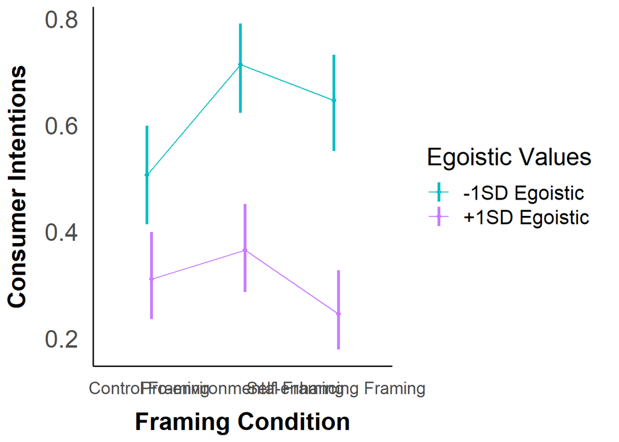

```r
sd_below <- mean(average_df$egoistic_center) - sd(average_df$egoistic_center)
sd_above <- mean(average_df$egoistic_center) + sd(average_df$egoistic_center)

at_list <- list(egoistic_center = c(sd_below, sd_above))

emmip(log_mice, egoistic_center ~ framing_condition, type = "response", CIs = TRUE, CIarg = list(lwd = 1.2, alpha = 1), xlab = "Framing Condition", ylab = "Consumer Intentions", at = at_list) +
  scale_x_discrete(breaks=c("control_framing","pro_env_framing", "self_enh_framing"), labels = c("Control Framing", "Pro-environmental Framing", "Self-enhancing Framing")) +
  theme_apa() +
  text_settings +
  scale_color_manual(name = "Egoistic Values", breaks = c(-0.91717706890615, 0.917177068906151), labels = c("-1SD Egoistic", "+1SD Egoistic"), values = c("#00BFC4","#C77CFF"))
```

#### Ego x Norm

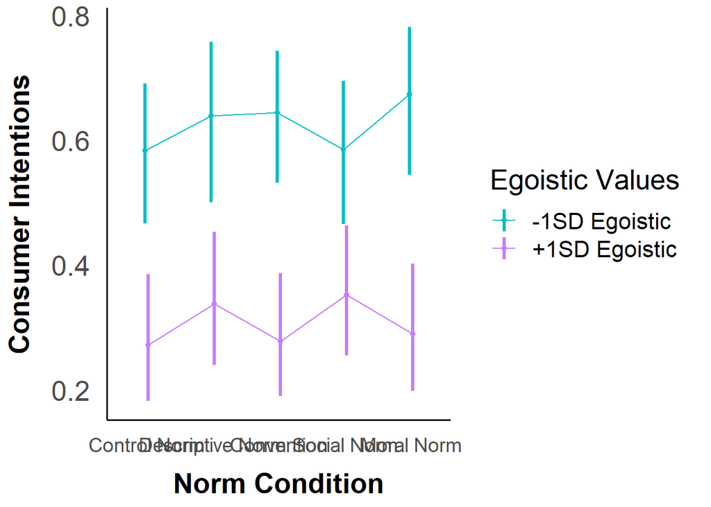

```r
emmip(log_mice, egoistic_center ~ norm_condition, CIs = TRUE, type = "response", CIarg = list(lwd = 1.2, alpha = 1), xlab = "Norm Condition", ylab = "Consumer Intentions", at = at_list) +
  scale_x_discrete(breaks=c("control_norm","descriptive_norm", "convention_norm", "social_norm", "moral_norm"), labels = c("Control Norm", "Descriptive Norm", "Convention", "Social Norm", "Moral Norm")) +
  theme_apa() +
  text_settings +
  scale_color_manual(name = "Egoistic Values", breaks = c(-0.91717706890615, 0.917177068906151), labels = c("-1SD Egoistic", "+1SD Egoistic"), values = c("#00BFC4","#C77CFF"))
```

#### Ego, Norm, Framing

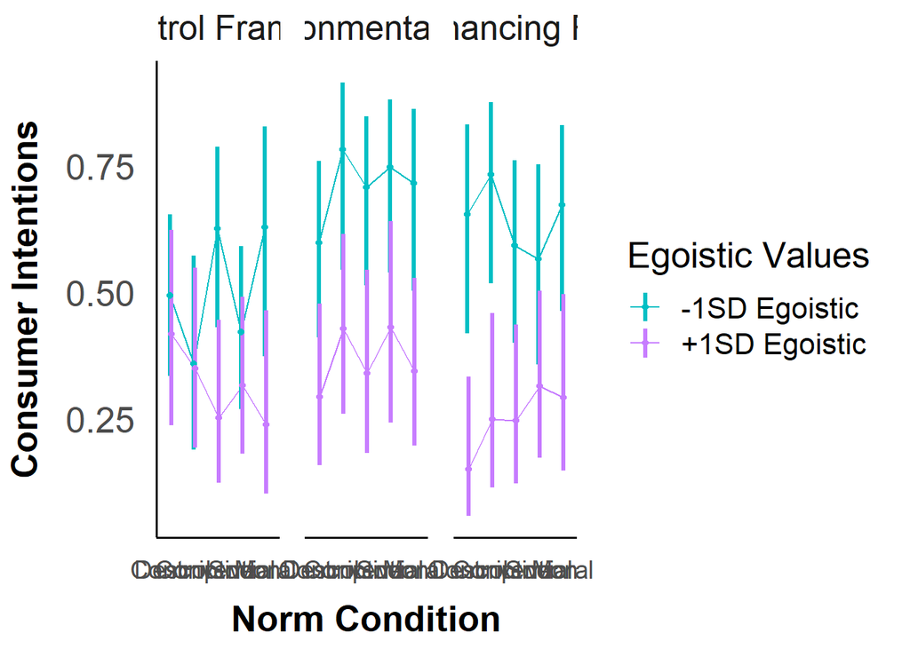

```r
emmip(log_mice, egoistic_center ~ norm_condition | framing_condition, type = "response", CIs = TRUE, CIarg = list(lwd = 1.2, alpha = 1), xlab = "Norm Condition", ylab = "Consumer Intentions", at = at_list) +
  scale_x_discrete(breaks=c("control_norm","descriptive_norm", "convention_norm", "social_norm", "moral_norm"), labels = c("Control", "Descriptive", "Convention", "Social", "Moral")) +
  facet_wrap(~framing_condition, labeller = labeller(framing_condition = frame_labs)) +
  theme_apa() +
  text_settings +
  scale_color_manual(name = "Egoistic Values", breaks = c(-0.91717706890615, 0.917177068906151), labels = c("-1SD Egoistic", "+1SD Egoistic"), values = c("#00BFC4","#C77CFF"))
```

### Planned Comparisons

#### Storing low (-1SD) and high (+1SD) egoistic values

```r
sd_below <- mean(average_df$egoistic_center) - sd(average_df$egoistic_center)
sd_above <- mean(average_df$egoistic_center) + sd(average_df$egoistic_center)
```

#### Calculate EM Means at low and high ego

```r
atlist <- list(egoistic_center = c(sd_below, sd_above))

combinations <- emmeans(log_mice, ~ norm_condition*egoistic_center*framing_condition, at=atlist, type = "response")

combinations %>% knitr::kable(digits = 2)
```

| norm_condition | egoistic_center | framing_condition | prob | SE | df | asymp.LCL | asymp.UCL |
| --- | --- | --- | --- | --- | --- | --- | --- |
| control_norm | -0.92 | control_framing | 0.49 | 0.08 | Inf | 0.33 | 0.65 |
| descriptive_norm | -0.92 | control_framing | 0.36 | 0.10 | Inf | 0.19 | 0.57 |
| convention_norm | -0.92 | control_framing | 0.63 | 0.10 | Inf | 0.43 | 0.79 |
| social_norm | -0.92 | control_framing | 0.42 | 0.08 | Inf | 0.27 | 0.59 |
| moral_norm | -0.92 | control_framing | 0.63 | 0.12 | Inf | 0.37 | 0.83 |
| control_norm | 0.92 | control_framing | 0.42 | 0.10 | Inf | 0.24 | 0.62 |
| descriptive_norm | 0.92 | control_framing | 0.35 | 0.09 | Inf | 0.19 | 0.55 |
| convention_norm | 0.92 | control_framing | 0.25 | 0.08 | Inf | 0.12 | 0.45 |
| social_norm | 0.92 | control_framing | 0.32 | 0.08 | Inf | 0.18 | 0.49 |
| moral_norm | 0.92 | control_framing | 0.24 | 0.09 | Inf | 0.10 | 0.46 |
| control_norm | -0.92 | pro_env_framing | 0.60 | 0.09 | Inf | 0.41 | 0.76 |
| descriptive_norm | -0.92 | pro_env_framing | 0.78 | 0.10 | Inf | 0.54 | 0.92 |
| convention_norm | -0.92 | pro_env_framing | 0.71 | 0.09 | Inf | 0.51 | 0.85 |
| social_norm | -0.92 | pro_env_framing | 0.75 | 0.09 | Inf | 0.54 | 0.88 |
| moral_norm | -0.92 | pro_env_framing | 0.72 | 0.09 | Inf | 0.50 | 0.86 |
| control_norm | 0.92 | pro_env_framing | 0.29 | 0.08 | Inf | 0.16 | 0.48 |
| descriptive_norm | 0.92 | pro_env_framing | 0.43 | 0.09 | Inf | 0.26 | 0.62 |
| convention_norm | 0.92 | pro_env_framing | 0.34 | 0.10 | Inf | 0.18 | 0.54 |
| social_norm | 0.92 | pro_env_framing | 0.43 | 0.11 | Inf | 0.24 | 0.64 |
| moral_norm | 0.92 | pro_env_framing | 0.34 | 0.09 | Inf | 0.20 | 0.53 |
| control_norm | -0.92 | self_enh_framing | 0.65 | 0.11 | Inf | 0.42 | 0.83 |
| descriptive_norm | -0.92 | self_enh_framing | 0.73 | 0.09 | Inf | 0.52 | 0.88 |
| convention_norm | -0.92 | self_enh_framing | 0.59 | 0.10 | Inf | 0.40 | 0.76 |
| social_norm | -0.92 | self_enh_framing | 0.57 | 0.11 | Inf | 0.36 | 0.75 |
| moral_norm | -0.92 | self_enh_framing | 0.67 | 0.10 | Inf | 0.46 | 0.83 |
| control_norm | 0.92 | self_enh_framing | 0.15 | 0.07 | Inf | 0.06 | 0.33 |
| descriptive_norm | 0.92 | self_enh_framing | 0.25 | 0.09 | Inf | 0.11 | 0.46 |
| convention_norm | 0.92 | self_enh_framing | 0.25 | 0.08 | Inf | 0.12 | 0.44 |
| social_norm | 0.92 | self_enh_framing | 0.31 | 0.09 | Inf | 0.17 | 0.50 |
| moral_norm | 0.92 | self_enh_framing | 0.29 | 0.09 | Inf | 0.15 | 0.50 |

### Custom contrasts

```r
cf_cn_low_ego <- c(1, rep(0,29)) # control framing
cf_dn_low_ego <- c(0,1,rep(0,28))
cf_conv_low_ego <- c(0,0,1,rep(0,27))
cf_sn_low_ego <- c(0,0,0,1,rep(0,26))
cf_mn_low_ego <- c(rep(0,4),1,(rep(0,25)))

cf_cn_hi_ego <- c(rep(0,5),1,(rep(0,24)))
cf_dn_hi_ego <- c(rep(0,6),1,(rep(0,23)))
cf_conv_hi_ego <- c(rep(0,7),1,(rep(0,22)))
cf_sn_hi_ego <- c(rep(0,8),1,(rep(0,21)))
cf_mn_hi_ego <- c(rep(0,9),1,(rep(0,20)))


pf_cn_low_ego <- c(rep(0,10),1,(rep(0,19))) # pro-environmental framing
pf_dn_low_ego <- c(rep(0,11),1,(rep(0,18)))
pf_conv_low_ego <- c(rep(0,12),1,(rep(0,17)))
pf_sn_low_ego <- c(rep(0,13),1,(rep(0,16)))
pf_mn_low_ego <- c(rep(0,14),1,(rep(0,15)))

pf_cn_hi_ego <- c(rep(0,15),1,(rep(0,14)))
pf_dn_hi_ego <- c(rep(0,16),1,(rep(0,13)))
pf_conv_hi_ego <- c(rep(0,17),1,(rep(0,12)))
pf_sn_hi_ego <- c(rep(0,18),1,(rep(0,11)))
pf_mn_hi_ego <- c(rep(0,19),1,(rep(0,10)))


sf_cn_low_ego <- c(rep(0,20),1,(rep(0,9))) # self-enhancing framing
sf_dn_low_ego <- c(rep(0,21),1,(rep(0,8)))
sf_conv_low_ego <- c(rep(0,22),1,(rep(0,7)))
sf_sn_low_ego <- c(rep(0,23),1,(rep(0,6)))
sf_mn_low_ego <- c(rep(0,24),1,(rep(0,5)))

sf_cn_hi_ego <- c(rep(0,25),1,(rep(0,4)))
sf_dn_hi_ego <- c(rep(0,26),1,(rep(0,3)))
sf_conv_hi_ego <- c(rep(0,27),1,(rep(0,2)))
sf_sn_hi_ego <- c(rep(0,28),1,(rep(0,1)))
sf_mn_hi_ego <- c(rep(0,29),1)
```

Effect of norm for people low vs high on egoistic values across framing conditions

#### Control framing

```r
controlframe_lowvshi_ego <- contrast(combinations,
                       method = list("CF/DN/LowEgo - CF/CN/LowEgo" = cf_dn_low_ego - cf_cn_low_ego,
                                     "CF/Conv/LowEgo - CF/CN/LowEgo" = cf_conv_low_ego - cf_cn_low_ego,
                                     "CF/SN/LowEgo - CF/CN/LowEgo" = cf_sn_low_ego - cf_cn_low_ego,
                                     "CF/MN/LowEgo - CF/CN/LowEgo" = cf_mn_low_ego - cf_cn_low_ego,
                                     "CF/DN/HiEgo - CF/CN/HiEgo" = cf_dn_hi_ego - cf_cn_hi_ego,
                                     "CF/Conv/HiEgo - CF/CN/HiEgo" = cf_conv_hi_ego - cf_cn_hi_ego,
                                     "CF/SN/HiEgo - CF/CN/HiEgo" = cf_sn_hi_ego - cf_cn_hi_ego,
                                     "CF/MN/HiEgo - CF/CN/HiEgo" = cf_mn_hi_ego - cf_cn_hi_ego),
                       adjust = "none")

controlframe_lowvshi_ego %>% knitr::kable(digits = c(NA,2,2,2,2,3))
```

| contrast | odds.ratio | SE | df | null | z.ratio | p.value |
| --- | --- | --- | --- | --- | --- | --- |
| CF/DN/LowEgo / CF/CN/LowEgo | 0.57 | 0.32 | Inf | 1 | -0.997 | NA |
| CF/Conv/LowEgo / CF/CN/LowEgo | 1.72 | 0.91 | Inf | 1 | 1.031 | NA |
| CF/SN/LowEgo / CF/CN/LowEgo | 0.75 | 0.36 | Inf | 1 | -0.607 | NA |
| CF/MN/LowEgo / CF/CN/LowEgo | 1.74 | 1.10 | Inf | 1 | 0.874 | NA |
| CF/DN/HiEgo / CF/CN/HiEgo | 0.75 | 0.45 | Inf | 1 | -0.482 | NA |
| CF/Conv/HiEgo / CF/CN/HiEgo | 0.47 | 0.29 | Inf | 1 | -1.232 | NA |
| CF/SN/HiEgo / CF/CN/HiEgo | 0.64 | 0.36 | Inf | 1 | -0.780 | NA |
| CF/MN/HiEgo / CF/CN/HiEgo | 0.44 | 0.30 | Inf | 1 | -1.218 | NA |

```r
# confidence intervals
controlframe_lowvshi_ego %>% confint() %>%
  knitr::kable(digits = 2)
```

| contrast | odds.ratio | SE | df | asymp.LCL | asymp.UCL |
| --- | --- | --- | --- | --- | --- |
| CF/DN/LowEgo / CF/CN/LowEgo | 0.57 | 0.32 | Inf | 0.19 | 1.71 |
| CF/Conv/LowEgo / CF/CN/LowEgo | 1.72 | 0.91 | Inf | 0.61 | 4.83 |
| CF/SN/LowEgo / CF/CN/LowEgo | 0.75 | 0.36 | Inf | 0.29 | 1.91 |
| CF/MN/LowEgo / CF/CN/LowEgo | 1.74 | 1.10 | Inf | 0.50 | 6.03 |
| CF/DN/HiEgo / CF/CN/HiEgo | 0.75 | 0.45 | Inf | 0.23 | 2.41 |
| CF/Conv/HiEgo / CF/CN/HiEgo | 0.47 | 0.29 | Inf | 0.14 | 1.57 |
| CF/SN/HiEgo / CF/CN/HiEgo | 0.64 | 0.36 | Inf | 0.21 | 1.95 |
| CF/MN/HiEgo / CF/CN/HiEgo | 0.44 | 0.30 | Inf | 0.12 | 1.65 |

Planned Comparisons

Custom contrasts

```r
controlframe_lowvshi_ego
```

```
##  contrast                      odds.ratio    SE  df null z.ratio p.value
##  CF/DN/LowEgo / CF/CN/LowEgo        0.574 0.320 Inf    1  -0.997  0.3190
##  CF/Conv/LowEgo / CF/CN/LowEgo      1.721 0.907 Inf    1   1.031  0.3025
##  CF/SN/LowEgo / CF/CN/LowEgo        0.749 0.357 Inf    1  -0.607  0.5440
##  CF/MN/LowEgo / CF/CN/LowEgo        1.740 1.103 Inf    1   0.874  0.3820
##  CF/DN/HiEgo / CF/CN/HiEgo          0.750 0.447 Inf    1  -0.482  0.6298
##  CF/Conv/HiEgo / CF/CN/HiEgo        0.468 0.288 Inf    1  -1.232  0.2181
##  CF/SN/HiEgo / CF/CN/HiEgo          0.644 0.363 Inf    1  -0.780  0.4355
##  CF/MN/HiEgo / CF/CN/HiEgo          0.437 0.297 Inf    1  -1.218  0.2231
##
## Results are averaged over the levels of: Gender
## Tests are performed on the log odds ratio scale
```

```r
dn_vs_c_LowEgo <- c(1,rep(0,7))
conv_vs_c_LowEgo <- c(0,1,rep(0,6))
sn_vs_c_LowEgo <- c(0,0,1,rep(0,5))
mn_vs_c_LowEgo <- c(0,0,0,1,rep(0,4))

dn_vs_c_HiEgo <- c(rep(0,4),1,rep(0,3))
conv_vs_c_HiEgo <- c(rep(0,5),1,rep(0,2))
sn_vs_c_HiEgo <- c(rep(0,6),1,rep(0,1))
mn_vs_c_HiEgo <- c(rep(0,7),1)
```

```r
compare_ego <- contrast(controlframe_lowvshi_ego, method = list("Effect of DN (Low - High ego)" = dn_vs_c_LowEgo - dn_vs_c_HiEgo,
                                                                "Effect of Conv (Low - High ego)" = conv_vs_c_LowEgo - conv_vs_c_HiEgo,
                                                                "Effect of SN (Low - High ego)" = sn_vs_c_LowEgo - sn_vs_c_HiEgo,
                                                                "Effect of MN (Low - High ego)" = mn_vs_c_LowEgo - mn_vs_c_HiEgo), adjust = "none")

compare_ego %>% knitr::kable(digits = c(NA,2,2,2,2,3))
```

| contrast | odds.ratio | SE | df | null | z.ratio | p.value |
| --- | --- | --- | --- | --- | --- | --- |
| Effect of DN (Low / High ego) | 0.76 | 0.67 | Inf | 1 | -0.308 | NA |
| Effect of Conv (Low / High ego) | 3.68 | 3.09 | Inf | 1 | 1.550 | NA |
| Effect of SN (Low / High ego) | 1.16 | 0.90 | Inf | 1 | 0.195 | NA |
| Effect of MN (Low / High ego) | 3.98 | 4.12 | Inf | 1 | 1.332 | NA |

```r
# confidence intervals
compare_ego %>% confint() %>%
  knitr::kable(digits = 2)
```

| contrast | odds.ratio | SE | df | asymp.LCL | asymp.UCL |
| --- | --- | --- | --- | --- | --- |
| Effect of DN (Low / High ego) | 0.76 | 0.67 | Inf | 0.14 | 4.22 |
| Effect of Conv (Low / High ego) | 3.68 | 3.09 | Inf | 0.71 | 19.07 |
| Effect of SN (Low / High ego) | 1.16 | 0.90 | Inf | 0.26 | 5.27 |
| Effect of MN (Low / High ego) | 3.98 | 4.12 | Inf | 0.52 | 30.34 |

#### Pro-environmental framing

```r
proenvframe_lowvshi_ego <- contrast(combinations,
                       method = list("PF/DN/LowEgo - PF/CN/LowEgo" = pf_dn_low_ego - pf_cn_low_ego,
                                     "PF/Conv/LowEgo - PF/CN/LowEgo" = pf_conv_low_ego - pf_cn_low_ego,
                                     "PF/SN/LowEgo - PF/CN/LowEgo" = pf_sn_low_ego - pf_cn_low_ego,
                                     "PF/MN/LowEgo - PF/CN/LowEgo" = pf_mn_low_ego - pf_cn_low_ego,
                                     "PF/DN/HiEgo - PF/CN/HiEgo" = pf_dn_hi_ego - pf_cn_hi_ego,
                                     "PF/Conv/HiEgo - PF/CN/HiEgo" = pf_conv_hi_ego - pf_cn_hi_ego,
                                     "PF/SN/HiEgo - PF/CN/HiEgo" = pf_sn_hi_ego - pf_cn_hi_ego,
                                     "PF/MN/HiEgo - PF/CN/HiEgo" = pf_mn_hi_ego - pf_cn_hi_ego),
                       adjust = "none")

proenvframe_lowvshi_ego %>% knitr::kable(digits = c(NA,2,2,2,2,3))
```

| contrast | odds.ratio | SE | df | null | z.ratio | p.value |
| --- | --- | --- | --- | --- | --- | --- |
| PF/DN/LowEgo / PF/CN/LowEgo | 2.42 | 1.64 | Inf | 1 | 1.299 | NA |
| PF/Conv/LowEgo / PF/CN/LowEgo | 1.63 | 0.93 | Inf | 1 | 0.859 | NA |
| PF/SN/LowEgo / PF/CN/LowEgo | 1.99 | 1.21 | Inf | 1 | 1.134 | NA |
| PF/MN/LowEgo / PF/CN/LowEgo | 1.70 | 1.02 | Inf | 1 | 0.882 | NA |
| PF/DN/HiEgo / PF/CN/HiEgo | 1.81 | 1.01 | Inf | 1 | 1.058 | NA |
| PF/Conv/HiEgo / PF/CN/HiEgo | 1.25 | 0.73 | Inf | 1 | 0.374 | NA |
| PF/SN/HiEgo / PF/CN/HiEgo | 1.82 | 1.09 | Inf | 1 | 1.008 | NA |
| PF/MN/HiEgo / PF/CN/HiEgo | 1.26 | 0.71 | Inf | 1 | 0.421 | NA |

```r
# confidence intervals
proenvframe_lowvshi_ego %>% confint() %>%
  knitr::kable(digits = 2)
```

| contrast | odds.ratio | SE | df | asymp.LCL | asymp.UCL |
| --- | --- | --- | --- | --- | --- |
| PF/DN/LowEgo / PF/CN/LowEgo | 2.42 | 1.64 | Inf | 0.64 | 9.16 |
| PF/Conv/LowEgo / PF/CN/LowEgo | 1.63 | 0.93 | Inf | 0.53 | 5.00 |
| PF/SN/LowEgo / PF/CN/LowEgo | 1.99 | 1.21 | Inf | 0.61 | 6.55 |
| PF/MN/LowEgo / PF/CN/LowEgo | 1.70 | 1.02 | Inf | 0.52 | 5.53 |
| PF/DN/HiEgo / PF/CN/HiEgo | 1.81 | 1.01 | Inf | 0.60 | 5.41 |
| PF/Conv/HiEgo / PF/CN/HiEgo | 1.25 | 0.73 | Inf | 0.39 | 3.95 |
| PF/SN/HiEgo / PF/CN/HiEgo | 1.82 | 1.09 | Inf | 0.57 | 5.87 |
| PF/MN/HiEgo / PF/CN/HiEgo | 1.26 | 0.71 | Inf | 0.42 | 3.78 |

Planned Comparisons

Custom contrasts

```r
proenvframe_lowvshi_ego
```

```
##  contrast                      odds.ratio    SE  df null z.ratio p.value
##  PF/DN/LowEgo / PF/CN/LowEgo         2.42 1.643 Inf    1   1.299  0.1938
##  PF/Conv/LowEgo / PF/CN/LowEgo       1.63 0.933 Inf    1   0.859  0.3903
##  PF/SN/LowEgo / PF/CN/LowEgo         1.99 1.210 Inf    1   1.134  0.2566
##  PF/MN/LowEgo / PF/CN/LowEgo         1.70 1.023 Inf    1   0.882  0.3779
##  PF/DN/HiEgo / PF/CN/HiEgo           1.81 1.011 Inf    1   1.058  0.2903
##  PF/Conv/HiEgo / PF/CN/HiEgo         1.25 0.734 Inf    1   0.374  0.7081
##  PF/SN/HiEgo / PF/CN/HiEgo           1.82 1.087 Inf    1   1.008  0.3136
##  PF/MN/HiEgo / PF/CN/HiEgo           1.26 0.707 Inf    1   0.421  0.6740
##
## Results are averaged over the levels of: Gender
## Tests are performed on the log odds ratio scale
```

```r
dn_vs_c_LowEgo <- c(1,rep(0,7))
conv_vs_c_LowEgo <- c(0,1,rep(0,6))
sn_vs_c_LowEgo <- c(0,0,1,rep(0,5))
mn_vs_c_LowEgo <- c(0,0,0,1,rep(0,4))

dn_vs_c_HiEgo <- c(rep(0,4),1,rep(0,3))
conv_vs_c_HiEgo <- c(rep(0,5),1,rep(0,2))
sn_vs_c_HiEgo <- c(rep(0,6),1,rep(0,1))
mn_vs_c_HiEgo <- c(rep(0,7),1)
```

```r
compare_ego <- contrast(proenvframe_lowvshi_ego, method = list("Effect of DN (Low - High ego)" = dn_vs_c_LowEgo - dn_vs_c_HiEgo,
                                                                "Effect of Conv (Low - High ego)" = conv_vs_c_LowEgo - conv_vs_c_HiEgo,
                                                                "Effect of SN (Low - High ego)" = sn_vs_c_LowEgo - sn_vs_c_HiEgo,
                                                                "Effect of MN (Low - High ego)" = mn_vs_c_LowEgo - mn_vs_c_HiEgo), adjust = "none")

compare_ego %>% knitr::kable(digits = c(NA,2,2,2,2,3))
```

| contrast | odds.ratio | SE | df | null | z.ratio | p.value |
| --- | --- | --- | --- | --- | --- | --- |
| Effect of DN (Low / High ego) | 1.34 | 1.25 | Inf | 1 | 0.311 | NA |
| Effect of Conv (Low / High ego) | 1.31 | 1.19 | Inf | 1 | 0.298 | NA |
| Effect of SN (Low / High ego) | 1.09 | 1.00 | Inf | 1 | 0.097 | NA |
| Effect of MN (Low / High ego) | 1.34 | 1.20 | Inf | 1 | 0.332 | NA |

```r
# confidence intervals
compare_ego %>% confint() %>%
  knitr::kable(digits = 2)
```

| contrast | odds.ratio | SE | df | asymp.LCL | asymp.UCL |
| --- | --- | --- | --- | --- | --- |
| Effect of DN (Low / High ego) | 1.34 | 1.25 | Inf | 0.21 | 8.38 |
| Effect of Conv (Low / High ego) | 1.31 | 1.19 | Inf | 0.22 | 7.74 |
| Effect of SN (Low / High ego) | 1.09 | 1.00 | Inf | 0.18 | 6.53 |
| Effect of MN (Low / High ego) | 1.34 | 1.20 | Inf | 0.24 | 7.68 |

#### Self-enhancing framing

```r
selfenhframe_lowvshi_ego <- contrast(combinations,
                       method = list("SF/DN/LowEgo - SF/CN/LowEgo" = sf_dn_low_ego - sf_cn_low_ego,
                                     "SF/Conv/LowEgo - SF/CN/LowEgo" = sf_conv_low_ego - sf_cn_low_ego,
                                     "SF/SN/LowEgo - SF/CN/LowEgo" = sf_sn_low_ego - sf_cn_low_ego,
                                     "SF/MN/LowEgo - SF/CN/LowEgo" = sf_mn_low_ego - sf_cn_low_ego,
                                     "SF/DN/HiEgo - SF/CN/HiEgo" = sf_dn_hi_ego - sf_cn_hi_ego,
                                     "SF/Conv/HiEgo - SF/CN/HiEgo" = sf_conv_hi_ego - sf_cn_hi_ego,
                                     "SF/SN/HiEgo - SF/CN/HiEgo" = sf_sn_hi_ego - sf_cn_hi_ego,
                                     "SF/MN/HiEgo - SF/CN/HiEgo" = sf_mn_hi_ego - sf_cn_hi_ego),
                       adjust = "none")

selfenhframe_lowvshi_ego %>% knitr::kable(digits = c(NA,2,2,2,2,3))
```

| contrast | odds.ratio | SE | df | null | z.ratio | p.value |
| --- | --- | --- | --- | --- | --- | --- |
| SF/DN/LowEgo / SF/CN/LowEgo | 1.45 | 1.00 | Inf | 1 | 0.545 | NA |
| SF/Conv/LowEgo / SF/CN/LowEgo | 0.77 | 0.49 | Inf | 1 | -0.410 | NA |
| SF/SN/LowEgo / SF/CN/LowEgo | 0.69 | 0.45 | Inf | 1 | -0.569 | NA |
| SF/MN/LowEgo / SF/CN/LowEgo | 1.09 | 0.72 | Inf | 1 | 0.130 | NA |
| SF/DN/HiEgo / SF/CN/HiEgo | 1.89 | 1.35 | Inf | 1 | 0.888 | NA |
| SF/Conv/HiEgo / SF/CN/HiEgo | 1.86 | 1.29 | Inf | 1 | 0.901 | NA |
| SF/SN/HiEgo / SF/CN/HiEgo | 2.61 | 1.75 | Inf | 1 | 1.436 | NA |
| SF/MN/HiEgo / SF/CN/HiEgo | 2.34 | 1.63 | Inf | 1 | 1.223 | NA |

```r
# confidence intervals
selfenhframe_lowvshi_ego %>% confint() %>%
  knitr::kable(digits = 2)
```

| contrast | odds.ratio | SE | df | asymp.LCL | asymp.UCL |
| --- | --- | --- | --- | --- | --- |
| SF/DN/LowEgo / SF/CN/LowEgo | 1.45 | 1.00 | Inf | 0.38 | 5.60 |
| SF/Conv/LowEgo / SF/CN/LowEgo | 0.77 | 0.49 | Inf | 0.22 | 2.66 |
| SF/SN/LowEgo / SF/CN/LowEgo | 0.69 | 0.45 | Inf | 0.19 | 2.49 |
| SF/MN/LowEgo / SF/CN/LowEgo | 1.09 | 0.72 | Inf | 0.30 | 3.98 |
| SF/DN/HiEgo / SF/CN/HiEgo | 1.89 | 1.35 | Inf | 0.46 | 7.67 |
| SF/Conv/HiEgo / SF/CN/HiEgo | 1.86 | 1.29 | Inf | 0.48 | 7.20 |
| SF/SN/HiEgo / SF/CN/HiEgo | 2.61 | 1.75 | Inf | 0.70 | 9.71 |
| SF/MN/HiEgo / SF/CN/HiEgo | 2.34 | 1.63 | Inf | 0.60 | 9.18 |

Planned Comparisons

Custom contrasts

```r
selfenhframe_lowvshi_ego
```

```
##  contrast                      odds.ratio    SE  df null z.ratio p.value
##  SF/DN/LowEgo / SF/CN/LowEgo        1.455 1.001 Inf    1   0.545  0.5859
##  SF/Conv/LowEgo / SF/CN/LowEgo      0.772 0.488 Inf    1  -0.410  0.6820
##  SF/SN/LowEgo / SF/CN/LowEgo        0.688 0.452 Inf    1  -0.569  0.5691
##  SF/MN/LowEgo / SF/CN/LowEgo        1.089 0.719 Inf    1   0.130  0.8969
##  SF/DN/HiEgo / SF/CN/HiEgo          1.888 1.351 Inf    1   0.888  0.3744
##  SF/Conv/HiEgo / SF/CN/HiEgo        1.863 1.285 Inf    1   0.901  0.3674
##  SF/SN/HiEgo / SF/CN/HiEgo          2.615 1.750 Inf    1   1.436  0.1509
##  SF/MN/HiEgo / SF/CN/HiEgo          2.344 1.633 Inf    1   1.223  0.2214
##
## Results are averaged over the levels of: Gender
## Tests are performed on the log odds ratio scale
```

```r
dn_vs_c_LowEgo <- c(1,rep(0,7))
conv_vs_c_LowEgo <- c(0,1,rep(0,6))
sn_vs_c_LowEgo <- c(0,0,1,rep(0,5))
mn_vs_c_LowEgo <- c(0,0,0,1,rep(0,4))

dn_vs_c_HiEgo <- c(rep(0,4),1,rep(0,3))
conv_vs_c_HiEgo <- c(rep(0,5),1,rep(0,2))
sn_vs_c_HiEgo <- c(rep(0,6),1,rep(0,1))
mn_vs_c_HiEgo <- c(rep(0,7),1)
```

```r
compare_ego <- contrast(selfenhframe_lowvshi_ego, method = list("Effect of DN (Low - High ego)" = dn_vs_c_LowEgo - dn_vs_c_HiEgo,
                                                                "Effect of Conv (Low - High ego)" = conv_vs_c_LowEgo - conv_vs_c_HiEgo,
                                                                "Effect of SN (Low - High ego)" = sn_vs_c_LowEgo - sn_vs_c_HiEgo,
                                                                "Effect of MN (Low - High ego)" = mn_vs_c_LowEgo - mn_vs_c_HiEgo), adjust = "none")

compare_ego %>% knitr::kable(digits = c(NA,2,2,2,2,3))
```

| contrast | odds.ratio | SE | df | null | z.ratio | p.value |
| --- | --- | --- | --- | --- | --- | --- |
| Effect of DN (Low / High ego) | 0.77 | 0.91 | Inf | 1 | -0.220 | NA |
| Effect of Conv (Low / High ego) | 0.41 | 0.43 | Inf | 1 | -0.840 | NA |
| Effect of SN (Low / High ego) | 0.26 | 0.28 | Inf | 1 | -1.265 | NA |
| Effect of MN (Low / High ego) | 0.46 | 0.51 | Inf | 1 | -0.692 | NA |

```r
# confidence intervals
compare_ego %>% confint() %>%
  knitr::kable(digits = 2)
```

| contrast | odds.ratio | SE | df | asymp.LCL | asymp.UCL |
| --- | --- | --- | --- | --- | --- |
| Effect of DN (Low / High ego) | 0.77 | 0.91 | Inf | 0.08 | 7.86 |
| Effect of Conv (Low / High ego) | 0.41 | 0.43 | Inf | 0.05 | 3.24 |
| Effect of SN (Low / High ego) | 0.26 | 0.28 | Inf | 0.03 | 2.08 |
| Effect of MN (Low / High ego) | 0.46 | 0.51 | Inf | 0.05 | 4.07 |

## Hedonic values

Is the difference between Control Norm and Other Norm different for people low vs high on hedonic values? Does this vary across framing conditions?

### Visualizations

```r
text_settings <- theme(text = element_text(size = 20)) +
  theme(plot.title = element_text(size = 20, face = 'bold')) +
  theme(axis.title.x = element_text(face = 'bold')) +
  theme(axis.title.y = element_text(face = 'bold')) +
  theme(axis.text.x = element_text(size = 14)) +
  theme(axis.text.y = element_text(size = 20)) +
  theme(axis.ticks = element_blank())
```

#### Hed x Framing

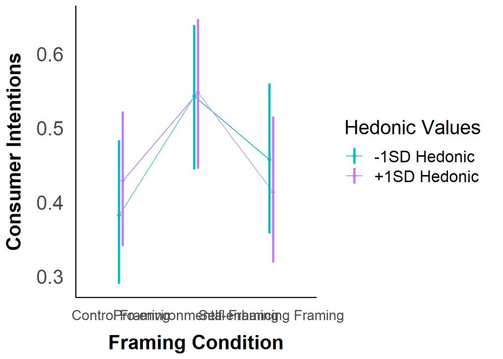

```r
sd_below <- mean(average_df$hedonic_center) - sd(average_df$hedonic_center)
sd_above <- mean(average_df$hedonic_center) + sd(average_df$hedonic_center)

at_list <- list(hedonic_center = c(sd_below, sd_above))

emmip(log_mice, hedonic_center ~ framing_condition, CIs = TRUE, type = "response", CIarg = list(lwd = 1.2, alpha = 1), xlab = "Framing Condition", ylab = "Consumer Intentions", at = at_list) +
  scale_x_discrete(breaks=c("control_framing","pro_env_framing", "self_enh_framing"), labels = c("Control Framing", "Pro-environmental Framing", "Self-enhancing Framing")) +
  theme_apa() +
  text_settings +
  scale_color_manual(name = "Hedonic Values", breaks = c(-0.790766915042502, 0.790766915042502), labels = c("-1SD Hedonic", "+1SD Hedonic"), values = c("#00BFC4","#C77CFF"))
```

#### Hed x Norm

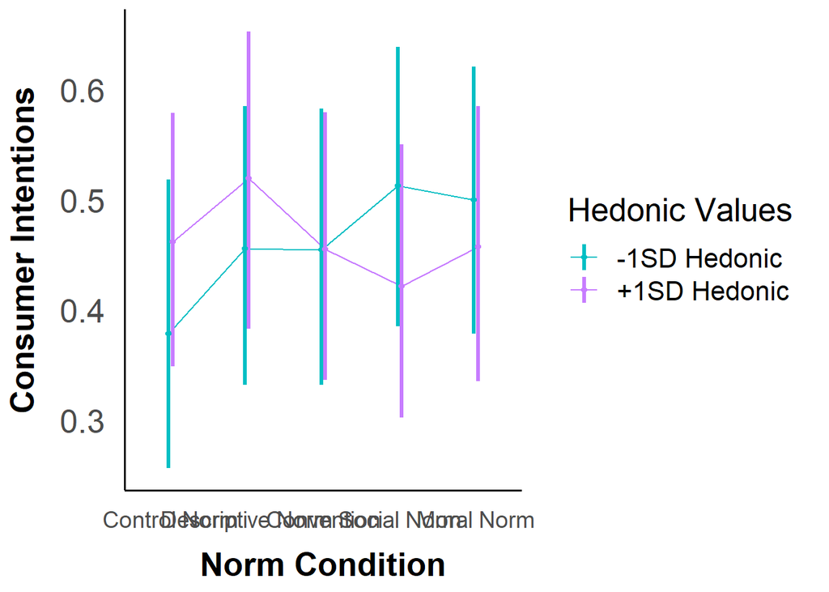

```r
emmip(log_mice, hedonic_center ~ norm_condition, CIs = TRUE, type = "response", CIarg = list(lwd = 1.2, alpha = 1), xlab = "Norm Condition", ylab = "Consumer Intentions", at = at_list) +
  scale_x_discrete(breaks=c("control_norm","descriptive_norm", "convention_norm", "social_norm", "moral_norm"), labels = c("Control Norm", "Descriptive Norm", "Convention", "Social Norm", "Moral Norm")) +
  theme_apa() +
  text_settings +
  scale_color_manual(name = "Hedonic Values", breaks = c(-0.790766915042502, 0.790766915042502), labels = c("-1SD Hedonic", "+1SD Hedonic"), values = c("#00BFC4","#C77CFF"))
```

#### Hed, Norm, Framing

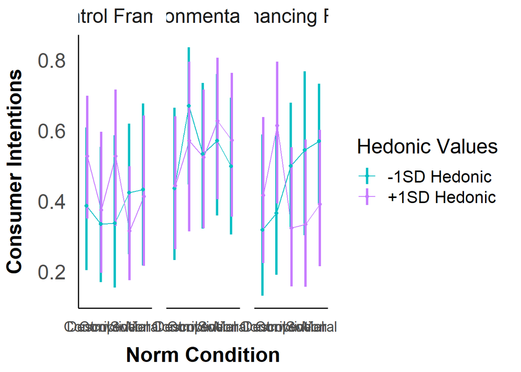

```r
emmip(log_mice, hedonic_center ~ norm_condition | framing_condition, type = "response", CIs = TRUE, CIarg = list(lwd = 1.2, alpha = 1), xlab = "Norm Condition", ylab = "Consumer Intentions", at = at_list) +
  scale_x_discrete(breaks=c("control_norm","descriptive_norm", "convention_norm", "social_norm", "moral_norm"), labels = c("Control", "Descriptive", "Convention", "Social", "Moral")) +
  facet_wrap(~framing_condition, labeller = labeller(framing_condition = frame_labs)) +
  theme_apa() +
  text_settings +
  scale_color_manual(name = "Hedonic Values", breaks = c(-0.790766915042502, 0.790766915042502), labels = c("-1SD Hedonic", "+1SD Hedonic"), values = c("#00BFC4","#C77CFF"))
```

## Planned Comparisons

### Storing low (-1SD) and high (+1SD) hedonic values

```r
sd_below <- mean(average_df$hedonic_center) - sd(average_df$hedonic_center)
sd_above <- mean(average_df$hedonic_center) + sd(average_df$hedonic_center)
```

### Calculate EM Means at low and high hed

```r
atlist <- list(hedonic_center = c(sd_below, sd_above))

combinations <- emmeans(log_mice, ~ norm_condition*hedonic_center*framing_condition, at=atlist, type = "response")

combinations %>% knitr::kable(digits = 2)
```

| norm_condition | hedonic_center | framing_condition | prob | SE | df | asymp.LCL | asymp.UCL |
| --- | --- | --- | --- | --- | --- | --- | --- |
| control_norm | -0.79 | control_framing | 0.39 | 0.11 | Inf | 0.20 | 0.61 |
| descriptive_norm | -0.79 | control_framing | 0.33 | 0.10 | Inf | 0.17 | 0.55 |
| convention_norm | -0.79 | control_framing | 0.34 | 0.12 | Inf | 0.15 | 0.59 |
| social_norm | -0.79 | control_framing | 0.42 | 0.10 | Inf | 0.25 | 0.62 |
| moral_norm | -0.79 | control_framing | 0.43 | 0.13 | Inf | 0.22 | 0.68 |
| control_norm | 0.79 | control_framing | 0.53 | 0.09 | Inf | 0.35 | 0.70 |
| descriptive_norm | 0.79 | control_framing | 0.37 | 0.11 | Inf | 0.20 | 0.60 |
| convention_norm | 0.79 | control_framing | 0.53 | 0.10 | Inf | 0.33 | 0.72 |
| social_norm | 0.79 | control_framing | 0.32 | 0.08 | Inf | 0.18 | 0.50 |
| moral_norm | 0.79 | control_framing | 0.41 | 0.12 | Inf | 0.22 | 0.64 |
| control_norm | -0.79 | pro_env_framing | 0.44 | 0.12 | Inf | 0.23 | 0.66 |
| descriptive_norm | -0.79 | pro_env_framing | 0.67 | 0.10 | Inf | 0.45 | 0.84 |
| convention_norm | -0.79 | pro_env_framing | 0.53 | 0.11 | Inf | 0.32 | 0.73 |
| social_norm | -0.79 | pro_env_framing | 0.57 | 0.11 | Inf | 0.36 | 0.76 |
| moral_norm | -0.79 | pro_env_framing | 0.50 | 0.10 | Inf | 0.30 | 0.69 |
| control_norm | 0.79 | pro_env_framing | 0.44 | 0.10 | Inf | 0.26 | 0.64 |
| descriptive_norm | 0.79 | pro_env_framing | 0.57 | 0.13 | Inf | 0.31 | 0.79 |
| convention_norm | 0.79 | pro_env_framing | 0.52 | 0.11 | Inf | 0.32 | 0.72 |
| social_norm | 0.79 | pro_env_framing | 0.63 | 0.11 | Inf | 0.41 | 0.81 |
| moral_norm | 0.79 | pro_env_framing | 0.57 | 0.11 | Inf | 0.36 | 0.76 |
| control_norm | -0.79 | self_enh_framing | 0.32 | 0.12 | Inf | 0.13 | 0.59 |
| descriptive_norm | -0.79 | self_enh_framing | 0.37 | 0.11 | Inf | 0.19 | 0.59 |
| convention_norm | -0.79 | self_enh_framing | 0.50 | 0.10 | Inf | 0.32 | 0.68 |
| social_norm | -0.79 | self_enh_framing | 0.54 | 0.13 | Inf | 0.30 | 0.77 |
| moral_norm | -0.79 | self_enh_framing | 0.57 | 0.09 | Inf | 0.39 | 0.73 |
| control_norm | 0.79 | self_enh_framing | 0.42 | 0.11 | Inf | 0.22 | 0.64 |
| descriptive_norm | 0.79 | self_enh_framing | 0.61 | 0.11 | Inf | 0.39 | 0.80 |
| convention_norm | 0.79 | self_enh_framing | 0.32 | 0.11 | Inf | 0.16 | 0.55 |
| social_norm | 0.79 | self_enh_framing | 0.33 | 0.11 | Inf | 0.16 | 0.57 |
| moral_norm | 0.79 | self_enh_framing | 0.39 | 0.10 | Inf | 0.21 | 0.60 |

### Custom contrasts

```r
cf_cn_low_hed <- c(1, rep(0,29)) # control framing
cf_dn_low_hed <- c(0,1,rep(0,28))
cf_conv_low_hed <- c(0,0,1,rep(0,27))
cf_sn_low_hed <- c(0,0,0,1,rep(0,26))
cf_mn_low_hed <- c(rep(0,4),1,(rep(0,25)))

cf_cn_hi_hed <- c(rep(0,5),1,(rep(0,24)))
cf_dn_hi_hed <- c(rep(0,6),1,(rep(0,23)))
cf_conv_hi_hed <- c(rep(0,7),1,(rep(0,22)))
cf_sn_hi_hed <- c(rep(0,8),1,(rep(0,21)))
cf_mn_hi_hed <- c(rep(0,9),1,(rep(0,20)))


pf_cn_low_hed <- c(rep(0,10),1,(rep(0,19))) # pro-environmental framing
pf_dn_low_hed <- c(rep(0,11),1,(rep(0,18)))
pf_conv_low_hed <- c(rep(0,12),1,(rep(0,17)))
pf_sn_low_hed <- c(rep(0,13),1,(rep(0,16)))
pf_mn_low_hed <- c(rep(0,14),1,(rep(0,15)))

pf_cn_hi_hed <- c(rep(0,15),1,(rep(0,14)))
pf_dn_hi_hed <- c(rep(0,16),1,(rep(0,13)))
pf_conv_hi_hed <- c(rep(0,17),1,(rep(0,12)))
pf_sn_hi_hed <- c(rep(0,18),1,(rep(0,11)))
pf_mn_hi_hed <- c(rep(0,19),1,(rep(0,10)))


sf_cn_low_hed <- c(rep(0,20),1,(rep(0,9))) # self-enhancing framing
sf_dn_low_hed <- c(rep(0,21),1,(rep(0,8)))
sf_conv_low_hed <- c(rep(0,22),1,(rep(0,7)))
sf_sn_low_hed <- c(rep(0,23),1,(rep(0,6)))
sf_mn_low_hed <- c(rep(0,24),1,(rep(0,5)))

sf_cn_hi_hed <- c(rep(0,25),1,(rep(0,4)))
sf_dn_hi_hed <- c(rep(0,26),1,(rep(0,3)))
sf_conv_hi_hed <- c(rep(0,27),1,(rep(0,2)))
sf_sn_hi_hed <- c(rep(0,28),1,(rep(0,1)))
sf_mn_hi_hed <- c(rep(0,29),1)
```

Effect of norm for people low vs high on hedonic values across framing conditions

#### Control framing

```r
controlframe_lowvshi_hed <- contrast(combinations,
                       method = list("CF/DN/LowHed - CF/CN/LowHed" = cf_dn_low_hed - cf_cn_low_hed,
                                     "CF/Conv/LowHed - CF/CN/LowHed" = cf_conv_low_hed - cf_cn_low_hed,
                                     "CF/SN/LowHed - CF/CN/LowHed" = cf_sn_low_hed - cf_cn_low_hed,
                                     "CF/MN/LowHed - CF/CN/LowHed" = cf_mn_low_hed - cf_cn_low_hed,
                                     "CF/DN/HiHed - CF/CN/HiHed" = cf_dn_hi_hed - cf_cn_hi_hed,
                                     "CF/Conv/HiHed - CF/CN/HiHed" = cf_conv_hi_hed - cf_cn_hi_hed,
                                     "CF/SN/HiHed - CF/CN/HiHed" = cf_sn_hi_hed - cf_cn_hi_hed,
                                     "CF/MN/HiHed - CF/CN/HiHed" = cf_mn_hi_hed - cf_cn_hi_hed),
                       adjust = "none")

controlframe_lowvshi_hed %>% knitr::kable(digits = c(NA,2,2,2,2,3))
```

| contrast | odds.ratio | SE | df | null | z.ratio | p.value |
| --- | --- | --- | --- | --- | --- | --- |
| CF/DN/LowHed / CF/CN/LowHed | 0.80 | 0.52 | Inf | 1 | -0.341 | NA |
| CF/Conv/LowHed / CF/CN/LowHed | 0.81 | 0.56 | Inf | 1 | -0.306 | NA |
| CF/SN/LowHed / CF/CN/LowHed | 1.17 | 0.71 | Inf | 1 | 0.256 | NA |
| CF/MN/LowHed / CF/CN/LowHed | 1.21 | 0.83 | Inf | 1 | 0.275 | NA |
| CF/DN/HiHed / CF/CN/HiHed | 0.54 | 0.32 | Inf | 1 | -1.047 | NA |
| CF/Conv/HiHed / CF/CN/HiHed | 1.00 | 0.56 | Inf | 1 | -0.004 | NA |
| CF/SN/HiHed / CF/CN/HiHed | 0.41 | 0.22 | Inf | 1 | -1.642 | NA |
| CF/MN/HiHed / CF/CN/HiHed | 0.63 | 0.38 | Inf | 1 | -0.762 | NA |

```r
# confidence intervals
controlframe_lowvshi_hed %>% confint() %>%
  knitr::kable(digits = 2)
```

| contrast | odds.ratio | SE | df | asymp.LCL | asymp.UCL |
| --- | --- | --- | --- | --- | --- |
| CF/DN/LowHed / CF/CN/LowHed | 0.80 | 0.52 | Inf | 0.22 | 2.86 |
| CF/Conv/LowHed / CF/CN/LowHed | 0.81 | 0.56 | Inf | 0.21 | 3.16 |
| CF/SN/LowHed / CF/CN/LowHed | 1.17 | 0.71 | Inf | 0.35 | 3.85 |
| CF/MN/LowHed / CF/CN/LowHed | 1.21 | 0.83 | Inf | 0.31 | 4.66 |
| CF/DN/HiHed / CF/CN/HiHed | 0.54 | 0.32 | Inf | 0.17 | 1.72 |
| CF/Conv/HiHed / CF/CN/HiHed | 1.00 | 0.56 | Inf | 0.33 | 2.99 |
| CF/SN/HiHed / CF/CN/HiHed | 0.41 | 0.22 | Inf | 0.14 | 1.19 |
| CF/MN/HiHed / CF/CN/HiHed | 0.63 | 0.38 | Inf | 0.19 | 2.07 |

Planned Comparisons

Custom contrasts

```r
controlframe_lowvshi_hed
```

```
##  contrast                      odds.ratio    SE  df null z.ratio p.value
##  CF/DN/LowHed / CF/CN/LowHed        0.801 0.521 Inf    1  -0.341  0.7328
##  CF/Conv/LowHed / CF/CN/LowHed      0.808 0.562 Inf    1  -0.306  0.7593
##  CF/SN/LowHed / CF/CN/LowHed        1.168 0.710 Inf    1   0.256  0.7983
##  CF/MN/LowHed / CF/CN/LowHed        1.208 0.832 Inf    1   0.275  0.7833
##  CF/DN/HiHed / CF/CN/HiHed          0.537 0.319 Inf    1  -1.047  0.2949
##  CF/Conv/HiHed / CF/CN/HiHed        0.998 0.558 Inf    1  -0.004  0.9965
##  CF/SN/HiHed / CF/CN/HiHed          0.413 0.222 Inf    1  -1.642  0.1005
##  CF/MN/HiHed / CF/CN/HiHed          0.630 0.382 Inf    1  -0.762  0.4460
##
## Results are averaged over the levels of: Gender
## Tests are performed on the log odds ratio scale
```

```r
dn_vs_c_LowHed <- c(1,rep(0,7))
conv_vs_c_LowHed <- c(0,1,rep(0,6))
sn_vs_c_LowHed <- c(0,0,1,rep(0,5))
mn_vs_c_LowHed <- c(0,0,0,1,rep(0,4))

dn_vs_c_HiHed <- c(rep(0,4),1,rep(0,3))
conv_vs_c_HiHed <- c(rep(0,5),1,rep(0,2))
sn_vs_c_HiHed <- c(rep(0,6),1,rep(0,1))
mn_vs_c_HiHed <- c(rep(0,7),1)
```

```r
compare_hed <- contrast(controlframe_lowvshi_hed, method = list("Effect of DN (Low - High hed)" = dn_vs_c_LowHed - dn_vs_c_HiHed,
                                                                "Effect of Conv (Low - High hed)" = conv_vs_c_LowHed - conv_vs_c_HiHed,
                                                                "Effect of SN (Low - High hed)" = sn_vs_c_LowHed - sn_vs_c_HiHed,
                                                                "Effect of MN (Low - High hed)" = mn_vs_c_LowHed - mn_vs_c_HiHed), adjust = "none")

compare_hed %>% knitr::kable(digits = c(NA,2,2,2,2,3))
```

| contrast | odds.ratio | SE | df | null | z.ratio | p.value |
| --- | --- | --- | --- | --- | --- | --- |
| Effect of DN (Low / High hed) | 1.49 | 1.47 | Inf | 1 | 0.404 | NA |
| Effect of Conv (Low / High hed) | 0.81 | 0.80 | Inf | 1 | -0.212 | NA |
| Effect of SN (Low / High hed) | 2.83 | 2.57 | Inf | 1 | 1.146 | NA |
| Effect of MN (Low / High hed) | 1.92 | 1.95 | Inf | 1 | 0.641 | NA |

```r
# confidence intervals
compare_hed %>% confint() %>%
  knitr::kable(digits = 2)
```

| contrast | odds.ratio | SE | df | asymp.LCL | asymp.UCL |
| --- | --- | --- | --- | --- | --- |
| Effect of DN (Low / High hed) | 1.49 | 1.47 | Inf | 0.22 | 10.32 |
| Effect of Conv (Low / High hed) | 0.81 | 0.80 | Inf | 0.12 | 5.68 |
| Effect of SN (Low / High hed) | 2.83 | 2.57 | Inf | 0.48 | 16.73 |
| Effect of MN (Low / High hed) | 1.92 | 1.95 | Inf | 0.26 | 14.05 |

#### Pro-environmental framing

```r
proenvframe_lowvshi_hed <- contrast(combinations,
                       method = list("PF/DN/LowHed - PF/CN/LowHed" = pf_dn_low_hed - pf_cn_low_hed,
                                     "PF/Conv/LowHed - PF/CN/LowHed" = pf_conv_low_hed - pf_cn_low_hed,
                                     "PF/SN/LowHed - PF/CN/LowHed" = pf_sn_low_hed - pf_cn_low_hed,
                                     "PF/MN/LowHed - PF/CN/LowHed" = pf_mn_low_hed - pf_cn_low_hed,
                                     "PF/DN/HiHed - PF/CN/HiHed" = pf_dn_hi_hed - pf_cn_hi_hed,
                                     "PF/Conv/HiHed - PF/CN/HiHed" = pf_conv_hi_hed - pf_cn_hi_hed,
                                     "PF/SN/HiHed - PF/CN/HiHed" = pf_sn_hi_hed - pf_cn_hi_hed,
                                     "PF/MN/HiHed - PF/CN/HiHed" = pf_mn_hi_hed - pf_cn_hi_hed),
                       adjust = "none")

proenvframe_lowvshi_hed %>% knitr::kable(digits = c(NA,2,2,2,2,3))
```

| contrast | odds.ratio | SE | df | null | z.ratio | p.value |
| --- | --- | --- | --- | --- | --- | --- |
| PF/DN/LowHed / PF/CN/LowHed | 2.62 | 1.76 | Inf | 1 | 1.436 | NA |
| PF/Conv/LowHed / PF/CN/LowHed | 1.48 | 0.97 | Inf | 1 | 0.597 | NA |
| PF/SN/LowHed / PF/CN/LowHed | 1.72 | 1.12 | Inf | 1 | 0.834 | NA |
| PF/MN/LowHed / PF/CN/LowHed | 1.28 | 0.81 | Inf | 1 | 0.397 | NA |
| PF/DN/HiHed / PF/CN/HiHed | 1.67 | 1.13 | Inf | 1 | 0.757 | NA |
| PF/Conv/HiHed / PF/CN/HiHed | 1.38 | 0.81 | Inf | 1 | 0.542 | NA |
| PF/SN/HiHed / PF/CN/HiHed | 2.11 | 1.29 | Inf | 1 | 1.219 | NA |
| PF/MN/HiHed / PF/CN/HiHed | 1.67 | 1.01 | Inf | 1 | 0.853 | NA |

```r
# confidence intervals
proenvframe_lowvshi_hed %>% confint() %>%
  knitr::kable(digits = 2)
```

| contrast | odds.ratio | SE | df | asymp.LCL | asymp.UCL |
| --- | --- | --- | --- | --- | --- |
| PF/DN/LowHed / PF/CN/LowHed | 2.62 | 1.76 | Inf | 0.70 | 9.74 |
| PF/Conv/LowHed / PF/CN/LowHed | 1.48 | 0.97 | Inf | 0.41 | 5.37 |
| PF/SN/LowHed / PF/CN/LowHed | 1.72 | 1.12 | Inf | 0.48 | 6.15 |
| PF/MN/LowHed / PF/CN/LowHed | 1.28 | 0.81 | Inf | 0.37 | 4.42 |
| PF/DN/HiHed / PF/CN/HiHed | 1.67 | 1.13 | Inf | 0.44 | 6.29 |
| PF/Conv/HiHed / PF/CN/HiHed | 1.38 | 0.81 | Inf | 0.43 | 4.36 |
| PF/SN/HiHed / PF/CN/HiHed | 2.11 | 1.29 | Inf | 0.63 | 7.02 |
| PF/MN/HiHed / PF/CN/HiHed | 1.67 | 1.01 | Inf | 0.51 | 5.47 |

Planned Comparisons

Custom contrasts

```r
proenvframe_lowvshi_hed
```

```
##  contrast                      odds.ratio    SE  df null z.ratio p.value
##  PF/DN/LowHed / PF/CN/LowHed         2.62 1.755 Inf    1   1.436  0.1511
##  PF/Conv/LowHed / PF/CN/LowHed       1.48 0.973 Inf    1   0.597  0.5506
##  PF/SN/LowHed / PF/CN/LowHed         1.72 1.119 Inf    1   0.834  0.4041
##  PF/MN/LowHed / PF/CN/LowHed         1.28 0.810 Inf    1   0.397  0.6916
##  PF/DN/HiHed / PF/CN/HiHed           1.67 1.129 Inf    1   0.757  0.4493
##  PF/Conv/HiHed / PF/CN/HiHed         1.38 0.810 Inf    1   0.542  0.5879
##  PF/SN/HiHed / PF/CN/HiHed           2.11 1.294 Inf    1   1.219  0.2228
##  PF/MN/HiHed / PF/CN/HiHed           1.67 1.011 Inf    1   0.853  0.3934
##
## Results are averaged over the levels of: Gender
## Tests are performed on the log odds ratio scale
```

```r
dn_vs_c_LowHed <- c(1,rep(0,7))
conv_vs_c_LowHed <- c(0,1,rep(0,6))
sn_vs_c_LowHed <- c(0,0,1,rep(0,5))
mn_vs_c_LowHed <- c(0,0,0,1,rep(0,4))

dn_vs_c_HiHed <- c(rep(0,4),1,rep(0,3))
conv_vs_c_HiHed <- c(rep(0,5),1,rep(0,2))
sn_vs_c_HiHed <- c(rep(0,6),1,rep(0,1))
mn_vs_c_HiHed <- c(rep(0,7),1)
```

```r
compare_hed <- contrast(proenvframe_lowvshi_hed, method = list("Effect of DN (Low - High hed)" = dn_vs_c_LowHed - dn_vs_c_HiHed,
                                                                "Effect of Conv (Low - High hed)" = conv_vs_c_LowHed - conv_vs_c_HiHed,
                                                                "Effect of SN (Low - High hed)" = sn_vs_c_LowHed - sn_vs_c_HiHed,
                                                                "Effect of MN (Low - High hed)" = mn_vs_c_LowHed - mn_vs_c_HiHed), adjust = "none")

compare_hed %>% knitr::kable(digits = c(NA,2,2,2,2,3))
```

| contrast | odds.ratio | SE | df | null | z.ratio | p.value |
| --- | --- | --- | --- | --- | --- | --- |
| Effect of DN (Low / High hed) | 1.57 | 1.68 | Inf | 1 | 0.422 | NA |
| Effect of Conv (Low / High hed) | 1.08 | 1.09 | Inf | 1 | 0.072 | NA |
| Effect of SN (Low / High hed) | 0.81 | 0.81 | Inf | 1 | -0.207 | NA |
| Effect of MN (Low / High hed) | 0.77 | 0.75 | Inf | 1 | -0.270 | NA |

```r
# confidence intervals
compare_hed %>% confint() %>%
  knitr::kable(digits = 2)
```

| contrast | odds.ratio | SE | df | asymp.LCL | asymp.UCL |
| --- | --- | --- | --- | --- | --- |
| Effect of DN (Low / High hed) | 1.57 | 1.68 | Inf | 0.19 | 12.73 |
| Effect of Conv (Low / High hed) | 1.08 | 1.09 | Inf | 0.15 | 7.88 |
| Effect of SN (Low / High hed) | 0.81 | 0.81 | Inf | 0.12 | 5.68 |
| Effect of MN (Low / High hed) | 0.77 | 0.75 | Inf | 0.11 | 5.27 |

#### Self-enhancing framing

```r
selfenhframe_lowvshi_hed <- contrast(combinations,
                       method = list("SF/DN/LowHed - SF/CN/LowHed" = sf_dn_low_hed - sf_cn_low_hed,
                                     "SF/Conv/LowHed - SF/CN/LowHed" = sf_conv_low_hed - sf_cn_low_hed,
                                     "SF/SN/LowHed - SF/CN/LowHed" = sf_sn_low_hed - sf_cn_low_hed,
                                     "SF/MN/LowHed - SF/CN/LowHed" = sf_mn_low_hed - sf_cn_low_hed,
                                     "SF/DN/HiHed - SF/CN/HiHed" = sf_dn_hi_hed - sf_cn_hi_hed,
                                     "SF/Conv/HiHed - SF/CN/HiHed" = sf_conv_hi_hed - sf_cn_hi_hed,
                                     "SF/SN/HiHed - SF/CN/HiHed" = sf_sn_hi_hed - sf_cn_hi_hed,
                                     "SF/MN/HiHed - SF/CN/HiHed" = sf_mn_hi_hed - sf_cn_hi_hed),
                       adjust = "none")

selfenhframe_lowvshi_hed %>% knitr::kable(digits = c(NA,2,2,2,2,3))
```

| contrast | odds.ratio | SE | df | null | z.ratio | p.value |
| --- | --- | --- | --- | --- | --- | --- |
| SF/DN/LowHed / SF/CN/LowHed | 1.24 | 0.90 | Inf | 1 | 0.291 | NA |
| SF/Conv/LowHed / SF/CN/LowHed | 2.14 | 1.46 | Inf | 1 | 1.112 | NA |
| SF/SN/LowHed / SF/CN/LowHed | 2.56 | 1.97 | Inf | 1 | 1.224 | NA |
| SF/MN/LowHed / SF/CN/LowHed | 2.84 | 1.94 | Inf | 1 | 1.531 | NA |
| SF/DN/HiHed / SF/CN/HiHed | 2.22 | 1.44 | Inf | 1 | 1.227 | NA |
| SF/Conv/HiHed / SF/CN/HiHed | 0.67 | 0.45 | Inf | 1 | -0.596 | NA |
| SF/SN/HiHed / SF/CN/HiHed | 0.70 | 0.48 | Inf | 1 | -0.518 | NA |
| SF/MN/HiHed / SF/CN/HiHed | 0.90 | 0.57 | Inf | 1 | -0.168 | NA |

```r
# confidence intervals
selfenhframe_lowvshi_hed %>% confint() %>%
  knitr::kable(digits = 2)
```

| contrast | odds.ratio | SE | df | asymp.LCL | asymp.UCL |
| --- | --- | --- | --- | --- | --- |
| SF/DN/LowHed / SF/CN/LowHed | 1.24 | 0.90 | Inf | 0.30 | 5.17 |
| SF/Conv/LowHed / SF/CN/LowHed | 2.14 | 1.46 | Inf | 0.56 | 8.18 |
| SF/SN/LowHed / SF/CN/LowHed | 2.56 | 1.97 | Inf | 0.57 | 11.59 |
| SF/MN/LowHed / SF/CN/LowHed | 2.84 | 1.94 | Inf | 0.75 | 10.81 |
| SF/DN/HiHed / SF/CN/HiHed | 2.22 | 1.44 | Inf | 0.62 | 7.95 |
| SF/Conv/HiHed / SF/CN/HiHed | 0.67 | 0.45 | Inf | 0.18 | 2.49 |
| SF/SN/HiHed / SF/CN/HiHed | 0.70 | 0.48 | Inf | 0.18 | 2.68 |
| SF/MN/HiHed / SF/CN/HiHed | 0.90 | 0.57 | Inf | 0.26 | 3.12 |

Planned Comparisons

Custom contrasts

```r
selfenhframe_lowvshi_hed
```

```
##  contrast                      odds.ratio    SE  df null z.ratio p.value
##  SF/DN/LowHed / SF/CN/LowHed        1.236 0.903 Inf    1   0.291  0.7714
##  SF/Conv/LowHed / SF/CN/LowHed      2.140 1.464 Inf    1   1.112  0.2662
##  SF/SN/LowHed / SF/CN/LowHed        2.565 1.974 Inf    1   1.224  0.2209
##  SF/MN/LowHed / SF/CN/LowHed        2.841 1.938 Inf    1   1.531  0.1259
##  SF/DN/HiHed / SF/CN/HiHed          2.221 1.445 Inf    1   1.227  0.2197
##  SF/Conv/HiHed / SF/CN/HiHed        0.672 0.448 Inf    1  -0.596  0.5514
##  SF/SN/HiHed / SF/CN/HiHed          0.702 0.480 Inf    1  -0.518  0.6045
##  SF/MN/HiHed / SF/CN/HiHed          0.899 0.571 Inf    1  -0.168  0.8669
##
## Results are averaged over the levels of: Gender
## Tests are performed on the log odds ratio scale
```

```r
dn_vs_c_LowHed <- c(1,rep(0,7))
conv_vs_c_LowHed <- c(0,1,rep(0,6))
sn_vs_c_LowHed <- c(0,0,1,rep(0,5))
mn_vs_c_LowHed <- c(0,0,0,1,rep(0,4))

dn_vs_c_HiHed <- c(rep(0,4),1,rep(0,3))
conv_vs_c_HiHed <- c(rep(0,5),1,rep(0,2))
sn_vs_c_HiHed <- c(rep(0,6),1,rep(0,1))
mn_vs_c_HiHed <- c(rep(0,7),1)
```

```r
compare_hed <- contrast(selfenhframe_lowvshi_hed, method = list("Effect of DN (Low - High hed)" = dn_vs_c_LowHed - dn_vs_c_HiHed,
                                                                "Effect of Conv (Low - High hed)" = conv_vs_c_LowHed - conv_vs_c_HiHed,
                                                                "Effect of SN (Low - High hed)" = sn_vs_c_LowHed - sn_vs_c_HiHed,
                                                                "Effect of MN (Low - High hed)" = mn_vs_c_LowHed - mn_vs_c_HiHed), adjust = "none")

compare_hed %>% knitr::kable(digits = c(NA,2,2,2,2,3))
```

| contrast | odds.ratio | SE | df | null | z.ratio | p.value |
| --- | --- | --- | --- | --- | --- | --- |
| Effect of DN (Low / High hed) | 0.56 | 0.65 | Inf | 1 | -0.505 | NA |
| Effect of Conv (Low / High hed) | 3.18 | 3.45 | Inf | 1 | 1.068 | NA |
| Effect of SN (Low / High hed) | 3.66 | 4.44 | Inf | 1 | 1.067 | NA |
| Effect of MN (Low / High hed) | 3.16 | 3.35 | Inf | 1 | 1.086 | NA |

```r
# confidence intervals
compare_hed %>% confint() %>%
  knitr::kable(digits = 2)
```

| contrast | odds.ratio | SE | df | asymp.LCL | asymp.UCL |
| --- | --- | --- | --- | --- | --- |
| Effect of DN (Low / High hed) | 0.56 | 0.65 | Inf | 0.06 | 5.41 |
| Effect of Conv (Low / High hed) | 3.18 | 3.45 | Inf | 0.38 | 26.68 |
| Effect of SN (Low / High hed) | 3.66 | 4.44 | Inf | 0.34 | 39.58 |
| Effect of MN (Low / High hed) | 3.16 | 3.35 | Inf | 0.40 | 25.18 |